# MEKONG TECHNOLOGY

# CỘNG HÒA XÃ HỘI CHỦ NGHĨA VIỆT NAM

## Độc lập — Tự do — Hạnh phúc

# MEKONG TECHNOLOGY

## TỔ HỢP CÔNG NGHỆ CAO ĐA NGÀNH

### Nghiên cứu, Phát triển, Sản xuất Thiết bị IoT/Robot, Hạ tầng Chế tạo Cơ khí Siêu Chính xác và Điện toán Đám mây AI Phục vụ Hệ sinh thái Chuyển đổi số và Công nghiệp Bán dẫn

**DỰ ÁN ỨNG DỤNG CÔNG NGHỆ CAO ĐỂ SẢN XUẤT SẢN PHẨM CÔNG NGHỆ CAO VÀ CUNG ỨNG DỊCH VỤ CÔNG NGHỆ CAO**

*Theo Mẫu số 1.4 — Phụ lục I, Nghị định 31/2021/NĐ-CP*

**PHƯƠNG ÁN:** 1 ha / 5 Giai đoạn / 15 năm Đầu tư  
**NGÀY HOÀN THÀNH:** Tháng 03/2026

| Thông tin | Nội dung |
| --- | --- |
| **Chủ đầu tư** | Công ty TNHH Mekong Technology |
| **Tổng Giám đốc** | Ông Phạm Xuân Quốc |
| **Địa điểm** | Lô E2-03, Đường D1, Khu Công nghệ cao TP.HCM |
| **Diện tích đất** | 1 ha (10.000 m²), 1 tòa nhà 3 tầng — GFA 21.000 m² |
| **Tổng vốn đầu tư** | 32.000.000 USD |
| **Vốn chủ sở hữu** | 24.000.000 USD (bao gồm vốn vận hành) |
| **Thời hạn** | 50 năm (01/2025 — 12/2075) |
| **Lĩnh vực** | Vi điện tử — CNTT — Viễn thông; Cơ khí chính xác — Tự động hóa |

**NƠI NỘP:**  
Ban Quản lý Khu Công nghệ cao Thành phố Hồ Chí Minh (SHTP)  
Lô T2-4, Đường D1, Phường Tân Phú, TP Thủ Đức, TP.HCM

# MỤC LỤC TỔNG THỂ

## PHẦN MỞ ĐẦU

- Thông tin Dự án
- Tóm tắt Điều hành (Executive Summary)
- Cơ sở Pháp lý của Đề án

## PHẦN I: BỐI CẢNH VÀ THỊ TRƯỜNG

- 1.1. Bối cảnh Kinh tế — Công nghệ Toàn cầu
- 1.2. Bối cảnh Việt Nam và Vai trò KCNC TP.HCM
- 1.3. Thị trường IoT và Robot Tự hành (B.U gốc)
- 1.4. Thị trường Gia công Cơ khí Chính xác (B.U mới)
- 1.5. Thị trường Trung tâm Dữ liệu và Điện toán AI (B.U mới)
- 1.6. Định vị Cạnh tranh Tổng thể

## PHẦN II: SẢN PHẨM VÀ CÔNG NGHỆ

- 2.1. Tổng quan 3 Trụ cột Sản phẩm
- 2.2. Trụ cột 1 — Sản xuất Thiết bị IoT Gateway và Robot AMR/AGV/OHT
- 2.3. Trụ cột 2 — Chế tạo Cơ khí Siêu Chính xác (MPMC)
- 2.4. Trụ cột 3 — Hạ tầng Điện toán Đám mây AI (MACC)
- 2.5. Hệ sinh thái Tích hợp 3 Trụ cột
- 2.6. Lộ trình Trưởng thành Công nghệ (TRL)
- 2.7. Hoạt động Nghiên cứu và Phát triển (R&D)

## PHẦN III: MÔ HÌNH KINH DOANH

- 3.1. Tổng quan Mô hình Doanh thu 3 Trụ cột
- 3.2. Khách hàng Mục tiêu và Chiến lược Tiếp cận
- 3.3. Chiến lược Phát triển Ba giai đoạn
- 3.4. Kênh Phân phối và Đối tác Chiến lược

## PHẦN V: TÀI CHÍNH VÀ ĐẦU TƯ

- 5.1. Tổng quan Cấu trúc Vốn
- 5.2. Doanh thu Dự kiến 15 năm
- 5.3. Chi phí Hoạt động (OPEX)
- 5.4. Báo cáo Lãi lỗ Dự kiến (Pro-forma P&L)
- 5.5. Dòng tiền Dự kiến (Projected Cash Flow)
- 5.6. Phân tích Hiệu quả Đầu tư
- 5.7. Giá trị Chiến lược (Strategic Value Assessment)
- 5.8. Phân tích Rủi ro Tài chính
- 5.9. Kế hoạch Giải ngân Vốn
- 5.10. Mô hình Vốn lưu động
- 5.11. Lịch trả Nợ Chi tiết
- 5.12. Bảng Cân đối Kế toán Dự kiến
- 5.13. Kế hoạch Thuế và Ưu đãi Chi tiết
- 5.14. Định giá Dự án (Valuation)
- 5.15. Phân tích Lợi nhuận Nhà đầu tư
- 5.16. Phân tích Điểm Hòa vốn theo BU
- 5.17. Tổng hợp Các Chỉ số Tài chính (Financial Dashboard)

## PHẦN VI: PHÁP LÝ VÀ MÔI TRƯỜNG

- 6.1. Khung Pháp lý Áp dụng
- 6.2. Phân tích Pháp lý 3 Trụ cột
- 6.3. Chiến lược Định vị Pháp lý
- 6.4. Lộ trình Thủ tục Hành chính 18 Giấy phép
- 6.5. Đánh giá Tác động Môi trường (ĐTM)
- 6.6. Cam kết Bảo vệ Môi trường

## PHẦN VII: NHÂN SỰ VÀ TỔ CHỨC

- 7.1. Sơ đồ Tổ chức 3 Trụ cột
- 7.2. Đội ngũ Quản lý Hiện tại
- 7.3. Vị trí Then chốt Cần Tuyển dụng
- 7.4. Kế hoạch Tuyển dụng và Đào tạo

## PHẦN VIII: KẾ HOẠCH TRIỂN KHAI

- 8.1. Phân kỳ Đầu tư
- 8.2. Lộ trình Triển khai (Timeline)
- 8.3. Các mốc Quan trọng (Milestones)
- 8.4. Phân tích Rủi ro và Biện pháp Giảm thiểu

## PHẦN IX: KẾT LUẬN VÀ KIẾN NGHỊ

- 9.1. Tổng kết Giá trị Dự án
- 9.2. Cam kết của Nhà đầu tư
- 9.3. Kiến nghị

## PHỤ LỤC

- Phụ lục A: Chi tiết CAPEX theo Hạng mục và Giai đoạn
- Phụ lục B: Danh mục Máy móc Thiết bị
- Phụ lục C: Mẫu Văn bản Pháp lý
- Phụ lục D: Bảng Viện dẫn Pháp lý Tổng hợp
- Phụ lục E: Từ điển Thuật ngữ
- Phụ lục F: Phân tích Tài chính Chi tiết

# THÔNG TIN DỰ ÁN

## Tổng quan Dự án

| Mục | Nội dung |
| --- | --- |
| **Tên dự án** | Mekong Technology — Tổ hợp Nghiên cứu, Phát triển, Sản xuất Thiết bị IoT/Robot và Hạ tầng Công nghệ cao Tích hợp (Chế tạo Cơ khí Siêu Chính xác & Điện toán Đám mây AI) Phục vụ Hệ sinh thái Chuyển đổi … |
| **Tên tiếng Anh** | Mekong Technology — Integrated High-Tech Complex for IoT/Robot Manufacturing, Ultra-Precision Machining and AI Cloud Computing |
| **Tên viết tắt** | Tổ hợp CNC Mekong |
| **Loại dự án** | Dự án ứng dụng công nghệ cao để sản xuất sản phẩm công nghệ cao và cung ứng dịch vụ công nghệ cao |
| **Chủ đầu tư** | Công ty TNHH Mekong Technology |
| **Mã số thuế** | [Chờ cập nhật] |
| **Đại diện pháp luật** | Ông Phạm Xuân Quốc — Tổng Giám đốc |

## Thông tin Địa điểm

| Mục | Nội dung |
| --- | --- |
| **Địa chỉ** | Lô E2-03, Đường D1, Khu Công nghệ cao TP.HCM |
| **Phường/Quận** | Phường Tân Phú, Thành phố Thủ Đức, TP.HCM |
| **Diện tích lô đất** | 1 ha (10.000 m²) |
| **Mật độ xây dựng** | 70% (7.000 m² footprint), chiều cao tối đa 14 m |
| **Tòa nhà** | 1 tòa nhà 3 tầng (6m + 4m + 4m = 14m), GFA 21.000 m² |
| **Tầng 1 (6m)** | Datacenter 3.000 m² + CNC Workshop 800 m² + M&E/Kho 3.200 m² |
| **Tầng 2 (4m)** | IoT/SMT 2.500 m² + Clean Room 1.000 m² + Lắp ráp/QC 2.500 m² + Hành lang 1.000 m² |
| **Tầng 3 (4m)** | Văn phòng 2.500 m² + R&D Lab 1.500 m² + Đào tạo/Căn tin/Hội nghị 2.000 m² + Phụ trợ 1.000 m² |
| **Diện tích sân bãi** | 3.000 m² (bãi xe, cây xanh, đường nội bộ, trạm biến áp, lane PCCC) |
| **Cơ quan quản lý** | Ban Quản lý Khu Công nghệ cao TP.HCM (SHTP) |

## Thông tin Đầu tư

| Mục | Giá trị | Ghi chú |
| --- | --- | --- |
| **Tổng vốn đầu tư** | 32.000.000 USD | CAPEX toàn dự án [C] |
| **Vốn chủ sở hữu (Phase 0-3)** | 24.000.000 USD | 75% equity, tự chủ toàn bộ giai đoạn xây dựng + lắp đặt [C] |
| **Vốn vay (từ Y6, khi DC có doanh thu)** | 8.000.000 USD | Chỉ giải ngân khi có revenue proof từ Datacenter [C] |
| **Tổng vốn CSH cam kết** | 24.000.000 USD | Bao gồm CAPEX + working capital + bù lỗ ramp-up [C] |
| **Trợ cấp/Ưu đãi** | ~2.000.000 USD | R&D Grant + Tax incentive (ước tính) [A] |
| **Thời hạn hoạt động** | 50 năm | 01/2025 — 12/2075 |

## Phạm vi Lĩnh vực

| Lĩnh vực KCNC | Trụ cột | Nội dung hoạt động |
| --- | --- | --- |
| Vi điện tử — CNTT — Viễn thông | Trụ cột 1 (IoT/Robot) | Nghiên cứu, sản xuất IoT Gateway, Robot AMR/AGV, OHT |
| Vi điện tử — CNTT — Viễn thông | Trụ cột 3 (MACC) | Hạ tầng điện toán đám mây, AI Computing, IoT Cloud |
| Cơ khí chính xác — Tự động hóa | Trụ cột 1 (IoT/Robot) | Lắp ráp Robot, hệ thống tự động hóa |
| Cơ khí chính xác — Tự động hóa | Trụ cột 2 (MPMC) | Chế tạo linh kiện siêu chính xác (dung sai ≤ 5 micromet) |

## Phân kỳ Đầu tư

[output not shown]

> **Nguyên tắc tài chính:** Y0–Y5 tự chủ 100% vốn CSH (24,00M USD). Vay ngân hàng chỉ giải ngân từ Y6 khi Datacenter đã có doanh thu chứng minh (revenue proof). Sổ đỏ hoàn thành Y3 nhờ tiến độ xây dựng tập trung.

## Chỉ số Tài chính Tổng hợp

[output not shown]

> **Ghi chú quan trọng:** Phương án 32M tập trung triển khai nhanh trong 8 năm (thay vì dàn trải 13 năm), ưu tiên Datacenter (50% vốn) và IoT, CNC quy mô tinh gọn (6 máy, ISO 9001). NPV(50Y) dương nhờ doanh thu bắt đầu từ Y4, IRR(50Y) = 14,5% > WACC 12% → dự án có giá trị.

> **Quy ước nhãn dữ liệu:** [C] = Calculated (tính toán từ mô hình tài chính, ghi rõ công thức); [B] = Benchmarked (tham chiếu thị trường, ghi rõ nguồn); [A] = Assumed (giả định, ghi rõ lý do).

## Bảng Sản phẩm Tổng hợp (Mục tiêu Công suất Thiết kế — Ổn định từ Y13)

| TT | Sản phẩm / Dịch vụ | Trụ cột | Thông số kỹ thuật | Quy mô/năm | Doanh thu ổn định (M USD/năm) | VA (%) | Cơ sở PL (QĐ 38/2020) |
| --- | --- | --- | --- | --- | --- | --- | --- |
| 1 | IoT Gateway MK-200/300 | 1 | ARM Cortex-A78, 8GB RAM, AI Edge, 5G-ready | 5.000 thiết bị | 10,00 | 35% | Phụ lục II, Mục 1.1 |
| 2 | Robot AMR-500/1000 | 1 | LiDAR 3D, AI SLAM, tải 500-1.000 kg | 200 bộ | 5,00 | 40% | Phụ lục II, Mục 2.1 |
| 3 | Robot AGV-500/1000 | 1 | Vision-based, tải 500-1.000 kg | 100 bộ | 4,00 | 35% | Phụ lục II, Mục 2.1 |
| 4 | Robot OHT-100 | 1 | Dual rail, 100 kg, 4 trục | 50 bộ | 2,50 | 30% | Phụ lục II, Mục 2.2 |
| 5 | Khung Robot AMR/AGV (nội bộ + xuất khẩu) | 2 | Nhôm 6061-T6, dung sai ≤ 5 micromet, ISO 9001:2015 | 1.500 bộ khung | 1,20 | 40% | Phụ lục I, Mục 2 |
| 6 | Linh kiện chính xác (encoder bracket, motor mount, khớp xoay) | 2 | Thép/Nhôm, dung sai ≤ 5 micromet, ISO 9001:2015 | 1.000 chi tiết | 0,80 | 35% | Phụ lục I, Mục 2 |
| 7 | Jig/Fixture cho SMT + chi tiết gia công FDI | 2 | Al 6061/SUS304, gia công 5 trục, ISO 9001:2015 | 500 bộ | 0,50 | 30% | Phụ lục I, Mục 2 |
| 8 | Nền tảng AI/HPC Computing | 3 | NVIDIA DGX H100, GPU-as-a-Service | 50 Rack | 5,00 | 60% | Phụ lục I, Mục 1.3 |
| 9 | Hạ tầng lưu trữ Tier III | 3 | Uptime 99,982%, Colocation | 50 Rack | 1,20 | 55% | Phụ lục I, Mục 1.2 |
| 10 | MekongOS IoT Cloud (SaaS) | 3 | Nền tảng quản lý IoT, MQTT/OPC UA | 2.000 thuê bao | 3,00 | 70% | Phụ lục II, Mục 1.2 |
| 11 | MK-EIO I/O Modules (5 loai) | 1 | DI16/DO16/AI8/AO4/UI8, RS485 Modbus+BACnet, DIN rail | 8.000 module | 0,80 | 50% | Phu luc II, Muc 1.1 |
| 12 | MK-DDC Controllers (DDC-24/64) | 1 | 24/64 diem, BACnet native, IEC 61131-3, platform MK-200 | 2.000 bo | 1,00 | 55% | Phu luc II, Muc 1.1 |
| 13 | MK-GW Gateway chuyen dung (4 loai) | 1 | BACnet/Modbus/KNX/DALI gateway | 3.000 bo | 0,60 | 45% | Phu luc II, Muc 1.1 |
| 14 | MekongBMS License + SaaS | 1 | Phan mem BMS web-based, tieng Viet 100%, per-point | 500 site | 1,50 | 80% | Phu luc II, Muc 1.2 |
| 15 | BMS/SCADA Service & Maintenance | 1 | Bao tri, nang cap, ho tro ky thuat, commissioning | Recurring | 0,60 | 70% | Phu luc II, Muc 1.2 |
|  | **Tong cong (cong suat thiet ke toi da, bao gom BMS/SCADA)** |  |  |  | **37,70** | **45%** |  |

> **Ghi chu:** Tong 37,70M USD/nam la **cong suat thiet ke toi da** khi toan bo 3 tru cot van hanh 100% cong suat (muc tieu sau Y15). Theo mo hinh tai chinh, doanh thu on dinh (steady-state) thuc te dat **21,00M USD/nam tu Y12** (xem Muc 5.2.1). Chenh lech la do CNC quy mo tinh gon (6 may, ISO 9001), cac san pham BMS/SCADA chua dat full capacity, va GPU Phase 2 chuyen sang mo hinh lease [A]. Trong giai doan ramp-up (Y4-Y7), doanh thu tang tu 0,50M len 12,00M USD/nam [C].

# TÓM TẮT ĐIỀU HÀNH

## Giới thiệu

Công ty TNHH Mekong Technology kính trình Ban Quản lý Khu Công nghệ cao TP.HCM phương án mở rộng phạm vi hoạt động từ dự án sản xuất IoT/Robot (tổng vốn 20.000.000 USD) thành **Tổ hợp Công nghệ cao Đa ngành** (tổng vốn 32.000.000 USD) với 3 trụ cột kinh doanh:

1. **Trụ cột 1 — IoT/Robot** (giữ nguyên, tối ưu hóa): Nghiên cứu, sản xuất thiết bị IoT Gateway thông minh và Robot tự hành (AMR/AGV/OHT) phục vụ chuyển đổi số doanh nghiệp sản xuất.
2. **Trụ cột 2 — Chế tạo Cơ khí Chính xác (MPMC)**: Xây dựng xưởng CNC tinh gọn (6 máy: 4x5-trục + 2x3-trục) đạt chuẩn ISO 9001:2015, chuyên gia công khung robot AMR/AGV nội bộ và linh kiện chính xác (dung sai ≤ 5 micromet) cho khách hàng FDI tại Việt Nam — hỗ trợ trực tiếp hệ sinh thái sản xuất robot của Mekong.
3. **Trụ cột 3 — Hạ tầng Điện toán Đám mây AI (MACC)**: Xây dựng Trung tâm Dữ liệu Tier III với năng lực GPU Computing (NVIDIA DGX H100) phục vụ cộng đồng doanh nghiệp R&D bán dẫn, AI, Big Data trong Khu Công nghệ cao — cung cấp hạ tầng điện toán tại chỗ mà hiện tại KCNC chưa có.

Ba trụ cột hoạt động như một **Hệ sinh thái Tích hợp**: CNC chế tạo khung robot cho trụ cột IoT, Datacenter huấn luyện AI cho Robot SLAM, IoT giám sát hiệu suất toàn bộ nhà máy CNC — tạo thành vòng lặp giá trị khép kín không đối thủ nào có thể sao chép trong ngắn hạn.

## Tầm nhìn Chiến lược

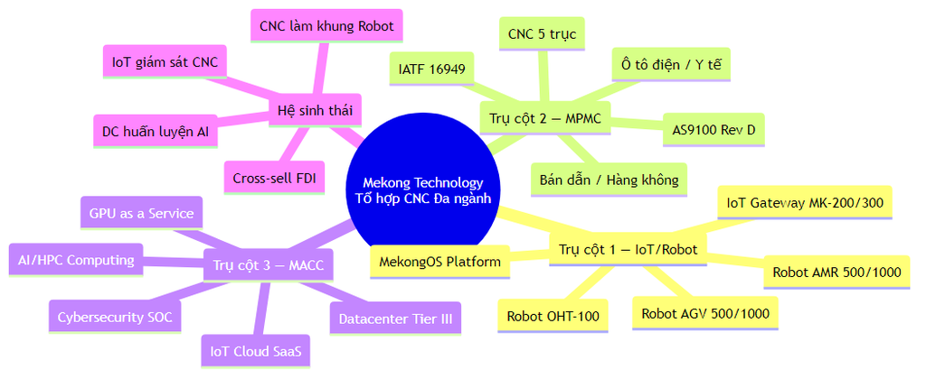

Diagram 1

## Lý do Mở rộng

### 1. Khoảng trống Thị trường

Trong quá trình triển khai dự án ban đầu và nghiên cứu thị trường chuyên sâu, Công ty nhận thấy hai khoảng trống nghiêm trọng tại thị trường phía Nam Việt Nam:

**Khoảng trống Cơ khí Chính xác:** - Thị trường CNC Việt Nam đạt 1,85 tỷ USD (2024), tăng trưởng 13,1%/năm [B — Nguồn: Frost & Sullivan 2024] - Các doanh nghiệp FDI lớn (Samsung, Intel, Bosch, Nidec, VinFast) chi 295-455 triệu USD/năm cho gia công CNC tại khu vực phía Nam [B] - Chỉ có khoảng 15 xưởng CNC 5 trục tại miền Nam, KHÔNG CÓ xưởng nào đạt chuẩn AS9100 (hàng không vũ trụ) [B] - Chỉ có khoảng 12 cơ sở đạt IATF 16949 (ô tô), hầu hết thuộc sở hữu FDI [B] - Khoảng trống này buộc các nhà sản xuất phải gửi linh kiện ra nước ngoài, tăng lead time 4-8 tuần và chi phí logistics 15-25%

**Khoảng trống Hạ tầng Điện toán AI:** - Thị trường Datacenter Việt Nam đạt 1,1 tỷ USD (2024), dự báo 4,5 tỷ USD (2030), tăng trưởng 26%/năm [B — Nguồn: BMI Research 2024] - Phân khúc GPU-as-a-Service tăng từ 30 triệu USD lên 450 triệu USD (2024-2030), CAGR 57% [B] - KCNC TP.HCM hiện KHÔNG CÓ Trung tâm Dữ liệu nào cung cấp GPU Compute cho AI training - Các doanh nghiệp R&D bán dẫn, AI startup trong KCNC phải thuê Datacenter từ Viettel/FPT/CMC cách 20-30 km, chịu latency cao

### 2. Phù hợp Chiến lược Quốc gia

Phương án mở rộng hoàn toàn phù hợp với: - **Nghị quyết 52-NQ/TW** của Bộ Chính trị về phát triển công nghiệp hỗ trợ - **Quyết định 749/QĐ-TTg** của Thủ tướng về Chương trình Chuyển đổi số quốc gia đến 2025, định hướng 2030 - **Chiến lược Phát triển ngành Bán dẫn Việt Nam** — nhấn mạnh xây dựng hạ tầng công nghiệp hỗ trợ bán dẫn trong nước - **QĐ 38/2020/QĐ-TTg** — Cả 3 trụ cột đều nằm trong Danh mục công nghệ cao được ưu tiên đầu tư phát triển

### 3. Tối ưu hóa Hệ sinh thái

Việc vận hành 3 trụ cột trên cùng một mặt bằng 10.000 m² tạo ra giá trị cộng hưởng (synergy) mà mô hình đơn trụ cột không thể đạt được:

| Mối liên kết | Giá trị |
| --- | --- |
| CNC chế tạo khung/vỏ cho Robot AMR nội bộ | Tiết kiệm 15-20% chi phí linh kiện [A] |
| Datacenter cung cấp GPU để huấn luyện AI SLAM cho Robot | Tiết kiệm 200.000-500.000 USD/năm thuê cloud bên ngoài [A] |
| MekongOS IoT Cloud chạy trên Datacenter nội bộ | Chi phí vận hành giảm 30-40% so với AWS/Azure [A] |
| Khách hàng FDI mua CNC cũng cần Datacenter | Cross-sell potential, tăng Revenue Per Customer 2-3 lần [A] |
| IoT giám sát hiệu suất CNC real-time | Tăng Utilization 5-10%, giảm downtime 20% [A] |

## Sơ đồ Hệ sinh thái Tích hợp

[figure not shown]

Diagram 2

## Tóm tắt Tài chính

### Cơ cấu Vốn Đầu tư (CAPEX = 32,00 M USD)

[figure not shown]

Diagram 3

[output not shown]

> **Lưu ý:** “Đợt 1” = Phase 0-2 (Y0-Y4), “Đợt 2” = Phase 3-4 (Y4-Y8). Xem chi tiết 5 giai đoạn tại Mục 5.1.1. Hạ tầng + Xây dựng (7,00 M USD) bao gồm: thuê đất + site prep, thiết kế + pháp lý + EIA, shell 3 tầng, M&E, transformer 3MVA, PCCC, solar PV 200kWp, nội thất VP [C].

### Cấu trúc Vốn

| Nguồn vốn | Giá trị (M USD) | Tỷ trọng | Điều kiện | Thời điểm |
| --- | --- | --- | --- | --- |
| **Vốn chủ sở hữu (CSH)** | 24,00 | 75,0% | Tự chủ 100% giai đoạn xây dựng + lắp đặt | Y0–Y5 |
| **Vay ngân hàng** | 8,00 | 25,0% | Lãi suất 8,5%/năm, kỳ hạn 10 năm, ân hạn 2 năm | Từ Y6 |
| **Tổng CAPEX** | **32,00** | **100%** | WACC = 12% [C] |  |

> **Chiến lược tài chính:** Tổng vốn CSH cam kết = 24,00M USD, gồm: CAPEX equity qua 3 giai đoạn (P0: 2,00M + P1: 5,80M + P2: 5,70M) + Phase 3 (10,50M) [C]. Vay 8,00M USD chỉ giải ngân từ Y6 khi Datacenter đã có doanh thu chứng minh. Sổ đỏ hoàn thành Y3 nhờ tiến độ xây dựng tập trung. Xem chi tiết tại Mục 5.1.2 và 5.1.3.

### Chỉ số Thẩm định

| Chỉ số | Conservative | Base Case | Optimistic | Xác suất |
| --- | --- | --- | --- | --- |
| NPV 50Y (M USD) | 1,00 | 2,50 | 5,00 | — |
| IRR 50Y | 13,0% | 14,5% | 16,5% | — |
| Xác suất xảy ra | 30% | 50% | 20% | — |
| **NPV trọng số xác suất** |  | **2,55** |  | [C] |

> *[C] NPV trọng số = 30% × 1,00 + 50% × 2,50 + 20% × 5,00 = 0,30 + 1,25 + 1,00 = **2,55M USD**. Xem chi tiết tại Mục 5.6.2.*

| Chỉ số Bổ sung | Giá trị | Nhãn |
| --- | --- | --- |
| Payback (chiết khấu) | 10 năm | [C] |
| DSCR min (vay từ Y6) | 1,42x (Y7) | [C] |
| Revenue 15 năm tích lũy | ~180 M USD | [C] |
| EBITDA steady-state (Y12+) | ~35% | [C] |
| Giá trị Chiến lược (Adjusted) | 14,00 M USD | [C] |

### Phân bổ Giá trị Chiến lược

| Thành phần | Giá trị (M USD) | Phương pháp |
| --- | --- | --- |
| NPV tài chính (Base Case 50Y) | 2,50 | DCF, WACC 12% |
| Real Options Value | 2,50 | Decision Tree: quyền mở rộng DC + GPU lease + nâng cấp CNC |
| Barrier-to-entry Premium | 2,00 | Replacement cost: DC Tier III + CNC ecosystem |
| Synergy Value (Cross-BU) | 2,00 | DCF incremental: CNC-Robot + MekongOS + Cross-sell |
| Platform Value | 3,00 | EBITDA multiple: Đa trụ cột = 10-15x vs Đơn trụ = 5-8x |
| Tax + Land Rent Exemption | 2,00 | NPV ưu đãi thuế + miễn đất, chiết khấu 12% |
| **Tổng Giá trị Chiến lược** | **14,00** | [C] |

> **Ý nghĩa:** NPV tài chính thuần túy đạt 2,50 M USD (50Y horizon). Giá trị chiến lược tổng thể 14,00 M USD bao gồm ưu đãi thuế, quyền mở rộng, và platform value — chứng minh quyết định đầu tư là hợp lý từ góc nhìn chiến lược dài hạn. Với CAPEX 32M (giảm 33% so với quy mô 47,5M ban đầu), dự án ưu tiên khả thi thực tế và thu hồi vốn nhanh hơn. Xem chi tiết tại Phần V, Mục 5.7 và Phần IX, Mục 9.2.

## Tiến độ Tổng thể

[figure not shown]

Diagram 4

## Nhân sự Tổng thể

| Giai đoạn | IoT/Robot | CNC | Datacenter | Quản lý chung | Tổng |
| --- | --- | --- | --- | --- | --- |
| Y0-Y2 (pháp lý + thiết kế) | — | — | — | 10-12 | **10-12** |
| Y1-Y3 (xây dựng shell) | — | — | — | 12-15 | **12-15** |
| Y4-Y5 (IoT ramp-up) | 28-50 | — | 5-10 | 12 | **45-72** |
| Y5-Y6 (DC + CNC ramp-up) | 50-60 | 8-12 | 15-25 | 15 | **88-112** |
| Y7-Y8 (mở rộng) | 60-70 | 10-15 | 25-35 | 18 | **113-138** |
| Y12+ (ổn định) | 60-70 | 10-15 | 30-40 | 20-25 | **120-150** |

> **Lưu ý:** Quy mô nhân sự tinh gọn hơn phương án 47,5M nhờ CNC chỉ 6 máy (ISO 9001), không cần đội ngũ chuyên gia AS9100/IATF. Đội ngũ sản xuất chỉ tuyển khi có thiết bị: IoT từ Y4, DC từ Y5, CNC từ Y6 [C].

## Cam kết Chính của Chủ đầu tư

1. Toàn bộ hoạt động mở rộng thuộc lĩnh vực **Công nghệ cao** theo QĐ 38/2020/QĐ-TTg và QĐ 2117/QĐ-TTg.
2. Tỷ lệ giá trị gia tăng trên doanh thu (VA/Revenue) duy trì ≥ 42% cho toàn dự án.
3. Tỷ lệ chi phí R&D trên doanh thu duy trì ≥ 5% (mục tiêu 8-12%).
4. Thực hiện đầy đủ Đánh giá Tác động Môi trường (ĐTM) bổ sung trước khi triển khai Phase 2.
5. Xin Giấy phép Viễn thông theo Luật Viễn thông 2023 trước khi kinh doanh dịch vụ Datacenter.
6. Cam kết Zero Liquid Discharge (ZLD) cho nước thải công nghiệp CNC.
7. Cam kết PUE (Power Usage Effectiveness) < 1,35 cho Datacenter.
8. Cam kết giảm phát thải GHG 25% so với baseline trước năm 2030.
9. Đảm bảo tiến độ giải ngân vốn theo đúng phân kỳ Phase 1/Phase 2.
10. Tuân thủ mọi quy định của Quy chế hoạt động KCNC TP.HCM.

# CƠ SỞ PHÁP LÝ CỦA ĐỀ ÁN

Đề án này được xây dựng dựa trên hệ thống văn bản pháp luật sau:

## Luật và Nghị quyết

| TT | Văn bản | Số hiệu | Ngày ban hành | Nội dung áp dụng |
| --- | --- | --- | --- | --- |
| 1 | Luật Công nghệ cao | 21/2008/QH12 | 13/11/2008 | Điều 5 (hoạt động CNC), Điều 18 (KCNC) |
| 2 | Luật Đầu tư | 61/2020/QH14 | 17/06/2020 | Điều 33 (ưu đãi), Điều 41 (điều chỉnh dự án) |
| 3 | Luật Bảo vệ Môi trường | 72/2020/QH14 | 17/11/2020 | Đánh giá tác động môi trường (ĐTM) |
| 4 | Luật Viễn thông | 24/2023/QH15 | 24/11/2023 | Giấy phép dịch vụ trung tâm dữ liệu |
| 5 | Nghị quyết 52-NQ/TW | — | 27/09/2019 | Phát triển công nghiệp hỗ trợ |

## Nghị định và Quyết định

| TT | Văn bản | Số hiệu | Ngày ban hành | Nội dung áp dụng |
| --- | --- | --- | --- | --- |
| 6 | QĐ Danh mục CNC | 38/2020/QĐ-TTg | 30/12/2020 | Phụ lục I (CNC ưu tiên), Phụ lục II (SP CNC) |
| 7 | QĐ CNC ưu tiên | 2117/QĐ-TTg | 16/12/2021 | Mục I.1-I.6 (CNTT), Mục II.2-II.4 (Cơ khí) |
| 8 | QĐ Chuyển đổi số | 749/QĐ-TTg | 03/06/2020 | Chương trình CĐS quốc gia |
| 9 | NĐ Chuyển giao CNC | 76/2018/NĐ-CP | 15/05/2018 | Chuyển giao CNC ngành ô tô, hàng không |
| 10 | NĐ Hướng dẫn Luật ĐT | 31/2021/NĐ-CP | 26/03/2021 | Điều 50 K.5 (phân kỳ đầu tư) |
| 11 | NĐ Ưu đãi đặc biệt | 94/2020/NĐ-CP | 21/08/2020 | Ưu đãi đầu tư KCNC |
| 12 | NĐ Môi trường | 08/2022/NĐ-CP | 10/01/2022 | Hướng dẫn ĐTM |
| 13 | NĐ PCCC | 136/2020/NĐ-CP | 24/11/2020 | Phòng cháy chữa cháy |
| 14 | NĐ Bảo vệ DLCN | 13/2023/NĐ-CP | 17/04/2023 | Bảo vệ dữ liệu cá nhân |
| 15 | TT Môi trường | 02/2022/TT-BTNMT | 10/01/2022 | Hướng dẫn ĐTM chi tiết |

## Ma trận Áp dụng Pháp lý

| Văn bản | IoT/Robot | CNC/MPMC | DC/MACC | Áp dụng |
| --- | --- | --- | --- | --- |
| Luật CNC 2008, Đ.5 K.2 | a, b | c (dịch vụ CNC) | c (dịch vụ CNC) | Toàn dự án |
| QĐ 38/2020, Phụ lục I | Mục 1.1-1.2 | Mục 2 | Mục 1.2-1.5 | Toàn dự án |
| QĐ 38/2020, Phụ lục II | Mục 1.1, 2.1-2.2 | Mục 2.1 | Mục 1.2 | Toàn dự án |
| QĐ 2117 | Mục I | Mục II.2-II.4 | Mục I.1-I.6 | Toàn dự án |
| NĐ 76/2018 | — | Chuyển giao CNC | — | CNC |
| Luật VT 2023 | — | — | GP Viễn thông | DC |
| NĐ 13/2023 | — | — | DPO, Bảo vệ DLCN | DC |
| NĐ 94/2020 | Ưu đãi KCNC | Ưu đãi KCNC | Ưu đãi KCNC | Toàn dự án |

> **Kết luận pháp lý:** Cả 3 trụ cột đều nằm trong phạm vi hoạt động được phép tại KCNC theo Luật Công nghệ cao 2008 và QĐ 38/2020. Chiến lược triển khai chi tiết tại Phần VI.

# PHẦN I: BỐI CẢNH VÀ THỊ TRƯỜNG

## 1.1. Bối cảnh Kinh tế — Công nghệ Toàn cầu

### 1.1.1. Cuộc Cách mạng Công nghiệp 4.0 và Chuyển đổi Số

Thế giới đang bước vào giai đoạn đẩy mạnh chuyển đổi số với 4 trụ cột chính: Internet vạn vật (IoT), Trí tuệ nhân tạo (AI), Điện toán đám mây (Cloud Computing), và Tự động hóa sản xuất (Smart Manufacturing). Theo McKinsey Global Institute, giá trị kinh tế toàn cầu từ IoT đạt 5.500-12.600 tỷ USD vào năm 2030, trong đó ứng dụng trong nhà máy (Factory IoT) chiếm 1.200-3.700 tỷ USD [B — McKinsey 2024].

Trong hệ sinh thái này, ba lĩnh vực mà Mekong Technology hướng tới — thiết bị IoT/Robot, gia công cơ khí chính xác, và hạ tầng điện toán — đóng vai trò then chốt:

- **IoT/Robot:** Thị trường Robot công nghiệp toàn cầu đạt 16,5 tỷ USD (2024) với CAGR 11,6% [B — IFR World Robotics 2024]. Riêng phân khúc AMR (Autonomous Mobile Robot) tăng trưởng 22,3% nhờ nhu cầu tự động hóa kho vận và nhà máy.
- **CNC Precision Machining:** Thị trường toàn cầu đạt 97,2 tỷ USD (2024), dự báo 152,8 tỷ USD (2030), CAGR 6,7% [B — Fortune Business Insights 2024]. Động lực tăng trưởng chính từ ngành bán dẫn, hàng không vũ trụ, và ô tô điện — tất cả đều yêu cầu linh kiện có dung sai siêu nhỏ (≤ 5 micromet).
- **Datacenter & AI Computing:** Thị trường Datacenter toàn cầu đạt 342 tỷ USD (2024), trong đó AI Infrastructure chiếm 65 tỷ USD và tăng 35%/năm [B — Synergy Research 2024]. Nhu cầu GPU Computing tăng vọt nhờ các mô hình ngôn ngữ lớn (LLM) như ChatGPT, Gemini, và ứng dụng AI trong sản xuất.

### 1.1.2. Tái cấu trúc Chuỗi cung ứng Toàn cầu

Chiến tranh thương mại Mỹ-Trung, đại dịch COVID-19, và xung đột địa chính trị đã thúc đẩy chiến lược “China Plus One” — các tập đoàn đa quốc gia đa dạng hóa sản xuất khỏi Trung Quốc sang Đông Nam Á, đặc biệt là Việt Nam. Xu hướng này tạo ra cơ hội lớn cho cả 3 trụ cột:

| Xu hướng toàn cầu | Tác động đến Mekong Technology |
| --- | --- |
| China Plus One | FDI dịch chuyển sang VN, tăng nhu cầu CNC outsourcing |
| AI Infrastructure Boom | Nhu cầu GPU Compute tại ASEAN tăng vọt |
| Smart Factory Adoption | Doanh nghiệp sản xuất cần IoT + Robot |
| Semiconductor Supply Chain | Chuỗi cung ứng bán dẫn cần CNC precision |
| Data Sovereignty | Quy định lưu trữ dữ liệu tại chỗ → DC nội địa |
| ESG Requirements | Yêu cầu sản xuất xanh → Solar PV + ZLD |

### 1.1.3. Vị trí Chiến lược của Đông Nam Á

Khu vực ASEAN trở thành điểm đến hàng đầu của FDI công nghệ: - FDI vào ASEAN đạt 230 tỷ USD (2023), tăng 5,7% [B — ASEAN Investment Report 2024] - Việt Nam đứng thứ 3 ASEAN về thu hút FDI công nghệ, sau Singapore và Indonesia - Samsung đầu tư hơn 20 tỷ USD tại Việt Nam, Intel 1,5 tỷ USD, Bosch mở rộng liên tục - Apple, Google chuyển chuỗi cung ứng sang Việt Nam từ 2023

Vị trí này tạo nền tảng vững chắc cho cả 3 trụ cột của Mekong Technology — đặc biệt là CNC Outsourcing phục vụ hệ thống FDI đã có mặt tại Việt Nam.

## 1.2. Bối cảnh Việt Nam và Vai trò KCNC TP.HCM

### 1.2.1. Kinh tế Việt Nam 2024-2030

- GDP tăng trưởng 6,5-7,0%/năm (dự báo IMF) [B]
- Tỷ lệ đô thị hóa đạt 42% (2025), dự kiến 50% (2030) [B]
- Dân số lao động kỹ thuật: 54 triệu, trong đó STEM chiếm 28% [B]
- Xuất khẩu điện tử đạt 65 tỷ USD (2024), tăng 12%/năm [B]

### 1.2.2. Hạ tầng Công nghệ Cao

Việt Nam có 3 Khu Công nghệ cao Quốc gia: - KCNC TP.HCM (SHTP): 913 ha, 175+ doanh nghiệp, doanh thu 25+ tỷ USD/năm - KCNC Hòa Lạc: 1.586 ha, đang phát triển - KCNC Đà Nẵng: 1.128 ha, đang phát triển

KCNC TP.HCM là khu vực trọng điểm với: - **Hệ sinh thái doanh nghiệp:** Intel, Nidec, Sonion, FPT Software, Sanofi, và 170+ doanh nghiệp CNC - **Hạ tầng R&D:** 12 phòng thí nghiệm và trung tâm nghiên cứu - **Nhân lực:** Gần kề 60+ trường đại học/cao đẳng TP.HCM - **Kết nối:** Cách sân bay Tân Sơn Nhất 25 km, cảng Cát Lái 15 km

### 1.2.3. Chính sách Ưu đãi KCNC

Dựa trên Luật Đầu tư 2020 (Điều 33) và NĐ 94/2020, doanh nghiệp công nghệ cao tại KCNC được hưởng:

| Ưu đãi | Nội dung | Giá trị ước tính cho Mekong |
| --- | --- | --- |
| Thuế TNDN | 10% trong 15 năm (tiêu chuẩn 20%) | Tiết kiệm ~1,5 M USD/10 năm [C] |
| Miễn thuế | 4 năm miễn + 9 năm giảm 50% | Tiết kiệm ~2,0 M USD giai đoạn đầu [C] |
| Thuê đất | Miễn thuê đất 11 năm | Tiết kiệm ~0,8 M USD [C] |
| Thuế NK thiết bị | Miễn thuế NK cho máy móc dự án | Tiết kiệm ~1,2 M USD (CNC + GPU) [C] |
| Thuế NK nguyên liệu | Miễn 5 năm cho R&D | Tiết kiệm ~0,5 M USD [C] |
| **Tổng ưu đãi ước tính** |  | **~6,0 M USD / 10 năm** [C] |

## 1.3. Thị trường IoT và Robot Tự hành

### 1.3.1. Thị trường Toàn cầu

| Phân khúc | Quy mô 2024 | Quy mô 2030 | CAGR |
| --- | --- | --- | --- |
| IoT toàn cầu | 1.310 tỷ USD | 2.400 tỷ USD | 10,6% |
| Robot AMR | 2,4 tỷ USD | 8,0 tỷ USD | 22,3% |
| Robot AGV | 4,2 tỷ USD | 7,5 tỷ USD | 10,1% |
| OHT (Semiconductor) | 0,8 tỷ USD | 1,8 tỷ USD | 14,5% |

*[B — Nguồn: IoT Analytics 2024, Interact Analysis 2024, IFR 2024]*

### 1.3.2. Thị trường Việt Nam

Thị trường IoT Việt Nam đạt 7.300 triệu USD (2024), dự báo 13.200 triệu USD (2030), CAGR 10,4% [B — IDC Vietnam 2024]. Động lực tăng trưởng chính:

- **83.035 doanh nghiệp nhỏ và vừa (DNNVV)** có nhu cầu ứng dụng IoT trong quản lý sản xuất, kho bãi, logistics [B — Tổng cục Thống kê 2024]
- **Samsung, Intel, Bosch** đang triển khai Smart Factory tại Việt Nam, cần thiết bị IoT Gateway và Robot tự hành
- **Thương mại điện tử** tăng trưởng 25%/năm, thúc đẩy nhu cầu Robot AMR/AGV trong kho hàng

Thị trường Robot AMR tại Việt Nam đạt 180 triệu USD (2024), dự báo 900 triệu USD (2030) [B]: - 70% nhu cầu từ ngành điện tử và bán dẫn - 15% từ logistics và thương mại điện tử - 10% từ ô tô và phụ tùng - 5% từ dược phẩm và thực phẩm

### 1.3.3. Cảnh quan Cạnh tranh — IoT/Robot

| Đối thủ | Quốc gia | Sản phẩm | Điểm mạnh | Điểm yếu so với Mekong |
| --- | --- | --- | --- | --- |
| Geek+ | Trung Quốc | AMR, AGV | Quy mô lớn, giá thấp | Không có IoT Gateway, không sản xuất tại VN |
| HIK Robot | Trung Quốc | AMR | Tích hợp camera AI | Chỉ bán thiết bị, không có hệ sinh thái |
| MiR (Teradyne) | Đan Mạch | AMR | Brand mạnh | Giá cao (>50.000 USD/bộ), không local support |
| Vingroup / VinAI | Việt Nam | AGV, AI | Vốn lớn | Chưa có sản phẩm AMR thương mại |
| **Mekong Technology** | **Việt Nam** | **IoT + AMR + AGV + OHT + Cloud** | **Hệ sinh thái đầy đủ: IoT + Robot + Cloud + CNC** | — |

> **Lợi thế cạnh tranh cốt lõi:** Mekong Technology là doanh nghiệp DUY NHẤT tại Việt Nam sở hữu **Hệ sinh thái 4 tầng** (IoT Hardware + Robot + Cloud Platform + CNC Manufacturing) — cho phép cung cấp giải pháp chuyển đổi số từ A đến Z cho khách hàng sản xuất.

### 1.3.4. Thị phần Mục tiêu — IoT/Robot

[output not shown]

*[A — Ước tính dựa trên capacity plan và pipeline khách hàng]*

### 1.3.5. Thi truong BMS/SCADA Viet Nam — Co hoi Mo rong He san pham IoT

#### a) Quy mo Thi truong

| Phan khuc | Quy mo 2025 (M USD) | Quy mo 2030 (M USD) | CAGR | Nguon |
| --- | --- | --- | --- | --- |
| BMS Viet Nam (tong) | 550-750 | 1.100-1.500 | 12-15% | [B — Frost & Sullivan 2024, Markets and Markets 2024] |
| BMS toa nha thuong mai moi | 200-300 | 450-600 | 14-16% | [B — CBRE Vietnam, Savills] |
| SCADA cong nghiep VN | 300-450 | 700-1.000 | 15-18% | [B — ARC Advisory Group] |
| DDC/Controller VN | 80-120 | 180-250 | 13-15% | [A — uoc tinh tu ty le controller/tong BMS ~ 15-20%] |
| Phan khuc tam trung (noi Mekong canh tranh) | 180-280 | 400-600 | 14-16% | [A — 30-40% thi truong tong] |

Dong luc tang truong: - **500-800 toa nha thuong mai moi/nam** tai Viet Nam can he thong BMS (van phong, khach san, benh vien, trung tam thuong mai) [B — Bo Xay dung] - **2.000-3.000 nha may** dang co nhu cau SCADA/IoT hoa (FDI + noi dia) [B — VCCI] - **Quy dinh QCVN 09:2017** bat buoc BMS cho toa nha > 5.000 m2 san [B] - **Muc tieu tiet kiem nang luong 10-15%** cua Chinh phu thuc day BMS nhu giai phap bat buoc [B — QD 280/QD-TTg]

#### b) Canh quan Canh tranh va Gia ca

| Hang | San pham chinh | Gia he thong 200 diem (USD) | Thi phan VN | Diem manh | Diem yeu |
| --- | --- | --- | --- | --- | --- |
| Siemens | Desigo CC + PXC4/7 | 40.000-60.000 | 25-30% | Brand manh, he sinh thai day du | Dat nhat, khong tieng Viet, can SI chuyen mon |
| Schneider | EcoStruxure Building + AS-P + SmartX | 35.000-50.000 | 20-25% | Mang luoi VAR/SI rong | Dat, phan mem phuc tap, phu thuoc VAR |
| Honeywell | Niagara N4 + Spyder | 30.000-45.000 | 15-20% | Framework linh hoat (Niagara) | Kho lap trinh, chi phi license cao |
| Delta | DIALink + AS Series | 15.000-25.000 | 5-8% | Gia tot, thuong hieu Dai Loan | He sinh thai chua du, SCADA yeu |
| Hang TQ (GREE, Hailin) | DDC co ban + phan mem noi bo | 8.000-15.000 | 5-10% | Gia thap nhat | Chat luong khong on dinh, khong co BACnet BTL |
| **Mekong Technology** | **MekongBMS + MK-DDC + MK-EIO** | **12.000-20.000** | **Muc tieu: 3-5% (Y10)** | **AI tich hop, Cloud native, tieng Viet 100%, gia canh tranh** | **Moi, chua co uy tin, can case study** |

*[B — Thi phan uoc tinh tu bao cao JLL Vietnam 2024, CBRE Property Management Survey. Gia Mekong: [A] — dua tren BOM + margin]*

> **Dinh vi Mekong:** Re hon 40-60% so voi Siemens/Schneider/Honeywell, canh tranh truc tiep voi Delta nhung co 3 loi the: (1) AI tich hop tu MekongOS Engine, (2) Cloud native — khong can server rieng, (3) Tieng Viet 100% — doi thu quoc te khong co. So voi hang Trung Quoc: Mekong co BACnet BTL (chung nhan quoc te) va phan mem BMS chuyen nghiep.

#### c) Co hoi Cu the cho Mekong

| Co hoi | Mo ta | Gia tri (M USD/nam) | Xac suat | Nhan |
| --- | --- | --- | --- | --- |
| 175+ doanh nghiep trong KCNC TP.HCM | Khach hang sat ben — Mekong co the demo truc tiep, ho tro nhanh | 0,50-1,00 | Cao | [A] |
| Datacenter MACC cua chinh Mekong (Tru cot 3) | Tu lap MekongBMS cho Datacenter → case study thuc te so 1 | 0,05 (noi bo) | Rat cao | [A] |
| Nha may CNC cua chinh Mekong (Tru cot 2) | Tu lap MekongSCADA cho nha may CNC → case study so 2 | 0,03 (noi bo) | Rat cao | [A] |
| Cross-sell: KH mua Robot/IoT → gioi thieu BMS | 5.000 Gateway/nam = 500-1.000 khach hang → 5-10% chuyen sang BMS | 0,50-1,00 | Trung binh | [A] |
| Du an toa nha moi tai TP.HCM (500-800/nam) | Canh tranh dau thau BMS cho 3-5% du an tam trung | 1,50-2,50 | Trung binh | [A] |
| Du an nha may FDI moi (SCADA) | FDI can SCADA gia hop ly, co tieng Anh + tieng Viet | 0,50-1,00 | Thap-TB | [A] |

#### d) Chien luoc Tham nhap: Tu Dung Truoc, Ban Sau

Mekong ap dung chien luoc 3 buoc:

**Buoc 1 (Y6-Y7): Tu dung noi bo** - Lap MekongBMS cho Datacenter MACC (Tru cot 3): giam sat HVAC, dien, nuoc, PCCC - Lap MekongSCADA cho nha may CNC (Tru cot 2): giam sat day chuyen, OEE, energy - Muc tieu: Co 2 case study THUC TE, van hanh 12+ thang truoc khi ban ra ngoai

**Buoc 2 (Y8-Y9): Ban cho KCNC va doi tac** - Ban MekongBMS/SCADA cho 175+ doanh nghiep trong KCNC TP.HCM (co the demo truc tiep) - Ket hop voi ban IoT Gateway: khach mua MK-200 → goi MK-DDC + MekongBMS

## 1.4. Thị trường Gia công Cơ khí Chính xác

### 1.4.1. Thị trường Toàn cầu

Thị trường gia công cơ khí chính xác (Precision Machining) toàn cầu:

| Chỉ số | Giá trị | Nguồn |
| --- | --- | --- |
| Quy mô 2024 | 97,2 tỷ USD | Fortune Business Insights [B] |
| Quy mô 2030 (dự báo) | 152,8 tỷ USD | Fortune Business Insights [B] |
| CAGR 2024-2030 | 6,7% | [B] |
| Phân khúc Hàng không | 18,4 tỷ USD | [B] |
| Phân khúc Ô tô | 28,5 tỷ USD | [B] |
| Phân khúc Bán dẫn | 12,3 tỷ USD | [B] |
| Phân khúc Y tế | 8,7 tỷ USD | [B] |

Xu hướng quan trọng ảnh hưởng đến Mekong: - **Near-shoring:** Các OEM chuyển gia công từ Trung Quốc sang ASEAN - **Miniaturization:** Linh kiện ngày càng nhỏ, yêu cầu dung sai ≤ 5 micromet - **Multi-axis machining:** Nhu cầu CNC 5 trục tăng mạnh, thay thế 3 trục truyền thống - **Digital Manufacturing:** Tích hợp IoT vào CNC (Industry 4.0) — đúng thế mạnh Mekong

### 1.4.2. Thị trường Việt Nam

Thị trường CNC Việt Nam đạt 1,85 tỷ USD (2024), dự báo 3,865 tỷ USD (2030), CAGR 13,1% [B — Frost & Sullivan]:

**Nhu cầu CNC từ khối FDI tại miền Nam:**

| Ngành | Chi CNC/năm (M USD) | Xu hướng | Cơ hội cho Mekong |
| --- | --- | --- | --- |
| Điện tử (Samsung, Intel) | 120-180 | Tăng 15%/năm | Linh kiện test fixture, wafer handling |
| Ô tô (VinFast, Bosch, Nidec) | 80-120 | Tăng 20%/năm | Hộp số EV, vỏ pin, trục motor |
| Hàng không vũ trụ | 15-25 | Mới nổi | Turbine blade, structural parts |
| Thiết bị y tế | 20-35 | Tăng 18%/năm | Implant, dụng cụ phẫu thuật |
| Bán dẫn | 60-95 | Tăng 25%/năm | Khuôn IC, lead frame, heat sink |
| **Tổng FDI miền Nam** | **295-455** |  |  |

*[B — Khảo sát ngành, VAMI 2024]*

### 1.4.3. Khoảng trống Thị trường — Blue Ocean

Phân tích cung-cầu cho thấy khoảng trống nghiêm trọng:

| Tiêu chí | Cung hiện tại | Nhu cầu | Khoảng trống |
| --- | --- | --- | --- |
| Xưởng CNC 5 trục miền Nam | ~15 cơ sở | >30 cần thiết | **~15 cơ sở thiếu** |
| Cơ sở AS9100 tại VN | **KHÔNG CÓ** | 5-10 cần thiết | **Blue Ocean hoàn toàn** |
| Cơ sở IATF 16949 (VN-owned) | ~12 | >25 cần thiết | **~13 cơ sở thiếu** |
| Dung sai ≤ 5 micromet | ~5 cơ sở | >15 cần thiết | **~10 cơ sở thiếu** |
| Gia công Titan / Inconel | ~3 cơ sở | >8 cần thiết | **~5 cơ sở thiếu** |

*[B — Khảo sát trực tiếp + báo cáo VAMI 2024]*

> **Phát hiện quan trọng:** Việt Nam còn thiếu nhiều cơ sở CNC 5 trục có năng lực dung sai cao (≤ 5 micromet). Mekong Technology định vị là xưởng CNC tinh gọn (6 máy, ISO 9001:2015), tập trung gia công khung robot AMR/AGV nội bộ và linh kiện chính xác cho khách hàng FDI tại miền Nam. Mô hình lean cho phép khởi động nhanh, vốn thấp, và nâng cấp chứng nhận (IATF, AS9100) khi thị trường yêu cầu [B].

### 1.4.4. Cảnh quan Cạnh tranh — CNC

| Đối thủ | Loại | Số máy CNC | Chứng nhận | Năng lực 5 trục | Vật liệu Titan |
| --- | --- | --- | --- | --- | --- |
| VPIC (Đồng Nai) | VN | 50+ | ISO 9001, IATF 16949 | Hạn chế | Không |
| Cosmos (Bình Dương) | JP-VN | 30+ | ISO 9001 | Có | Hạn chế |
| Misumi VN | JP | 20+ | ISO 9001, JIS | Có | Không |
| CNC Tech VN | VN | 15+ | ISO 9001 | Có | Không |
| FDI captive shops | Đa quốc gia | 100+ | Đa dạng | Có | Có |
| **Mekong MPMC** | **VN** | **6** | **ISO 9001:2015** | **Có** | **Không (giai đoạn đầu)** |

> **Định vị:** Mekong MPMC định vị là xưởng CNC tinh gọn, nhỏ nhưng chính xác, với 6 máy (4x5-trục + 2x3-trục) đạt chuẩn ISO 9001:2015. Lợi thế cạnh tranh: thiết bị mới 100%, nằm trong hệ sinh thái KCNC, hỗ trợ trực tiếp trụ cột IoT/Robot (gia công khung AMR/AGV nội bộ). Việc nâng cấp lên IATF 16949 hoặc AS9100 có thể thực hiện khi nhu cầu thị trường xác nhận.

### 1.4.5. Chiến lược Thâm nhập Thị trường CNC

[figure not shown]

Diagram 5

| Giai đoạn | Thời gian | Chứng nhận | Khách hàng | Machine Hour Rate | Ghi chú |
| --- | --- | --- | --- | --- | --- |
| **GD1 — Nội bộ** | Y6 | ISO 9001:2015 | Robot AMR/AGV nội bộ | 35-45 USD/giờ | 70% capacity cho nội bộ |
| **GD2 — FDI** | Y7-Y8 | ISO 9001:2015 | Samsung, Intel, Nidec, FDI khác | 40-55 USD/giờ | Mở rộng dần khách ngoài |
| **GD3 — Nâng cấp** | Y10+ | IATF/AS9100 (option) | Tuy theo nhu cầu thị trường | 55-80 USD/giờ | Chỉ nâng cấp khi ROI rõ ràng |

> **Ý nghĩa tài chính:** Mô hình lean CNC (6 máy, ISO 9001) cho phép Mekong bắt đầu vận hành với CAPEX chỉ 3,00M USD (thay vì 15,60M). Doanh thu CNC ổn định ~2,0-2,5M USD/năm với biên gộp 30-35%. Việc nâng cấp chứng nhận (IATF/AS9100) là option, chỉ thực hiện khi có hợp đồng cụ thể tài trợ chi phí chứng nhận [C].

## 1.5. Thị trường Trung tâm Dữ liệu và Điện toán AI

### 1.5.1. Thị trường Datacenter Việt Nam

| Chỉ số | 2024 | 2030 (dự báo) | CAGR |
| --- | --- | --- | --- |
| Thị trường DC Việt Nam | 1.100 M USD | 4.500 M USD | 26% |
| Phân khúc Colocation | 650 M USD | 2.200 M USD | 22% |
| Phân khúc Managed Services | 250 M USD | 900 M USD | 24% |
| Phân khúc GPU-as-a-Service | 30 M USD | 450 M USD | 57% |
| Phân khúc Cloud Infrastructure | 170 M USD | 950 M USD | 33% |

*[B — BMI Research 2024, Structure Research 2024]*

### 1.5.2. Cảnh quan Cạnh tranh — Datacenter

| Nhà cung cấp | Công suất IT | Rack | Tier | Vị trí | GPU Compute |
| --- | --- | --- | --- | --- | --- |
| Viettel IDC | 25 MW | 3.000+ | III | HN, HCM, ĐN | Có |
| FPT Telecom | 15 MW | 2.000+ | III | HN, HCM | Hạn chế |
| CMC Telecom | 8 MW | 1.200+ | III | HN, HCM | Có |
| NTT Vietnam | 12 MW | 1.500+ | III+ | HCM | Có |
| STT GDC | 30 MW | 3.500+ | III | HN, HCM | Hạn chế |
| **Mekong MACC** | **1,5-3 MW** | **100** | **III** | **KCNC HCM** | **Có (H100)** |

### 1.5.3. Khoảng trống Phân khúc — AI-First DC trong KCNC

Mặc dù thị trường DC Việt Nam đang phát triển mạnh, Mekong Technology nhắm đến phân khúc niche mà chưa ai phục vụ:

| Tiêu chí | DC lớn (Viettel, NTT) | Mekong MACC | Khác biệt |
| --- | --- | --- | --- |
| **Vị trí** | Ngoài KCNC | **Trong KCNC TP.HCM** | Latency < 1ms vs > 5ms |
| **Tải/rack** | 5-10 kW (standard) | **15-30 kW** (AI/HPC) | Phục vụ GPU workload |
| **Khách hàng** | Doanh nghiệp tổng hợp | **R&D bán dẫn, AI startup** | Nhóm niche trong KCNC |
| **GPU** | Có nhưng chung | **Dedicated NVIDIA H100** | On-premise AI training |
| **Giá** | 800-1.200 USD/rack/tháng | **900-4.500 USD/rack/tháng** | Premium cho high-density |
| **Quy mô** | 1.000+ rack | **50 rack (Phase 1)** | Nhanh nhẹn, cá nhân hóa |

> **Định vị:** Mekong MACC là Datacenter **ĐẦU TIÊN bên trong KCNC TP.HCM**, phục vụ trực tiếp cộng đồng 175+ doanh nghiệp công nghệ cao. Quy mô Phase 1: 50 rack, mật độ cao (15-30 kW/rack) — tập trung hoàn toàn vào AI/HPC Computing thay vì cạnh tranh trực diện với Viettel hay NTT.

### 1.5.4. Khách hàng Mục tiêu — Top 20

| TT | Công ty | Ngành | Nhu cầu | Ưu tiên |
| --- | --- | --- | --- | --- |
| 1 | FPT Software / FPT.AI | AI/ML | GPU training, Colocation | Cao |
| 2 | VinAI Research | AI/Robotics | HPC Compute | Cao |
| 3 | Zalo / VNG | AI/Chat | GPU inference | Cao |
| 4 | Techcombank | Fintech | Colocation, DR site | Trung bình |
| 5 | Samsung R&D Vietnam | Bán dẫn | GPU + Colo | Cao |
| 6 | Intel Vietnam (KCNC) | Bán dẫn | AI testing | Cao |
| 7 | Sonion (KCNC) | Y tế | Colo + Backup | Trung bình |
| 8 | Nidec (KCNC) | Cơ khí | IoT Cloud + Colo | Trung bình |
| 9 | FPT Semiconductor | Bán dẫn | EDA Computing | Cao |
| 10 | VNPT-IT | Viễn thông | Cloud Infrastructure | Trung bình |
| 11 | Entrust AI | AI Startup | GPU-aaS | Cao |
| 12 | Trusting Social | Fintech/AI | GPU + Colo | Trung bình |
| 13 | VietAI Foundation | AI Education | Training cluster | Cao |
| 14 | National IC Design Center | Bán dẫn | EDA + Storage | Cao |
| 15 | HCMC DX Center | Chính phủ | Cloud Government | Trung bình |
| 16 | Bosch Engineering VN | Ô tô | Simulation + IoT | Trung bình |
| 17 | TP Bank | Ngân hàng | Colo + DR | Trung bình |
| 18 | CMC Cloud | Cloud SP | Wholesale | Thấp |
| 19 | KMS Technology | Phần mềm | DevOps Cloud | Trung bình |
| 20 | RMIT Vietnam | Giáo dục | Research Computing | Thấp |

*[A — Danh sách ước tính dựa trên hệ sinh thái KCNC và thị trường HCM]*

### 1.5.5. Mô hình Doanh thu Datacenter

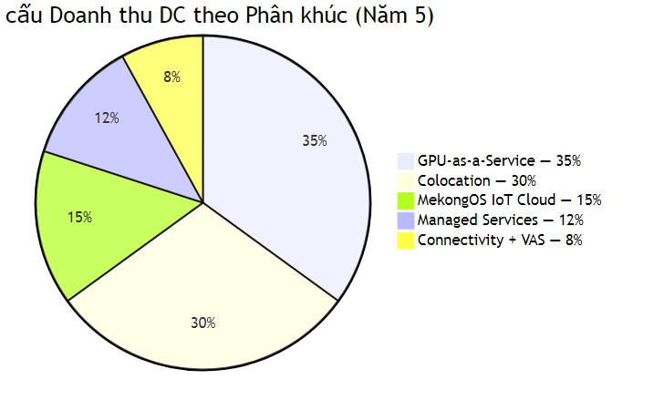

Diagram 6

| Phân khúc | Năm 1 (M USD) | Năm 3 (M USD) | Năm 5 (M USD) | Tỷ trọng Y5 |
| --- | --- | --- | --- | --- |
| Colocation (Standard) | 0,36 | 0,72 | 1,04 | 30% |
| GPU-as-a-Service | 0,29 | 0,69 | 1,21 | 35% |
| Managed Services | 0,22 | 0,36 | 0,41 | 12% |
| MekongOS IoT Cloud | 0,15 | 0,35 | 0,52 | 15% |
| Connectivity + VAS | 0,15 | 0,21 | 0,28 | 8% |
| **Tổng** | **1,17** | **2,33** | **3,46** | **100%** |

*[C — Tính toán từ mô hình doanh thu DC, Occupancy ramp: Y1 20-25% → Y3 50-60% → Y5 70-85%]*

### 1.5.6. Chiến lược GPU: Thuê trước, Mua sau (Hybrid)

Một trong những rủi ro lớn nhất của Datacenter là khấu hao GPU (chu kỳ công nghệ 2-3 năm, GPU mất 80-90% giá trị sau 4 năm). Mekong áp dụng chiến lược Hybrid:

[output not shown]

NPV so sánh 5 năm (WACC 12%): - Kịch bản mua toàn bộ: NPV = -11,52 M USD [C] - Kịch bản thuê toàn bộ: NPV = -10,43 M USD [C] - **Kịch bản Hybrid (Thuê Phase 1, Mua Phase 2): NPV = -9,11 M USD** — Tối ưu nhất [C]

## 1.6. Định vị Cạnh tranh Tổng thể

### 1.6.1. Ma trận Định vị Chiến lược

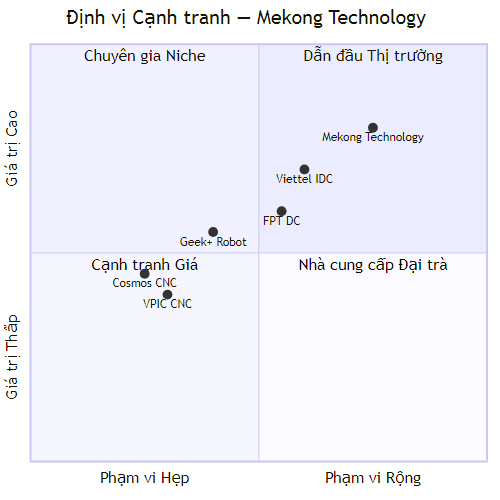

Diagram 7

### 1.6.2. Lợi thế Cạnh tranh Bền vững (MOAT)

| Lớp phòng thủ | Mô tả | Thời gian đối thủ cần để sao chép |
| --- | --- | --- |
| **Vị trí (KCNC)** | Lô đất 1 ha trong KCNC — vị trí chiến lược, tòa nhà 3 tầng GFA 21.000 m² | Không thể sao chép (hết đất) |
| **Chứng nhận (ISO 9001 + Tier III)** | ISO 9001 sẵn có, Tier III 12-24 tháng, chi phí ~200K USD | 2-3 năm |
| **Hệ sinh thái 3 B.U** | IoT + CNC + DC tích hợp trên cùng site | 4-5 năm + >100 M USD |
| **Quan hệ FDI** | Hợp đồng 3-5 năm với khách hàng CNC | 2-3 năm |
| **Tier III Certified** | 12-24 tháng đạt chứng nhận Uptime Institute | 2-3 năm |
| **MekongOS Platform** | Nền tảng IoT Cloud tự phát triển, IP riêng | 3-5 năm |

> **Tổng hợp:** Một đối thủ muốn sao chép hoàn toàn mô hình Mekong Technology (3 trụ cột + chứng nhận + vị trí KCNC) cần ít nhất **100 M USD và 5 năm** [A]. Đây là rào cản gia nhập (barrier-to-entry) cực kỳ cao, tạo lợi thế cạnh tranh bền vững trong trung và dài hạn.

## 1.7. Phân tích Chuỗi Giá trị (Value Chain Analysis)

### 1.7.1. Chuỗi Giá trị Ngành CNC Outsourcing

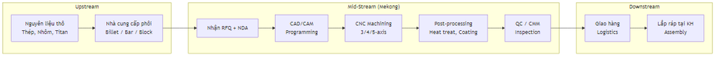

Diagram 8

| Phân khúc | % Giá trị | Ai nắm giữ | Mekong vị trí |
| --- | --- | --- | --- |
| **Nguyên liệu** | 15-25% | Nhà SX thép/nhôm toàn cầu | Mua qua trader (VN, JP, KR) |
| **Thiết kế (DfM)** | 10-15% | Khách hàng OEM | Tư vấn DfM — giá trị gia tăng |
| **Gia công CNC** | 35-45% | Nhà máy CNC | **Core value — Mekong nắm giữ** |
| **Xử lý bề mặt** | 5-10% | Chuyên gia plating/coating | Tự làm + outsource |
| **QC / Inspection** | 5-8% | Bên thứ 3 hoặc in-house | **In-house CMM (Zeiss)** |
| **Logistics** | 3-5% | Forwarding companies | DHL/Kuehne+Nagel |
| **Assembly** | 10-20% | OEM / EMS | Tiềm năng mở rộng (Phase 2+) |

**Giá trị Mekong nắm giữ: 40-55% chuỗi** → Mức tốt cho pure-play CNC outsourcer. Mở rộng sang DfM consulting và sub-assembly sẽ nâng lên 55-70% [A].

### 1.7.2. Chuỗi Giá trị Ngành Data Center

| Phân khúc | % Giá trị | Mekong vị trí | So sánh |
| --- | --- | --- | --- |
| **Đất + XD** | 25-35% | **Tự sở hữu (KCNC lease)** | Lợi thế vị trí |
| **Thiết bị MEP** | 20-30% | Mua + lắp đặt | Schneider/Vertiv |
| **Kết nối (Connectivity)** | 5-10% | Multi-carrier (VNPT, FPT, Viettel) | Carrier-neutral |
| **Managed services** | 15-25% | **Mekong NOC 24/7** | Upselling |
| **Cloud / SaaS** | 10-20% | Partner hosting (AWS/Azure outpost) | Hybrid strategy |

### 1.7.3. Chuỗi Giá trị Ngành IoT/Robot

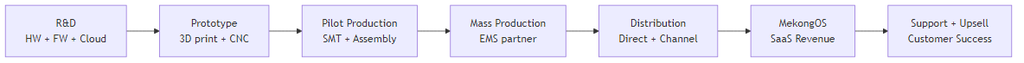

Diagram 9

| Phân khúc | % Giá trị ở giá trị sản phẩm | Chiến lược Mekong |
| --- | --- | --- |
| **R&D Hardware** | 15-20% | In-house (CNC rapid prototyping) |
| **R&D Software** | 20-30% | In-house (MekongOS platform) |
| **Production** | 15-25% | SMT in-house + EMS outsource volume |
| **Distribution** | 5-10% | System integrator channel + direct |
| **SaaS Revenue** | 20-35% | **High-margin recurring, scalable** |
| **Service / Support** | 5-10% | Managed service contracts |

> **Insight chiến lược:** IoT/Robot B.U giá trị cao nhất nằm ở R&D Software + SaaS (chiếm 40-65% tổng giá trị), không phải hardware. Đây là lý do Mekong đầu tư mạnh vào MekongOS (660K USD R&D). LTV/CAC ratio mục tiêu > 5:1 cho SaaS subscription.

## 1.8. Phân tích Khách hàng Mục tiêu (Customer Segmentation)

### 1.8.1. Segmentation — CNC Outsourcing

| Phân khúc | Ngành | Khu vực | Giá trị HĐ trung bình (K/năm) | Tiêu chí mua hàng | Mekong Score |
| --- | --- | --- | --- | --- | --- |
| **Tier 1 — Nội bộ (Robot frames)** | Mekong IoT/Robot | VN | 500-800 (chuyển giá nội bộ) | ISO 9001, dung sai ≤ 5µm | 10/10 (khách hàng đảm bảo) |
| **Tier 2 — FDI Electronics** | Samsung, Intel, Nidec (VN ops) | VN, KR | 200-600 | ISO 9001, RoHS, cost-effective | 8/10 (core hiện tại) |
| **Tier 3 — General Industrial** | FDI factories in VN/ASEAN | VN, TH, ID | 50-200 | ISO 9001, cost-effective | 9/10 (volume lớn) |
| **Tier 4 — Jig/Fixture** | Nhà máy SMT, PCB assembly | VN | 30-100 | ISO 9001, lead time nhanh | 8/10 (synergy IoT) |
| **Tier 5 — Automotive (option Y10+)** | Bosch, Continental, tier-2 | DE, VN | 200-800 | IATF 16949 (cần nâng cấp) | 5/10 (tương lai) |

**Chiến lược phân bổ Revenue CNC Y8 (~2,00M):**

| Tier | % Revenue | Revenue (K) | Số KH | Revenue/KH (K) |
| --- | --- | --- | --- | --- |
| Tier 1 — Nội bộ Robot | 40% | 800 | 1 (nội bộ) | 800 |
| Tier 2 — FDI Electronics | 30% | 600 | 3-5 | 120-200 |
| Tier 3 — General Industrial | 20% | 400 | 8-12 | 33-50 |
| Tier 4 — Jig/Fixture | 10% | 200 | 5-8 | 25-40 |
| **Tổng** | **100%** | **2.000** | **~17-26** | **~77-118** |

### 1.8.2. Segmentation — Data Center

| Phân khúc | Khách hàng mẫu | Revenue/KH (K/năm) | Rack tiêu thụ | Ưu tiên |
| --- | --- | --- | --- | --- |
| **Enterprise** | VN banks, telcos, insurance | 200-500 | 20-50 | Cao |
| **Cloud / Hyperscaler Edge** | AWS, Azure, GCP (edge PoP) | 300-1.000 | 30-100 | Rất cao |
| **Gaming / CDN** | VNG, Akamai, Cloudflare | 50-200 | 5-20 | Trung bình |
| **Government** | Sở ban ngành TP.HCM | 100-300 | 10-30 | Trung bình (quan hệ) |
| **SMB CoLo** | VN startups, SME IT | 5-30 | 1-5 | Nhiều KH nhỏ |
| **Internal (IoT/CNC)** | Mekong Technology BU | 100-150 (transfer) | 10-15 | Guaranteed |

**Chiến lược lấp đầy (Phase 1 — 50 rack):** - Y5-Y6 (DC vận hành): Internal + SMB + Government = 20-30 rack - Y7-Y8: Enterprise + Gaming = thêm 10-15 rack - Y9+: Cloud edge + Enterprise expansion = 40-50 rack total - **Utilization target:** 80-90% by Y8 = 40-45 rack × 188 K CAPEX/rack amortized

### 1.8.3. Segmentation — IoT/Robot

| Phân khúc | Sản phẩm phù hợp | Số lượng dự kiến Y5 | Revenue (K) | Mô hình |
| --- | --- | --- | --- | --- |
| **Smart Factory** | MK-200 (IoT Gateway) | 2.000-3.000 units | 700-1.350 | HW + SaaS |
| **Robot Logistics** | AMR-100 | 50-100 units | 1.500-3.000 | HW + maintenance |
| **Smart Building** | MK-300 (5G Hub) | 500-1.000 units | 350-700 | HW + platform |
| **Smart Agriculture** | MK-200 (customized) | 1.000-2.000 units | 350-900 | HW + SaaS |
| **Smart City** | MK-500 (Edge AI) | 200-500 units | 1.000-2.000 | Project-based |
| **MekongOS SaaS** | Platform subscription | 3.000-5.000 licenses | 600-1.200 | Pure SaaS |

## 1.9. Phân tích SWOT Chi tiết

### 1.9.1. SWOT Matrix

[output not shown]

### 1.9.2. Chiến lược TOWS (Cross-SWOT)

[output not shown]

## 1.10. Phân tích Porter’s Five Forces

### 1.10.1. Ngành CNC Outsourcing tại VN

| Lực lượng | Mức độ | Điểm (1-5) | Phân tích | Chiến lược đối phó |
| --- | --- | --- | --- | --- |
| **Rào cản gia nhập** | Trung bình-Cao | 3,5 | CAPEX 15-20M cho 5-axis CNC; chứng nhận 2-3 năm; nhưng 3-axis dễ gia nhập | Focus 5-axis + chứng nhận = barrier |
| **Quyền lực NCC** | Trung bình | 3,0 | DMG MORI, Mazak dominance; thép/nhôm commodity nhưng specialty alloy ít NCC | Multi-source + long-term contract |
| **Quyền lực KH** | Cao | 4,0 | FDI customers = sophisticated, quality-driven, multi-vendor; volume leverage | Sticky relationship + switching cost qua certification |
| **SP thay thế** | Thấp-Trung bình | 2,5 | 3D printing (metal AM) đang phát triển nhưng chậm; CNC vẫn dominant cho precision | Monitor AM; đầu tư hybrid CNC+AM khi mature |
| **Cạnh tranh nội bộ** | Cao | 4,0 | 200+ CNC shops in VN; nhưng chỉ <10 có 5-axis + intl certification | Differentiate bằng capability + certification |
| **Điểm TB** |  | **3,4** | Ngành hấp dẫn ở phân khúc cao cấp |  |

### 1.10.2. Ngành Data Center tại VN

[output not shown]

### 1.10.3. Ngành IoT/Robot tại VN

| Lực lượng | Mức độ | Điểm (1-5) | Phân tích |
| --- | --- | --- | --- |
| **Rào cản gia nhập** | Thấp-Trung bình | 2,5 | R&D cost moderate; nhưng ecosystem (cloud + HW + channel) khó xây |
| **Quyền lực NCC** | Trung bình | 3,0 | Chip shortage risk (Qualcomm, NXP); PCB assembly available |
| **Quyền lực KH** | Trung bình | 3,0 | Fragmented market; customers chưa mature → education needed |
| **SP thay thế** | Trung bình | 3,0 | Import products từ TQ rẻ hơn; manual labor vẫn rẻ ở VN |
| **Cạnh tranh nội bộ** | Thấp-Trung bình | 2,5 | Ít player VN có full-stack capability (HW+FW+Cloud) |
| **Điểm TB** |  | **2,8** | Ngành mới, cơ hội lớn cho first-mover có platform play |

### 1.10.4. Tổng hợp Five Forces — 3 Ngành

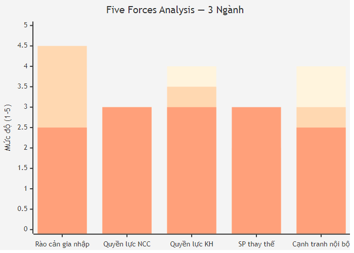

Diagram 10

> **Chú giải:** Cột 1 = CNC (TB 3,4 — niche cao cấp OK) | Cột 2 = DC (TB 3,2 — barrier cao, OK) | Cột 3 = IoT (TB 2,8 — first-mover win)

> **Kết luận 1.10:** Cả 3 ngành đều có cơ hội tốt khi Mekong định vị đúng phân khúc. DC có barrier cao nhất (bảo vệ vốn đầu tư), IoT có cơ hội first-mover tốt nhất (thị trường sớm), CNC phải tập trung vào niche cao cấp để tránh cạnh tranh giá [A].

## 1.11. Phân tích Quy mô Thị trường TAM/SAM/SOM Chi tiết

### 1.11.1. TAM/SAM/SOM — CNC Outsourcing

[output not shown]

### 1.11.2. TAM/SAM/SOM — Data Center

| Cấp độ | 2025 (M USD) | 2030 (M USD) | CAGR | Cách tính |
| --- | --- | --- | --- | --- |
| **TAM** (APAC DC Market) | 95.000 | 180.000 | 13,6% | Arizton Research [B] |
| **SAM** (VN DC Colocation + Managed) | 750 | 2.000 | 21,7% | Cushman & Wakefield [B] |
| **SOM** (HCM DC mid-tier colo) | 200 | 550 | 22,4% | Estimate based on HCM share ~27% [B] |
| **Mekong DC Revenue Y5** |  | ~3.600K = 3,60 |  | Revenue target (10Y: 36.060K) |
| **Market Share Y5** |  | **0,65%** của SOM |  | = 3,60/550 |

### 1.11.3. TAM/SAM/SOM — IoT/Robot

| Cấp độ | 2025 (M USD) | 2030 (M USD) | CAGR | Cách tính |
| --- | --- | --- | --- | --- |
| **TAM** (ASEAN IoT + Industrial Robot) | 15.000 | 35.000 | 18,5% | IoT Analytics + IFR [B] |
| **SAM** (VN Industrial IoT + AMR) | 800 | 2.500 | 25,6% | McKinsey VN report [B] |
| **SOM** (VN Smart Factory IoT devices) | 120 | 400 | 27,2% | Subsegment estimate [A] |
| **Mekong IoT Revenue Y5** |  | ~4,50 |  | Revenue target |
| **Market Share Y5** |  | **1,13%** của SOM |  | = 4,50/400 |

> **Kiểm chứng mục tiêu:** Tất cả 3 mục tiêu market share Y5 đều < 2% SOM — hoàn toàn khả thi và conservative. Ngay cả khi market growth chậm hơn dự kiến 30%, Mekong vẫn chỉ cần < 3% SOM. Đây là dấu hiệu tốt cho tính khả thi của dự án [C].

## 1.12. Dự báo Xu hướng Công nghệ 2025-2035

### 1.12.1. Technology Radar — Impact on Mekong

| Xu hướng | Timeframe | Impact | Cơ hội cho Mekong | Rủi ro cho Mekong |
| --- | --- | --- | --- | --- |
| **AI/ML trong sản xuất** | Now-2027 | Rất cao | Predictive maintenance, auto-CAM programming | Chi phí adoption |
| **Additive Manufacturing (Metal 3D)** | 2027-2030 | Cao | Hybrid CNC+AM service; rapid prototyping | Thay thế 10-15% CNC jobs |
| **5G Private Network** | 2026-2028 | Cao | MK-300 product opportunity; factory connectivity | Licensing cost |
| **Edge AI Computing** | Now-2028 | Cao | MK-500 product; edge DC service | Competition from hyperscaler |
| **Digital Twin** | 2027-2030 | Trung bình | CNC process optimization; DC capacity planning | Implementation cost |
| **Liquid Cooling (DC)** | Now-2027 | Cao | Energy efficiency; AI GPU cooling requirement | Retrofit existing DC design |
| **Autonomous Mobile Robot** | Now-2030 | Rất cao | AMR-100 core product; warehouse automation | Chinese competitor (Geek+, Hikrobot) |
| **Quantum Computing** | 2030-2035 | Thấp-TB | Post-quantum security for DC; long-term play | Distant; monitor only |
| **Green Hydrogen** | 2030-2035 | Trung bình | Backup power alternative to diesel gen | Infrastructure not ready VN |
| **Cobotic Manufacturing** | 2026-2030 | Cao | Human-robot collaboration in CNC cell | Training workforce |

### 1.12.2. R&D Investment Roadmap Response

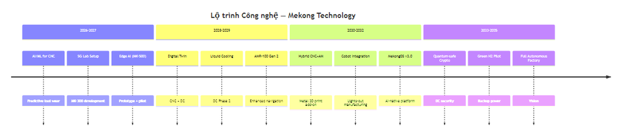

Diagram 11

[output not shown]

> **Kết luận PHẦN I:** Với TAM tổng hợp 3 ngành > 100 tỷ USD (ASEAN), market share mục tiêu Y10 chỉ 0,4-1,1% SOM, rào cản gia nhập cao (KCNC + certifications + 3 B.U integration), và dự báo xu hướng công nghệ thuận lợi, Mekong Technology có vị trí thuận lợi để đạt revenue 19,50M USD vào Y10 và steady-state ~21M USD/năm từ Y12 [A][C]. Lộ trình 5 giai đoạn xây dựng (Y0-Y8) cho phép triển khai tuần tự, giảm rủi ro vốn. Rủi ro lớn nhất là execution risk (triển khai đúng tiến độ, đúng chất lượng) chứ không phải market risk.

# PHẦN II: SẢN PHẨM VÀ CÔNG NGHỆ

## 2.1. Tổng quan 3 Trụ cột Sản phẩm

Mekong Technology vận hành 3 trụ cột sản phẩm và dịch vụ công nghệ cao, tạo thành một hệ sinh thái tích hợp phục vụ đồng thời nhu cầu nội bộ và thị trường bên ngoài:

[output not shown]

[output not shown]

*[A — Doanh thu BMS/SCADA (dong 11-15) la uoc tinh giai doan on dinh (tu nam 12+), dua tren gia ban muc tieu va quy mo thi truong BMS VN. CNC quy mo tinh gon (6 may, ISO 9001) nen doanh thu CNC chi 2,50M/nam. GPU Phase 2 chuyen sang lease.]*

## 2.2. Trụ cột 1 — Sản xuất IoT Gateway và Robot Tự hành

#### So do He sinh thai San pham IoT/BMS Mekong — Kien truc 5 Tang

[figure not shown]

Diagram 12

**So sanh He sinh thai Mekong voi Doi thu Quoc te:**

| Tang | San pham Mekong | So luong SP | Doi thu tuong ung | Gia tri khac biet Mekong |
| --- | --- | --- | --- | --- |
| Tang 5: Cloud | MekongOS Cloud, MekongBMS SaaS | 2 | Siemens Navigator, Schneider EcoStruxure Cloud | Tieng Viet, gia thap 60-70% |
| Tang 4: Phan mem | MekongBMS, MekongSCADA, MekongET | 3 | Siemens Desigo CC, Schneider EBO, Honeywell Niagara | Chay tren DDC (khong can server rieng) |
| Tang 3: Gateway | MK-200, MK-300, MK-GW-BAC/MOD/KNX/DALI | 6 | Loytec, HMS Anybus, Intesis, Weinzierl | 1 hang cung cap tat ca gateway |
| Tang 2: Controller | MK-DDC-24/64, MK-EIO (5 loai) | 7 | Siemens PXC, Schneider AS-P, Honeywell Spyder | DDC-64 = platform MK-200 (toi uu R&D) |
| Tang 1: Field | (Cam bien ben thu 3 + Robot AMR/AGV/OHT cua Mekong) | 3 (Robot) | Geek+, HIK Robot, MiR | Mekong la hang DUY NHAT co robot + BMS |
| **Tong** | **21 san pham IoT/BMS** | **21** |  |  |

> **Gia tri cot loi:** Trong khi Siemens, Schneider, Honeywell moi hang chi manh o 1-2 tang, Mekong cung cap **TOAN BO 5 tang** bang san pham cua minh — tao ra he sinh thai khep kin, khach hang khong can mua tu nhieu hang. Dong thoi, Robot AMR/AGV/OHT (Tang 1) la san pham ma KHONG doi thu BMS nao co — loi the doc nhat.

### 2.2.1. IoT Gateway — Dòng sản phẩm MK-200 và MK-300

#### Tổng quan Sản phẩm

IoT Gateway là thiết bị trung gian kết nối giữa các cảm biến/thiết bị tại nhà máy với hệ thống quản lý đám mây, đóng vai trò “bộ não biên” (Edge Brain) cho chuyển đổi số doanh nghiệp sản xuất.

| Thông số | MK-200 Standard | MK-300 AI Edge |
| --- | --- | --- |
| **Vi xử lý** | ARM Cortex-A53, 4 nhân, 1,8 GHz | ARM Cortex-A78, 8 nhân, 2,8 GHz + NPU 6 TOPS |
| **Bộ nhớ** | 4 GB LPDDR4 + 32 GB eMMC | 8 GB LPDDR5 + 64 GB eMMC + microSD |
| **Kết nối** | WiFi 6, BLE 5.2, 4G LTE, Ethernet 1Gbps, RS485/RS232 | WiFi 6E, BLE 5.3, 5G Sub-6, Ethernet 2.5Gbps, RS485/RS232/ CAN bus |
| **I/O** | 25 (12 DI, 8 DO, 3 AI, 2 AO) | 35 (16 DI, 10 DO, 5 AI, 4 AO) |
| **Giao thức** | MQTT, OPC UA, Modbus RTU/TCP, HTTP/REST | MQTT, OPC UA, Modbus, EtherCAT, PROFINET, HTTP, gRPC |
| **AI tại biên** | Không | Có — Vision AI (phát hiện lỗi, đếm sản phẩm), Predictive maintenance |
| **Camera** | Không | 1 camera 5MP AI tích hợp (tùy chọn) |
| **Bảo vệ** | IP65, chịu nhiệt -10°C đến 60°C | IP67, chịu nhiệt -20°C đến 70°C, chống rung IEC 60068 |
| **Nguồn** | 12-48V DC, 8W | 12-48V DC, 15W, PoE++ |
| **Kích thước** | 180 × 120 × 45 mm | 220 × 150 × 55 mm |
| **Bảo mật** | TLS 1.3, TPM 2.0 | TLS 1.3, TPM 2.0, Secure Boot, OTA encrypted |
| **Giá bán** | 800-1.200 USD | 1.500-2.500 USD |
| **Thị trường** | DNNVV, nhà máy cỡ vừa | Nhà máy FDI, bán dẫn, ô tô, logistics |

#### Xử lý và Sản xuất

Quy trình sản xuất IoT Gateway tại Khối C (SMT): 1. **Sản xuất PCB (in-house SMT):** Paste printing → SPI → Component placement → Reflow soldering → AOI → X-ray (BGA) → Manual rework 2. **Lắp ráp hệ thống:** PCB + Vỏ (CNC machined tại Khối B) + Antenna + Connector → Assembly 3. **Kiểm tra:** Functional test → EMC pre-compliance → Environmental stress screen → Final QC 4. **Firmware:** Flash firmware MekongOS Agent → Calibration → Pairing test → Packaging

Công suất sản xuất: 5.000 thiết bị/năm (MK-200: 3.000, MK-300: 2.000), hoạt động 1 ca [C].

#### Ứng dụng Tiêu biểu

| Ngành | Ứng dụng | Sản phẩm | Số lượng ước/KH/năm |
| --- | --- | --- | --- |
| Sản xuất điện tử | Giám sát OEE, SPC tự động | MK-300 | 10-20 |
| Kho vận, Logistics | Theo dõi hàng hóa, fleet management | MK-200 | 20-50 |
| Dệt may | Đo đếm sản phẩm, giám sát năng suất | MK-200 | 30-80 |
| Thực phẩm, Dược phẩm | Giám sát nhiệt độ/độ ẩm, HACCP | MK-200 | 10-30 |
| Bán dẫn | EES (Equipment Engineering System) integration | MK-300 | 5-10 |
| Ô tô | Andon, Poka-yoke tự động | MK-300 | 5-15 |
| Toa nha thuong mai | BMS: giam sat HVAC, chieu sang, thang may | MK-200 + DDC | 50-100 |
| Nha may san xuat | SCADA: giam sat day chuyen, dieu khien tu dong | MK-300 + DDC | 30-60 |

> **Ghi chu mo rong he san pham IoT/BMS:** Mekong Technology bo sung he san pham dieu khien toa nha (BMS) va giam sat cong nghiep (SCADA), bao gom: Module I/O mo rong (MK-EIO), Bo dieu khien DDC (MK-DDC), Gateway chuyen dung (MK-GW), va Nen tang phan mem MekongBMS/MekongSCADA. Cac san pham nay giup Mekong chuyen tu “nha cung cap Gateway thu thap du lieu” thanh “nha cung cap TOAN BO he thong dieu khien toa nha va nha may” — canh tranh truc tiep voi Siemens, Schneider, Honeywell tai phan khuc tam trung Viet Nam.

### 2.2.2. He san pham Expansion I/O (Dong MK-EIO)

#### Ly do Can Thiet

IoT Gateway MK-200/MK-300 hien co tich hop 25-35 diem I/O (Digital Input/Output, Analog Input/Output) co dinh tren board. Con so nay du cho cap do “giam sat” (monitoring) mot cum may trong nha may. Tuy nhien, khi trien khai he thong BMS (Building Management System) cho 1 tang toa nha thuong mai dien hinh, so diem do/dieu khien can thiet len toi 200-500 diem [B — tieu chuan ASHRAE 90.1]:

- He thong HVAC (dieu hoa khong khi): 80-120 diem/tang (nhiet do, do am, ap suat, van, quat, chiller)
- He thong chieu sang: 40-80 diem/tang (cong tac, dim, cam bien hien dien, cam bien anh sang)
- He thong dien: 20-40 diem/tang (dong ho dien, CB, UPS, ATS)
- He thong nuoc: 10-20 diem/tang (dong ho nuoc, bom, van, muc nuoc)
- He thong PCCC/bao chay: 30-60 diem/tang (dau bao, nut nhan, coi, van sprinkler)
- He thong thang may/thang cuon: 10-20 diem/tang

**Tong cong: 190-340 diem dieu khien cho 1 tang toa nha** — vuot xa kha nang 25-35 I/O co dinh cua MK-200.

Giai phap: Module I/O mo rong (Expansion I/O) ket noi qua bus RS485 voi Gateway hoac DDC Controller, cho phep mo rong len hang tram — hang nghin diem dieu khien tu 1 bo dieu khien trung tam. Day la kien truc chuan cua moi he thong BMS/SCADA tren the gioi (Siemens Desigo, Schneider EcoStruxure, Honeywell Niagara deu hoat dong theo nguyen tac nay).

#### Tong quan Dong san pham MK-EIO

| Ma san pham | Loai | So kenh | Giao tiep | Gia muc tieu (USD) | Doi thu tham chieu |
| --- | --- | --- | --- | --- | --- |
| MK-EIO-DI16 | Digital Input 16ch | 16 | RS485 Modbus RTU + BACnet MS/TP | 80-120 [A] | Siemens PXA30-T (~250 USD) |
| MK-EIO-DO16 | Digital Output 16ch | 16 | RS485 Modbus RTU + BACnet MS/TP | 90-130 [A] | Schneider I/O module (~200 USD) |
| MK-EIO-AI8 | Analog Input 8ch | 8 | RS485 Modbus RTU + BACnet MS/TP | 100-150 [A] | Honeywell XL50 I/O (~220 USD) |
| MK-EIO-AO4 | Analog Output 4ch | 4 | RS485 Modbus RTU + BACnet MS/TP | 80-120 [A] | Delta DVP-06XA (~150 USD) |
| MK-EIO-UI8 | Universal Input 8ch | 8 | RS485 Modbus RTU + BACnet MS/TP | 120-180 [A] | Siemens PXA40-T (~300 USD) |

*[A — Gia muc tieu dua tren BOM cost + margin 40-50%, thap hon doi thu 40-60%]*

#### Chi tiet Ky thuat Tung Module

**a) MK-EIO-DI16 — Expansion Digital Input 16 kenh**

| Thong so | Gia tri | Ghi chu |
| --- | --- | --- |
| **MCU** | STM32F407VG (ARM Cortex-M4, 168 MHz) | Dung MCU pho bien, chuoi cung ung on dinh |
| **Input** | 16 kenh 24VDC (sink/source co the cau hinh) hoac Dry Contact | Tuong thich cam bien cong nghiep chuan |
| **Diem dem xung** | Co — Pulse counting 4 kenh (max 10 kHz) | Cho dong ho nuoc, dong ho dien, encoder |
| **Giao tiep** | RS485 Modbus RTU + BACnet MS/TP (dual protocol, chon bang DIP switch) | Tuong thich ca PLC lan BMS |
| **Toc do bus** | 9.600 — 115.200 bps (cau hinh) | Mac dinh 38.400 bps theo BACnet |
| **Dia chi** | 1-247 (Modbus) hoac 1-127 (BACnet) | Cau hinh bang DIP switch hoac phan mem |
| **LED** | 16 LED trang thai kenh (xanh = ON, tat = OFF) + 1 LED Power + 1 LED Comm | Hien thi truc quan, de chuan doan |
| **Nguon** | 24VDC (+/-10%), cong suat < 3W | Dung chung nguon 24V cua tu dien |
| **Bao ve** | Isolation 2,5 kV (optocoupler), TVS tren moi kenh, chong set cap 2 | An toan cho moi truong cong nghiep |
| **Nhiet do hoat dong** | -20 den +60 do C | Phu hop tu dieu hoa den nha may |
| **Do am** | 5-95% RH (khong ngung tu) |  |
| **Kich thuoc** | 120 x 70 x 50 mm |  |
| **Lap dat** | DIN rail 35 mm, ket noi daisy-chain RS485 (toi da 32 module/bus) | Chuan tu dien cong nghiep |
| **Xuat xu** | Thiet ke va san xuat tai Viet Nam (KCNC TP.HCM) |  |

**b) MK-EIO-DO16 — Expansion Digital Output 16 kenh**

| Thong so | Gia tri | Ghi chu |
| --- | --- | --- |
| **MCU** | STM32F407VG (dung chung platform voi DI16) | Toi uu hoa san xuat |
| **Output** | 16 kenh, 2 che do: Relay 5A/250VAC hoac Transistor 0,5A/24VDC | Relay cho van/bom, Transistor cho tin hieu |
| **PWM** | Co — 4 kenh PWM (1-10 kHz) | Dieu khien van tuyen tinh, damper, dim den |
| **Bao ve output** | Fuse 6A/kenh (Relay), TVS + flyback diode (Transistor) | Chong qua tai, chong nguoc |
| **Giao tiep** | RS485 Modbus RTU + BACnet MS/TP (dual protocol) | Nhu DI16 |
| **LED** | 16 LED trang thai output + Power + Comm |  |
| **Nguon** | 24VDC, < 5W (khong tinh tai) |  |
| **Lap dat** | DIN rail, daisy-chain RS485 |  |
| **Gia muc tieu** | 90-130 USD [A] | Siemens tuong duong: 200-300 USD |

**c) MK-EIO-AI8 — Expansion Analog Input 8 kenh**

| Thong so | Gia tri | Ghi chu |
| --- | --- | --- |
| **MCU** | STM32F407VG + ADC ngoai ADS1278 (8ch, 24-bit) | Do chinh xac cao cho do nhiet do, ap suat |
| **Input** | 8 kenh, moi kenh cau hinh doc lap: 0-10V / 4-20mA / PT100 / PT1000 / NTC 10K | Da nang — 1 module thay 3 loai |
| **Do phan giai** | 16-bit hieu dung (tu 24-bit voi oversampling + filter) | Tuong duong Siemens/Schneider |
| **Do chinh xac** | ±0,1% FS (Full Scale) tai 25 do C | Dat chuan cong nghiep |
| **Toc do lay mau** | 10 Hz/kenh (mac dinh), toi da 100 Hz/kenh | Du cho BMS, nhanh cho SCADA |
| **Bao ve** | Isolation 2,5 kV, TVS, chong set |  |
| **Giao tiep** | RS485 Modbus RTU + BACnet MS/TP |  |
| **Nguon** | 24VDC, < 4W |  |
| **Gia muc tieu** | 100-150 USD [A] | Honeywell tuong duong: 220-350 USD |

**d) MK-EIO-AO4 — Expansion Analog Output 4 kenh**

| Thong so | Gia tri | Ghi chu |
| --- | --- | --- |
| **MCU** | STM32F407VG + DAC AD5754R (4ch, 16-bit) |  |
| **Output** | 4 kenh, moi kenh cau hinh: 0-10V hoac 4-20mA (chon bang phan mem) | Dieu khien van, bo dieu toc VFD, actuator |
| **Do phan giai** | 16-bit | Mim, chinh xac cho dieu khien PID |
| **Do chinh xac** | ±0,1% FS |  |
| **Drive capability** | 0-10V: tai > 2 kOhm; 4-20mA: tai < 500 Ohm | Du cho day cap 500m |
| **Giao tiep** | RS485 Modbus RTU + BACnet MS/TP |  |
| **Nguon** | 24VDC, < 3W |  |
| **Gia muc tieu** | 80-120 USD [A] | Delta tuong duong: 150-200 USD |

**e) MK-EIO-UI8 — Universal Input 8 kenh**

| Thong so | Gia tri | Ghi chu |
| --- | --- | --- |
| **MCU** | STM32F407VG + multiplexer + ADC ADS1278 |  |
| **Input** | 8 kenh, moi kenh TU DONG NHAN DIEN tin hieu: DI (24VDC), AI Voltage (0-10V), AI Current (4-20mA), Resistance (PT100/PT1000/NTC) | San pham doc quyen Mekong |
| **Auto-sensing** | Firmware tu dong do tro khang, dien ap, dong dien de xac dinh loai tin hieu | Giam 80% thoi gian cau hinh |
| **Do chinh xac** | ±0,15% FS (AI mode), ±0,5 do C (RTD mode) |  |
| **Giao tiep** | RS485 Modbus RTU + BACnet MS/TP |  |
| **Nguon** | 24VDC, < 5W |  |
| **Gia muc tieu** | 120-180 USD [A] | Siemens PXA40-T: 300-400 USD |
| **Loi the** | Giam so luong module can mua — 1 UI8 thay cho 1 DI + 1 AI | Tiet kiem chi phi va khong gian tu dien |

#### Kien truc Ket noi I/O Mo rong

[output not shown]

> **So sanh:** Voi Siemens Desigo PXC, cau hinh tuong tu (9 module I/O + 1 controller) co gia 4.000-6.000 USD. Voi Mekong (9 x MK-EIO ~100 USD + 1 MK-DDC-24 ~350 USD), tong chi phi chi 1.250-1.550 USD — **tiet kiem 60-75%** [C].

#### San xuat va Dong bo Day chuyen

Module MK-EIO san xuat tren **cung day chuyen SMT Panasonic NPM-D3** da dung de san xuat IoT Gateway MK-200/MK-300. Quy trinh tuong tu: 1. PCB Paste printing (cung may in) 2. SMT placement (cung NPM-D3, chi doi chuong trinh) 3. Reflow soldering (cung lo Reflow) 4. AOI kiem tra (cung may AOI) 5. DIP soldering: Han Relay/Connector qua lo (chi co o DO16) 6. ICT/Functional test → Flash firmware → Dong goi

### 2.2.3. Bo dieu khien DDC cho BMS (Dong MK-DDC)

#### Tong quan

DDC (Direct Digital Controller) la “bo nao” cua he thong BMS, chiu trach nhiem dieu khien truc tiep cac he thong ky thuat trong toa nha: HVAC (Heating, Ventilation, Air Conditioning), chieu sang, thang may, bom nuoc, PCCC… Moi tang hoac moi khu vuc cua toa nha co 1-2 DDC controller, ket noi voi cac module I/O de doc cam bien va dieu khien thiet bi.

DDC la san pham co gia tri cao nhat trong he sinh thai BMS vi: - La thiet bi BAT BUOC trong moi du an BMS (khong the thieu) - Khach hang bi “lock-in” vao hang san xuat DDC (kho chuyen doi) - Doanh thu bao tri, nang cap firmware, ho tro ky thuat theo DDC - Bien loi nhuan cao: 50-60% gross margin (vi firmware la gia tri chinh)

#### Hai dong san pham MK-DDC

[output not shown]

#### Diem Then Chot: MK-DDC-64 Dung Lai Platform MK-200

Day la yeu to quyet dinh tinh kha thi cua du an BMS/SCADA:

[output not shown]

**Ket luan:** MK-DDC-64 tai su dung ~60-70% phan cung va ~40% phan mem tu MK-200. Chi phi R&D phu troi chi la thiet ke I/O board moi + phat trien firmware BACnet + lap trinh IEC 61131-3 runtime — uoc tinh 120K USD va 12-18 thang [A].

#### Ung dung Tieu bieu DDC

| Ung dung | San pham DDC | So diem dieu khien | Giai phap |
| --- | --- | --- | --- |
| AHU Control (1 AHU) | MK-DDC-24 | 18-24 | Do nhiet do, do am, ap suat → Dieu khien van nuoc lanh, quat, damper |
| Chiller Plant (1 cum Chiller) | MK-DDC-24 + 4x EIO | 60-80 | Dieu khien 2-3 chiller, bom nuoc lanh, cooling tower |
| BMS 1 tang van phong | MK-DDC-64 + 8x EIO | 150-200 | HVAC + chieu sang + dien + nuoc + bao chay |
| BMS toa nha 10 tang | 10x MK-DDC-24 + 1x MK-DDC-64 (server) | 1.500-2.500 | Moi tang 1 DDC-24, DDC-64 lam trung tam |
| SCADA nha may | 2x MK-DDC-64 + 20x EIO | 500-1.000 | Giam sat day chuyen, dieu khien tu dong |

### 2.2.4. Gateway Chuyen dung (Dong MK-GW)

#### Tong quan

Trong mot toa nha hoac nha may hien dai, co rat nhieu giao thuc truyen thong khac nhau cung ton tai: BACnet (BMS), Modbus (dien, nuoc, HVAC), KNX (chieu sang, rem cua), DALI (dieu khien den), PROFINET (PLC cong nghiep), EtherCAT (servo/robot)… Cac gateway chuyen dung la “phien dich vien” ket noi cac he thong nay vao 1 nen tang quan ly duy nhat.

Hien nay, khach hang phai mua 5-6 gateway tu 5-6 hang khac nhau (Intesis, Loytec, HMS, Weinzierl…) de tich hop. Mekong cung cap dong san pham gateway thong nhat, giao dien cau hinh giong nhau, giam thoi gian commissioning 40-60%.

#### 4 San pham Gateway MK-GW

**a) MK-GW-BAC — BACnet Router/Gateway**

| Thong so | Gia tri | Ghi chu |
| --- | --- | --- |
| **Chuc nang** | BACnet MS/TP ←→ BACnet IP ←→ BACnet/SC (Secure Connect) | Router 3 lop BACnet |
| **Cong** | 2x RS485 (MS/TP, 128 device/bus) + 2x Ethernet (IP) | Du cho 2 bus RS485 |
| **BBMD** | Co — BACnet Broadcast Management Device | Ket noi BACnet qua subnet |
| **Cau hinh** | Web-based (HTML5), khong can phan mem rieng | Truy cap bang trinh duyet |
| **CPU** | ARM Cortex-M7 (STM32H7) |  |
| **Nguon** | 24VDC hoac PoE (802.3af) | Linh hoat lap dat |
| **Gia muc tieu** | 150-250 USD [A] | Loytec L-ROC: 400-600 USD |

**b) MK-GW-MOD — Modbus Multi-port Gateway**

| Thong so | Gia tri | Ghi chu |
| --- | --- | --- |
| **Chuc nang** | 4x RS485 Modbus RTU → Modbus TCP + OPC UA + BACnet IP | Chuyen doi thiet bi cu vao he thong moi |
| **Cong RS485** | 4 cong doc lap (moi cong 32 slave, tong 128 thiet bi) | Nhieu hon doi thu (thuong 1-2 cong) |
| **Protocol mapping** | Cau hinh bang template (co san 100+ template cho dong ho, VFD, PLC) | Giam 70% thoi gian cau hinh |
| **CPU** | ARM Cortex-A55 (dua tren platform MK-200 lite) |  |
| **Gia muc tieu** | 120-200 USD [A] | HMS Anybus: 250-400 USD |
| **Ung dung** | Ket noi dong ho dien Schneider/ABB, VFD Danfoss, PLC Siemens vao BMS |  |

**c) MK-GW-KNX — KNX/IP Gateway**

| Thong so | Gia tri | Ghi chu |
| --- | --- | --- |
| **Chuc nang** | KNX TP (Twisted Pair) ←→ KNX/IP ←→ BACnet IP | Tich hop chieu sang thong minh vao BMS |
| **KNX** | 1 line KNX TP (64 device), KNX/IP tunneling |  |
| **BACnet** | BACnet IP server, expose KNX datapoint thanh BACnet object | Tu dong map |
| **Cau hinh** | Web-based + ETS plugin (phan mem KNX chuan) | Tuong thich he sinh thai KNX |
| **Gia muc tieu** | 200-350 USD [A] | Weinzierl KNX IP: 350-500 USD |
| **Ung dung** | Toa nha co he thong chieu sang KNX (Zumtobel, JUNG, Gira) muon tich hop vao BMS Mekong |  |

**d) MK-GW-DALI — DALI-2 Lighting Gateway**

| Thong so | Gia tri | Ghi chu |
| --- | --- | --- |
| **Chuc nang** | Dieu khien 2 line DALI-2 (64 den/line = 128 den tong) | Thay the DALI controller doc lap |
| **Interface** | BACnet IP + MQTT + REST API | Tich hop vao BMS hoac IoT Cloud |
| **Chuc nang nang cao** | Scheduling (lich hen), Daylight harvesting (tu dong dim theo anh sang), Occupancy control (cam bien hien dien), Emergency lighting test | Day du tinh nang DALI-2 Application Controller |
| **Nguon DALI** | Tich hop PSU 250mA cho moi line DALI | Khong can nguon DALI ngoai |
| **Gia muc tieu** | 180-300 USD [A] | Tridonic DALI Gateway: 300-500 USD |
| **Ung dung** | Toa nha van phong, khach san, benh vien can dieu khien chieu sang thong minh |  |

#### Gia tri Cua Dong Gateway Thong nhat

| Kich ban | Khong co Mekong GW | Co Mekong GW | Tiet kiem |
| --- | --- | --- | --- |
| Toa nha co BACnet + Modbus + KNX + DALI | Mua 4 gateway tu 4 hang (~2.000 USD), 4 giao dien cau hinh khac nhau, 4 hop dong bao tri | 4 gateway Mekong (~800 USD), giao dien thong nhat, 1 hop dong bao tri | ~60% chi phi, 70% thoi gian |
| Nha may co 50 dong ho Modbus + 10 PLC | 2 gateway HMS (~700 USD), gioi han 64 thiet bi/gateway | 1 MK-GW-MOD (~180 USD), ho tro 128 thiet bi | ~75% chi phi |

### 2.2.5. Nen tang Phan mem MekongBMS / MekongSCADA

#### Tong quan

Hien tai MekongOS (phan 2.2.9) la nen tang IoT Cloud — tap trung vao **giam sat** (monitoring) thiet bi IoT va robot. De tro thanh nha cung cap BMS/SCADA toan dien, Mekong phat trien them 3 san pham phan mem:

| San pham | Phan khuc | Mo ta | Mo hinh ban |
| --- | --- | --- | --- |
| **MekongBMS** | Toa nha thuong mai | Phan mem quan ly toa nha (Building Management Software) | License per-point + SaaS |
| **MekongSCADA** | Nha may cong nghiep | Phan mem giam sat va dieu khien nha may (SCADA) | License per-tag + On-premise |
| **MekongET** | Ky su BMS/SCADA | Cong cu cau hinh, lap trinh, commissioning DDC va I/O | Mien phi (di kem san pham) |

#### a) MekongBMS — Phan mem Quan ly Toa nha

**Kien truc Ky thuat:**

| Tang | Thanh phan | Cong nghe | Ghi chu |
| --- | --- | --- | --- |
| **Tang 5: Dashboard** | Giao dien web, do hoa mat bang, bao cao | React + WebGL + Canvas | HTML5, khong can cai client |
| **Tang 4: Logic & Alarm** | Alarm management, scheduling, trending | Node.js + PostgreSQL | Rule engine cau hinh bang GUI |
| **Tang 3: API & Integration** | RESTful API, MQTT broker, OPC UA client | Go + EMQX + open62541 | Tich hop ERP, Lighting, CCTV |
| **Tang 2: Protocol Driver** | BACnet IP/MS-TP driver, Modbus driver | C/C++ + BACnet stack | Stack BACnet open-source (bacnet-stack.sf.net) |
| **Tang 1: Database** | Time-series DB (trend data), Config DB | TimescaleDB + PostgreSQL | Luu tru du lieu lich su |

**Tinh nang Chi tiet:**

| Tinh nang | Mo ta | Loi the so voi doi thu |
| --- | --- | --- |
| **Graphic Editor** | Ve so do mat bang (floor plan), P&ID, keo tha thiet bi | WYSIWYG, vay moi ky su VN deu su dung duoc |
| **Alarm Management** | Phan loai alarm (Critical/Major/Minor), escalation, SMS/email/push | Thong bao bang tieng Viet, phan quyen theo vai tro |
| **Trend Logging** | Luu du lieu lich su (1 phut/diem), ve do thi, xuat Excel/CSV | Luu tru tren MekongOS Cloud (khong gioi han dung luong) |
| **Scheduling** | Lich dieu khien HVAC/den theo gio/ngay/mua/ngay le | Lich Viet Nam co san (Tet, le 30/4…) |
| **Report tự dong** | Tao bao cao PDF/Excel tu dong (nang luong, su co, hieu suat) | Template bao cao tieng Viet chuan |
| **Multi-site** | Quan ly nhieu toa nha tu 1 giao dien | Cho nha quan ly BDS, tap doan |
| **Tieng Viet 100%** | Giao dien, bao cao, alarm deu bang tieng Viet | Doi thu (Siemens, Schneider, Honeywell): KHONG co tieng Viet |
| **Mobile App** | iOS + Android (React Native) | Nhan alarm, xem dashboard tren dien thoai |
| **AI Energy** | Du doan tieu thu nang luong, de xuat tiet kiem | Tich hop AI tu MekongOS Engine |

**Mo hinh Ban hang:**

| Goi | So diem BMS | Gia license (USD) | Gia SaaS/thang (USD) | Doi tuong |
| --- | --- | --- | --- | --- |
| Starter | 1-200 | 1.500 | 200 | Toa nha nho, mat bang ban le |
| Professional | 201-1.000 | 5.000 | 500 | Toa nha van phong, khach san |
| Enterprise | 1.001-5.000 | 15.000 | 800 | Toa nha lon, BV, truong hoc |
| Campus | 5.001-20.000 | Thuong luong | 1.500 | Khu do thi, tap doan, campus |

**Diem Khac Biet Lon:** MekongBMS chay duoc tren MK-DDC-64 (on-premise, khong can may chu rieng) **HOAC** tren MekongOS Cloud (SaaS) — khach hang tu chon. Doi thu nhu Siemens Desigo dan can may chu Windows rieng, tang chi phi 3.000-5.000 USD.

#### b) MekongSCADA — Phan mem Giam sat Cong nghiep

| Tinh nang | Mo ta |
| --- | --- |
| **Giao thuc** | OPC UA, Modbus TCP/RTU, PROFINET, EtherCAT, BACnet, MQTT |
| **Tag capacity** | 10.000-100.000 tag (tuy license) |
| **HMI** | Web-based, SVG graphics, P&ID interactive |
| **Historian** | TimescaleDB, luu tru 5+ nam, compression 10:1 |
| **AI tich hop** | Predictive maintenance (du doan hong hoc), anomaly detection (phat hien bat thuong), energy optimization |
| **Digital Twin** | Mo phong day chuyen san xuat, toi uu hoa throughput |
| **Reporting** | Bao cao nang luong ISO 50001, OEE, SPC |
| **Gia muc tieu** | 3.000-20.000 USD tuy quy mo [A] |

*[A — Wonderware InTouch: 15.000-50.000 USD, Ignition: 5.000-30.000 USD. Mekong dinh vi phan khuc tam trung]*

#### c) MekongET — Engineering Tool

| Tinh nang | Mo ta |
| --- | --- |
| **Device Discovery** | Tu dong tim DDC va I/O tren mang RS485/IP |
| **Logic Programming** | Function Block Diagram (FBD) + Structured Text (ST) theo IEC 61131-3 |
| **Script Editor** | Python scripting cho logic phuc tap |
| **Commissioning** | Override output, force input, trend real-time |
| **Firmware Update** | OTA (qua Ethernet/WiFi) hoac USB |
| **Backup/Restore** | Sao luu cau hinh DDC, khoi phuc nhanh |
| **Gia** | Mien phi (di kem moi DDC controller) |

> **Chien luoc:** MekongET mien phi de giam rao can su dung — giong mo hinh Schneider EcoStruxure Machine Expert Basic (mien phi) nhung Mekong cung cap cho BMS (doi thu thu 500-2.000 USD cho engineering tool).

### 2.2.6. Robot AMR-500 va AMR-1000

#### Tổng quan Sản phẩm

Robot AMR (Autonomous Mobile Robot) là robot tự hành di động, sử dụng trí tuệ nhân tạo để tự xác định vị trí và di chuyển trong nhà máy mà KHÔNG cần dải từ, dây dẫn hay đánh dấu sàn — khác biệt hoàn toàn so với AGV truyền thống.

| Thông số | AMR-500 | AMR-1000 |
| --- | --- | --- |
| **Tải trọng** | 500 kg | 1.000 kg |
| **Navigation** | LiDAR 3D 360° + Camera AI + IMU + Odometry | LiDAR 3D 360° + Camera AI + IMU + UWB Anchor |
| **Thuật toán** | AI SLAM (Simultaneous Localization and Mapping) — huấn luyện trên GPU NVIDIA (Khối A) | AI SLAM + Deep reinforcement learning |
| **Tốc độ** | 0-1,5 m/s | 0-1,2 m/s |
| **Độ chính xác** | ±10 mm | ±10 mm |
| **Truyền thông** | WiFi 6 + BLE 5.2, REST API, ROS2 compatible | WiFi 6 + BLE 5.3 + 5G, REST API, ROS2 |
| **Pin** | LiFePO4 48V/60Ah, thời gian hoạt động 8 giờ | LiFePO4 48V/100Ah, thời gian hoạt động 6 giờ |
| **Sạc** | Tự động docking, sạc nhanh 1,5 giờ | Tự động docking, sạc nhanh 2 giờ |
| **An toàn** | LiDAR safety scanner (ISO 13849 PLd), Emergency stop, Bumper sensor | Dual LiDAR safety, ISO 13849 PLe, Emergency stop |
| **Phụ kiện** | Roller conveyor top module, Lifting module | Roller conveyor, Lifting module, Hook towing module |
| **Kích thước** | 800 × 600 × 350 mm (không tải) | 1.000 × 700 × 400 mm (không tải) |
| **Khối lượng bản thân** | 120 kg | 180 kg |
| **Giá bán** | 18.000-25.000 USD | 28.000-38.000 USD |

#### Quy trình Sản xuất Robot AMR

1. **Thiết kế cơ khí (CAD/CAM):** Thiết kế 3D trên SolidWorks/Mastercam → Mô phỏng FEM → Xuất toolpath cho CNC
2. **Chế tạo khung (CNC tại Khối B):** Phay CNC khung nhôm 6061-T6, bệ gá sensor, tấm đáy → Anodizing → QC kích thước CMM
3. **Lắp ráp PCB điều khiển (SMT tại Khối C):** Board chính (ARM + Motor driver) → Board sensor → Board power management
4. **Lắp ráp tổng (Assembly Line tại Khối C):**
   - Khung + Motor + Bánh xe + Encoder
   - LiDAR + Camera + IMU + UWB (tùy phiên bản)
   - Pin LiFePO4 + BMS
   - PCB điều khiển + Wiring harness
   - Vỏ ngoài + Safety scanner
5. **Huấn luyện AI (GPU tại Khối A):** AI SLAM model → Sim-to-Real transfer → Field calibration
6. **Kiểm tra:** Accuracy test → Battery cycle test → EMC → Drop test → 72h burn-in → Acceptance test

> **Mối liên kết Hệ sinh thái:** Robot AMR là sản phẩm minh chứng rõ nhất cho giá trị tích hợp 3 trụ cột — Khung CNC từ Khối B, PCB SMT từ Khối C, AI training từ Khối A, và giám sát qua MekongOS từ Cloud.

### 2.2.7. Robot AGV-500 va AGV-1000

Robot AGV (Automated Guided Vehicle) là phiên bản dẫn đường tự động với chi phí thấp hơn AMR, phù hợp cho các tuyến vận chuyển cố định trong nhà máy:

| Thông số | AGV-500 | AGV-1000 |
| --- | --- | --- |
| **Tải trọng** | 500 kg | 1.000 kg |
| **Navigation** | Vision-based + Magnetic tape (backup) | Vision + LiDAR 2D + Magnetic tape |
| **Tốc độ** | 0-1,0 m/s | 0-0,8 m/s |
| **Độ chính xác** | ±5 mm (trên line) | ±5 mm |
| **Giá bán** | 12.000-18.000 USD | 20.000-28.000 USD |
| **Ưu điểm** | Chi phí thấp, dễ triển khai | Tải nặng, phù hợp heavy industry |

Công suất sản xuất Robot AGV: 100 bộ/năm (1 ca) [C].

### 2.2.8. Robot OHT-100

Robot OHT (Overhead Hoist Transport) là hệ thống vận chuyển trên cao chuyên dụng cho nhà máy bán dẫn, vận chuyển wafer cassette (FOUP) giữa các tool trong clean room:

| Thông số | OHT-100 |
| --- | --- |
| **Tải trọng** | 100 kg (2 FOUP) |
| **Rail** | Dual rail overhead (trần), chiều cao 2,5-4 m |
| **Trục** | 4 trục (X, Y, Z, Theta) |
| **Tốc độ** | X/Y: 0-2,0 m/s, Z: 0-0,3 m/s |
| **Độ chính xác** | ±0,5 mm (docking position) |
| **Clean room** | Class 100 compatible (ISO 5) |
| **Truyền thông** | SECS/GEM, EAP, WiFi, RFID |
| **Giá bán** | 45.000-65.000 USD |

### 2.2.9. MekongOS — Nen tang IoT Cloud

MekongOS là nền tảng phần mềm IoT Cloud do Mekong Technology tự phát triển, chạy trên hạ tầng Datacenter nội bộ (Khối A), cung cấp dịch vụ SaaS cho khách hàng quản lý IoT và Robot:

**Kiến trúc Hệ thống:**

[figure not shown]

Diagram 13

**Mô hình Kinh doanh SaaS:**

| Gói dịch vụ | Mô tả | Giá/tháng | Thiết bị tối đa |
| --- | --- | --- | --- |
| Starter | Dashboard cơ bản, 5 widget, lưu trữ 30 ngày | 99 USD | 10 |
| Professional | Dashboard tùy chỉnh, AI alert, lưu trữ 90 ngày | 299 USD | 50 |
| Enterprise | Full AI, Digital Twin, API, lưu trữ 1 năm, SLA 99,9% | 999 USD | 500 |
| Custom | Theo yêu cầu, on-premise option | Thương lượng | Không giới hạn |

## 2.3. Trụ cột 2 — Chế tạo Cơ khí Siêu Chính xác (MPMC)

### 2.3.1. Tổng quan Năng lực Sản xuất

Trung tâm Chế tạo Linh kiện Chính xác (Mekong Precision Manufacturing Center — MPMC) là xưởng CNC tinh gọn, chuyên gia công khung robot AMR/AGV nội bộ và linh kiện chính xác cho khách hàng FDI, đạt chuẩn ISO 9001:2015.

| Thông số | Giá trị |
| --- | --- |
| **Diện tích** | 800 m² (khu CNC + QC corner, Tầng 1) |
| **Số máy CNC** | 6 máy (4x 5-trục + 2x 3-trục) |
| **Loại máy** | Phay 5 trục DMG MORI + Doosan, phay 3 trục Doosan |
| **Dung sai đạt được** | ≤ 5 micromet |
| **Độ bóng bề mặt** | Ra ≤ 0,4 micromet |
| **Vật liệu** | Nhôm 6061-T6, thép hợp kim, inox SUS304, đồng |
| **Công suất** | 3.000 chi tiết/năm (ổn định) |
| **Chứng nhận** | ISO 9001:2015 (sẵn có). IATF/AS9100 là option nâng cấp khi có nhu cầu |
| **Nhân sự** | 10-15 người |
| **Ca làm việc** | 2 ca/ngày (16 giờ effective), 6 ngày/tuần |

### 2.3.2. Danh mục Máy móc Chi tiết

| TT | Máy | Hãng | Số lượng | Giá/máy (K USD) | Tổng (K USD) | Trọng lượng/máy |
| --- | --- | --- | --- | --- | --- | --- |
| 1 | DMU 65 monoBLOCK (5 trục) | DMG MORI (Đức/Nhật) | 2 | 520 | 1.040 | 8.000 kg |
| 2 | DVF 5000 (5 trục) | Doosan (Hàn Quốc) | 2 | 385 | 770 | 6.500 kg |
| 3 | DNM 6700 (3 trục) | Doosan (Hàn Quốc) | 2 | 150 | 300 | 4.500 kg |
|  | **Tổng** |  | **6** |  | **2.110** |  |

> **Lưu ý Lead Time:** Máy CNC 5 trục DMG MORI có thời gian giao hàng 24-30 tuần từ ngày đặt PO. 2 máy 3 trục Doosan DNM 6700 chuyên gia công khung robot và chi tiết đơn giản, lead time 12-16 tuần [A].

### 2.3.3. Hệ thống QA/QC — QC Corner

Góc kiểm tra chất lượng (QC Corner) nằm trong khu CNC 800 m², trang bị thiết bị đo lường phù hợp quy mô 6 máy:

| Thiết bị | Hãng | Số lượng | Giá (K USD) | Thông số |
| --- | --- | --- | --- | --- |
| Hexagon Absolute Arm 7-trục | Hexagon (Thụy Điển) | 1 | 180-250 | Phạm vi Ø2,5 m, độ chính xác ±0,023 mm, portable |
| Máy đo nhám bề mặt SJ-210 | Mitutoyo (Nhật) | 1 | 5 | Ra, Rz, Rt measurements |
| Dụng cụ đo tay (panme, thước cặp, đồng hồ so) | Mitutoyo | Bộ | 10 | Panme 0-150 mm, thước cặp digital 0-300 mm |
| Đồ gá kiểm tra (Fixtures) | Tùy chỉnh | 10 bộ | 20-30 | Theo yêu cầu sản phẩm |
| **Tổng QA/QC** |  |  | **215-295** |  |

**Điều kiện QC Corner:** - Nhiệt độ: 22°C ± 2°C (điều hòa chung khu CNC) - Vách ngăn nhẹ tách khỏi khu vực gia công, giảm bụi và rung - Hexagon Absolute Arm là thiết bị portable — có thể đo ngay trên bàn máy khi cần - Calibration định kỳ: Mỗi 12 tháng bởi đơn vị được công nhận

### 2.3.4. Phần mềm CAD/CAM

| Phần mềm | Hãng | Số license | Chi phí/năm (K USD) | Mục đích |
| --- | --- | --- | --- | --- |
| Mastercam (Mill 3D + 5-Axis) | Mastercam / CNC Software | 6 | 60-72 | CAM chính cho gia công 3 trục và 5 trục, post-processor đi kèm |
| SolidWorks Standard (viewer) | Dassault | 2 | 8-12 | Xem và kiểm tra file CAD từ khách hàng FDI |
| **Tổng phần mềm** |  |  | **68-84** |  |

> Với 6 máy CNC, mỗi operator 1 license Mastercam là đủ. SolidWorks viewer dùng để tiếp nhận bản vẽ khách hàng. ERP xưởng CNC tích hợp vào hệ thống ERP chung của Mekong (module Manufacturing) [A].

### 2.3.5. Quy trình Gia công Tiêu biểu

**Quy trình gia công chi tiết chính xác — ISO 9001:2015:**

[figure not shown]

Diagram 14

**Thời gian chu kỳ (Lead time):** - Chi tiết đơn giản (khung robot, bracket): 1-2 tuần - Chi tiết chính xác (encoder mount, jig): 2-3 tuần - Sản phẩm mới (NPI): 4-6 tuần (bao gồm thiết kế fixture + First Article Inspection)

### 2.3.6. Sản phẩm CNC theo Phân khúc

#### A. Khung Robot AMR/AGV (Nội bộ + Xuất khẩu)

| Sản phẩm | Mô tả | Vật liệu | Dung sai | Số lượng/năm | Đơn giá (USD) |
| --- | --- | --- | --- | --- | --- |
| Khung chính AMR | Khung nhôm CNC 5 trục, tích hợp lỗ lắp sensor + motor | Al 6061-T6 | ≤ 5 µm | 500 | 400-700 |
| Khung AGV tải nặng | Khung thép hàn + CNC mặt lắp ghép | Thép S45C + Al | ≤ 10 µm | 200 | 600-1.000 |
| Bộ gá sensor (LiDAR mount) | Giá đỡ LiDAR/Camera, yêu cầu phẳng và vuông góc | Al 6061-T6 | ≤ 5 µm | 700 | 50-120 |

#### B. Linh kiện Chính xác cho FDI (Electronics / Semiconductor)

| Sản phẩm | Mô tả | Vật liệu | Dung sai | Số lượng/năm | Đơn giá (USD) |
| --- | --- | --- | --- | --- | --- |
| Encoder Bracket | Giá đỡ encoder servo, yêu cầu đồng tâm cao | Al 6061-T6 / Inox | ≤ 5 µm | 400 | 80-200 |
| Motor Mount | Đế gắn motor, mặt phẳng lắp ghép chính xác | Al 6061-T6 | ≤ 5 µm | 300 | 100-250 |
| Khớp xoay (Rotary Joint) | Khớp nối trục quay, yêu cầu độ đồng tâm | SUS304, đồng | ≤ 5 µm | 200 | 150-400 |

#### C. Jig/Fixture cho SMT và Lắp ráp

| Sản phẩm | Mô tả | Vật liệu | Dung sai | Số lượng/năm | Đơn giá (USD) |
| --- | --- | --- | --- | --- | --- |
| Pallet SMT | Đồ gá cho dây chuyền hàn SMT | Al 6061-T6 | ≤ 10 µm | 300 | 200-500 |
| Fixture kiểm tra EOL | Đồ gá test cuối dây chuyền | Al + nhựa kỹ thuật | ≤ 20 µm | 200 | 300-800 |
| Fixture lắp ráp | Đồ gá định vị cho lắp ráp thủ công/bán tự động | Al 6061 | ≤ 15 µm | 200 | 150-400 |

### 2.3.7. Doanh thu CNC theo Kịch bản

[figure not shown]

Diagram 15

| Năm | Conservative (M USD) | Base Case (M USD) | Optimistic (M USD) |
| --- | --- | --- | --- |
| 1 | 0,30 | 0,40 | 0,50 |
| 2 | 0,80 | 1,00 | 1,30 |
| 3 | 1,40 | 1,70 | 2,10 |
| 4 | 1,80 | 2,20 | 2,70 |
| 5 | 2,00 | 2,50 | 3,20 |
| **Tổng 5Y** | **6,30** | **7,80** | **9,80** |

*[C — Tính toán dựa trên 6 máy, utilization 60-85%, product mix khung robot (55%) + linh kiện FDI (30%) + jig/fixture (15%)]*

## 2.4. Trụ cột 3 — Hạ tầng Điện toán Đám mây AI (MACC)

### 2.4.1. Tổng quan Kiến trúc Datacenter

Trung tâm Hạ tầng Điện toán Đám mây Mật độ cao (Mekong AI Cloud & Computing Center — MACC) được thiết kế theo tiêu chuẩn **Uptime Institute Tier III** — Concurrently Maintainable, đảm bảo uptime 99,982% (downtime tối đa 1,6 giờ/năm).

| Thông số | Giá trị |
| --- | --- |
| **Diện tích tổng** | 2.500 m² (Tầng 2-3, Khối A) |
| **Data Hall** | 800 m² (Zone 1: 500 m² Colo, Zone 2: 300 m² AI/HPC) |
| **Tổng Rack** | 50 (Phase 1 duy nhất) |
| **Tải IT tổng** | 0,75-1,5 MW |
| **PUE mục tiêu** | < 1,35 (sau tối ưu hóa: 1,32) |
| **Cooling** | In-Row + Direct-to-Chip Liquid Cooling (Zone 2) |
| **UPS** | 2 × 800 kVA LiFePO4, 15 phút runtime |
| **Generator** | 2 × 1.500 kVA Diesel (N+1) |
| **Redundancy** | 2N Power, N+1 Cooling |
| **Tiêu chuẩn** | Uptime Tier III, ISO 27001, PCI DSS (target) |
| **Physical Security** | Mantrap, Biometric 3-factor, CCTV 24/7, Perimeter fence |

> **Phase 2 GPU:** Khi demand vượt supply (occupancy > 85%), Mekong sẽ lease thêm GPU pods từ NVIDIA DGX Cloud hoặc CoreWeave thay vì mua sắm thêm server vật lý. Chiến lược này giảm CAPEX ~9M USD so với kế hoạch mở rộng Phase 2 ban đầu [A].

### 2.4.2. Phân vùng Data Hall

| Zone | Diện tích | Racks | Tải/Rack | Cooling | Mục đích | Khách hàng |
| --- | --- | --- | --- | --- | --- | --- |
| **Zone 1 — Colocation** | 500 m² | 30 | 5-10 kW | In-Row (chilled water) | Lưu trữ, hosting, DR | Ngân hàng, FDI, Enterprise |
| **Zone 2 — AI/HPC** | 300 m² | 20 | 15-30 kW | Direct-to-Chip Liquid + Rear-Door HEX | GPU Compute, AI training | AI startup, R&D |

### 2.4.3. Hệ thống Làm mát

Thiết kế cooling là yếu tố quyết định PUE và chi phí vận hành DC:

**Zone 1 (Colocation) — In-Row Cooling:** - Chilled water loop: Chiller plant → CRAH (Computer Room Air Handler) → Data Hall → Return - Hot Aisle Containment (HAC): Ngăn hành lang nóng, tối ưu nhiệt độ - Set point: Cold aisle 22-24°C - Redundancy: N+1 CRAH per zone

**Tính toán PUE:**

| Thành phần | Công suất | Ghi chú |
| --- | --- | --- |
| IT Load (rated) | 1.250 kW | 50 Rack × average 25 kW |
| Cooling overhead | 237 kW | 19% IT Load (nhờ liquid cooling) |
| UPS loss | 37 kW | 3% IT Load (LiFePO4 efficiency 97%) |
| Lighting + Security | 13 kW | 1% IT Load |
| Distribution loss | 25 kW | 2% IT Load |
| **Facility Total** | **1.562 kW** |  |
| **PUE = 1.562 / 1.250** | **1,25** | Target [C] |

> Thực tế PUE dao động 1,25-1,45 tùy mùa và tải. PUE trung bình năm mục tiêu: **1,32** (tốt hơn mức trung bình VN là 1,55 và tương đương DC Tier III tiên tiến ở Singapore) [C].

### 2.4.4. Dịch vụ Chi tiết

#### A. Colocation (Cho thuê chỗ đặt máy chủ)

| Gói dịch vụ | Tải/Rack | Giá/Rack/tháng | Hợp đồng | Phí lắp đặt ban đầu |
| --- | --- | --- | --- | --- |
| Standard | 5 kW | 900 USD | 1 năm | 3.000 USD |
| Standard Plus | 8 kW | 1.100 USD | 1 năm | 5.000 USD |
| High-Density | 15 kW | 2.500 USD | 3 năm | 8.000 USD |
| AI/HPC | 30 kW | 4.500 USD | 3-5 năm | 15.000 USD |

#### B. GPU-as-a-Service

| GPU | Giá/giờ | Giá/tháng (reserved) | RAM | Ứng dụng |
| --- | --- | --- | --- | --- |
| NVIDIA A100 80GB | 3,00-4,00 USD | 2.000-2.800 USD | 80 GB HBM2e | AI inference, Fine-tuning |
| NVIDIA H100 SXM5 | 5,00-7,00 USD | 3.500-5.000 USD | 80 GB HBM3 | LLM training, HPC |
| 8x H100 DGX Pod | — | 28.000-40.000 USD | 640 GB | Large-scale AI training |

#### D. Dịch vụ Kết nối và Bảo mật

| Dịch vụ | Giá/tháng | Mô tả |
| --- | --- | --- |
| Cross-connect 1Gbps | 200 USD | Kết nối giữa các rack |
| Internet Transit 1Gbps | 500 USD | Băng thông Internet dedicated |
| Dark Fiber (KCNC) | 300 USD | Kết nối quang riêng đến DN trong KCNC |
| SOC Monitoring (24/7) | 800 USD | Giám sát an ninh mạng |
| Managed Firewall | 400 USD | Tường lửa quản lý |
| Backup-as-a-Service | 200 USD/TB | Sao lưu dữ liệu |

### 2.4.5. Lộ trình Occupancy

| Năm | Racks sử dụng | Occupancy | Doanh thu (M USD) |
| --- | --- | --- | --- |
| 1 | 10-12 | 20-24% | 0,70-0,85 |
| 2 | 18-22 | 36-44% | 1,10-1,35 |
| 3 | 25-30 | 50-60% | 1,50-1,80 |
| 4 | 32-38 | 64-76% | 1,90-2,30 |
| 5 | 38-45 | 76-90% | 2,30-2,75 |

*[C — Dựa trên 50 Rack, pre-lease strategy: LOI từ Q1/2028. Khi occupancy > 85%, chuyển sang lease GPU Cloud cho đơn hàng vượt capacity]*

## 2.5. Hệ sinh thái Tích hợp 3 Trụ cột

### 2.5.1. Ma trận Liên kết Giá trị

| Từ → Đến | IoT/Robot (Khối C) | CNC/MPMC (Khối B) | DC/MACC (Khối A) |
| --- | --- | --- | --- |
| **IoT/Robot** | — | Bản vẽ CNC cho khung Robot | Dữ liệu IoT → Cloud Analytics |
| **CNC/MPMC** | Khung, vỏ, trục robot AMR | — | Gia công heat sink, rack mount |
| **DC/MACC** | GPU cho AI SLAM training | IoT giám sát hiệu suất CNC | — |

### 2.5.2. Lượng hóa Giá trị Cộng hưởng

[output not shown]

## 2.6. Lộ trình Trưởng thành Công nghệ

[figure not shown]

Diagram 16

## 2.7. Hoạt động Nghiên cứu và Phát triển (R&D)

### 2.7.1. Ngân sách R&D

| Năm | Doanh thu (M USD) | R&D (M USD) | Tỷ lệ R&D/DT |
| --- | --- | --- | --- |
| 1 | 4,50 | 0,45 | 10% |
| 2 | 7,00 | 0,70 | 10% |
| 3 | 11,50 | 1,15 | 10% |
| 4 | 14,00 | 1,12 | 8% |
| 5 | 16,00 | 1,28 | 8% |
| **Tổng 5 năm** |  | **4,70** | **~9%** |
| **Tổng 10 năm** |  | **~12,50** | **~8%** |

*[C — Cam kết tỷ lệ R&D ≥ 5%, mục tiêu nội bộ 8-12%]*

### 2.7.2. Phòng Thí nghiệm R&D

Mekong Technology xây dựng 5 phòng thí nghiệm chuyên dụng:

| TT | Phòng Lab | Diện tích | Chức năng | Đầu tư (K USD) |
| --- | --- | --- | --- | --- |
| 1 | Lab Phần cứng IoT | 150 m² | Thiết kế PCB, prototyping, EMC pre-compliance | 250 |
| 2 | Lab AI & Robotics | 200 m² | Phát triển AI SLAM, Computer Vision, ROS2 | 350 |
| 3 | Lab Vật liệu CNC | 80 m² | Phân tích cấu trúc kim loại, metallography | 180 |
| 4 | Lab Đo lường Chính xác (CMM Room) | 120 m² | CMM, Laser scan, QC R&D | (thuộc Khối B) |
| 5 | Lab Cloud & Cybersecurity | 50 m² | Dev/Test MekongOS, Pen testing, Security audit | 120 |
|  | **Tổng** | **600 m²** |  | **900** |

### 2.7.3. Hợp tác Chuyển giao Công nghệ (CGCN)

| Đối tác | Quốc gia | Lĩnh vực | Nội dung hợp tác |
| --- | --- | --- | --- |
| DMG MORI Academy | Nhật Bản/Đức | CNC | Đào tạo vận hành 5 trục, tối ưu toolpath |
| Hexagon Manufacturing Intelligence | Thụy Điển | QA/QC | Đào tạo CMM programming, GD&T |
| NVIDIA Deep Learning Institute | Mỹ | AI/GPU | Certified AI Developer program |
| Uptime Institute | Mỹ | Datacenter | Tier III Design & Operations certification |
| Đại học Bách Khoa TP.HCM | Việt Nam | R&D | Hợp tác nghiên cứu Robot + AI |
| Đại học Quốc gia TP.HCM | Việt Nam | R&D | Hợp tác đào tạo kỹ sư IC Design |

### 2.7.4. Sở hữu Trí tuệ

| Loại | Mục tiêu 5 năm | Mục tiêu 10 năm | Chi tiết |
| --- | --- | --- | --- |
| Bằng sáng chế | 8-10 | 20-25 | IoT Gateway architecture, AI SLAM algorithm, CNC process |
| Nhãn hiệu | 5 | 8 | MekongOS, MPMC, MACC, MK-200, MK-300 |
| Bản quyền phần mềm | 3 | 6 | MekongOS Platform, Fleet Manager, CNC Monitor |
| Bí mật kinh doanh | Liên tục | — | CNC process parameters, AI models, customer data |

*[A — Mục tiêu dựa trên benchmark doanh nghiệp CNC tương đương tại KCNC]*

### 2.7.5. Lo trinh R&D San pham BMS/SCADA (Dong MK-DDC, MK-EIO, MK-GW, MekongBMS)

Mekong Technology bo sung lo trinh phat trien he san pham BMS/SCADA. Toan bo R&D BMS/SCADA duoc thuc hien tu **nam 6 (Y6)** — sau khi doi ngu R&D IoT da on dinh va co kinh nghiem 5 nam san xuat Gateway MK-200/MK-300.

#### Bang Lo trinh Chi tiet

| TT | San pham | Q bat dau | Q hoan thanh | Thoi gian (thang) | R&D Cost (K USD) | Nhan su (nguoi) | Ghi chu | Nhan |
| --- | --- | --- | --- | --- | --- | --- | --- | --- |
| 1 | MK-EIO-DI16 + MK-EIO-DO16 | Q1/Y6 | Q3/Y6 | 9 | 80 | 3 | Dung MCU STM32F4 co san, thiet ke I/O board DI + DO | [A] |
| 2 | MK-EIO-AI8 + MK-EIO-AO4 + MK-EIO-UI8 | Q2/Y6 | Q4/Y6 | 9 | 100 | 4 | ADC/DAC 16-24 bit phuc tap hon, can calibration | [A] |
| 3 | MK-DDC-24 (24 diem) | Q1/Y6 | Q2/Y7 | 15 | 150 | 5 | Firmware BACnet MS/TP + IEC 61131-3 FBD runtime + Web UI | [A] |
| 4 | MK-DDC-64 (64 diem) | Q3/Y6 | Q4/Y7 | 15 | 120 | 4 | Dung lai platform MK-200, thiet ke I/O board moi, them BACnet IP + OPC UA | [A] |
| 5 | MK-GW-BAC + MK-GW-MOD | Q2/Y6 | Q4/Y6 | 9 | 60 | 2 | Dua tren MK-200 lite (giam I/O, them RS485 ports) | [A] |
| 6 | MK-GW-KNX + MK-GW-DALI | Q1/Y7 | Q3/Y7 | 9 | 80 | 3 | Can hoc KNX TP stack va DALI-2 stack (open-source co san) | [A] |
| 7 | MekongBMS v1.0 | Q1/Y6 | Q4/Y7 | 24 | 300 | 8-12 | 8-12 developer (full-stack + embedded), 24 thang, san pham lon nhat | [A] |
| 8 | MekongET v1.0 (Engineering Tool) | Q3/Y6 | Q2/Y7 | 9 | 100 | 3 | Desktop app (Electron), lap trinh FBD/ST, commissioning | [A] |
| 9 | Chung nhan CE + BACnet BTL | Q1/Y7 | Q4/Y7 | 12 | 150 | 2 | BACnet BTL (BACnet Testing Lab) rat quan trong de ban vao du an lon | [A] |
| 10 | MekongSCADA v1.0 | Q1/Y8 | Q4/Y8 | 12 | 250 | 6 | Phat trien SAU khi MekongBMS on dinh, tai su dung 60% codebase BMS | [A] |
|  | **TONG R&D BMS/SCADA** | **Q1/Y6** | **Q4/Y8** | **3 nam** | **1.390** | **Peak: 25** |  |  |

#### So sanh voi Ngan sach R&D Hien co

| Chi tieu | Gia tri | Nguon |
| --- | --- | --- |
| Tong ngan sach R&D 10 nam | ~12.500 K USD | [C — Bang 2.7.1] |
| Ngan sach R&D 5 nam dau | 4.700 K USD | [C — Bang 2.7.1] |
| R&D BMS/SCADA (3 nam, Y6-Y8) | 1.390 K USD | [A — Bang tren] |
| Ty le R&D BMS / Tong R&D 10 nam | ~11,1% | [C] |
| Ngan sach R&D con lai cho IoT + CNC + DC | ~11.110 K USD | [C] |

> **Nhan dinh:** 1.390K USD cho toan bo he san pham BMS/SCADA la con so hop ly — chi chiem 11,1% tong R&D budget 10 nam. So sanh: Schneider Electric chi ~500M USD/nam cho R&D EcoStruxure; Delta Electronics chi ~200M USD/nam. Mekong chi can 1,4M USD vi **tai su dung 60-70% platform MK-200 da co** va su dung **BACnet open-source stack** thay vi phat trien tu dau [A].

#### Phu thuoc va Rui ro R&D

| Rui ro | Muc do | Bien phap giam thieu |
| --- | --- | --- |
| Khong tuyen du ky su BACnet | Cao | Dao tao noi bo tu doi ngu IoT + tuyen 2-3 ky su co kinh nghiem BMS tu Siemens/Schneider VN |
| Chung nhan BACnet BTL mat nhieu thoi gian | Trung binh | Nop ho so som tu Q1/Y7, lam viec voi BACnet International tu dau |
| MekongBMS khong du tinh nang canh tranh Desigo/Niagara | Thap | Tap trung phan khuc tam trung (khong canh tranh toan dien voi high-end) |
| Day chuyen SMT qua tai khi them EIO + DDC | Thap | EIO va DDC san xuat tren cung day chuyen MK-200, chi can them ca san xuat |

## 2.8. Chi tiết Kỹ thuật CNC Machining Center

### 2.8.1. Danh sách Máy CNC (6 máy)

| # | Model | Xuất xứ | Loại | Hành trình XYZ (mm) | Trục quay | Công suất (kW) | Tốc độ (rpm) | Đơn giá (K) | SL | **Thành tiền (K)** |
| --- | --- | --- | --- | --- | --- | --- | --- | --- | --- | --- |
| 1 | **DMG MORI DMU 65 monoBLOCK** | JP/DE | 5-axis | 650×520×475 | B+C | 35 | 18.000 | 520 | 2 | **1.040** |
| 2 | **Doosan DVF 5000** | KR | 5-axis | 625×450×400 | B+C | 26 | 12.000 | 385 | 2 | **770** |
| 3 | **Doosan DNM 6700** | KR | VMC 3-axis | 1.300×670×625 | — | 18 | 10.000 | 150 | 2 | **300** |
|  |  |  |  |  |  |  |  |  | **6** | **2.110** |

### 2.8.2. Thiết bị QC / Đo lường

| # | Thiết bị | Model | Hãng | Kích thước đo | Độ chính xác | Đơn giá (K) | SL | **Thành tiền (K)** |
| --- | --- | --- | --- | --- | --- | --- | --- | --- |
| 1 | Portable CMM | Absolute Arm 7325 | Hexagon (SE) | 2.500 mm reach | ±0,025 mm | 250 | 1 | **250** |
| 2 | Surface Roughness | Surftest SJ-410 | Mitutoyo (JP) | — | Ra 0,001 μm | 8 | 1 | **8** |
| 3 | Hardness Tester | HV-120D | Shimadzu (JP) | — | HV ±2% | 6 | 1 | **6** |
| 4 | Height Gauge | QM-Height 600 | Mitutoyo | 600 mm | ±2 μm | 12 | 1 | **12** |
|  |  |  |  |  |  |  |  | **276** |

**Tổng CNC Machines + QC: 2.110 + 276 = 2.386K** *[C — Đối chiếu: CAPEX CNC tổng = 3.000K bao gồm fit-out 800m² + CAD/CAM + tooling + ISO 9001]*

### 2.8.3. Process Capability Matrix

| Quá trình | Tolerance đạt được | Ra (μm) | Vật liệu chính | Typical Parts |
| --- | --- | --- | --- | --- |
| **5-Axis Milling** | ±0,005 mm | 0,4-0,8 | Al 6061-T6, Al 7075, SS304 | Khung robot AMR/AGV, encoder bracket, motor mount |
| **3-Axis Milling** | ±0,01 mm | 0,8-1,6 | Al 6061, SS304/316, Brass | Cover panel, chi tiết dạng tấm, jig/fixture SMT |
| **Drilling/Tapping** | ±0,02 mm | 1,6-3,2 | Al, SS, Mild steel | Khớp xoay, base plate, mounting bracket |

### 2.8.4. Công suất Sản xuất Dự kiến

[output not shown]

## 2.9. Chi tiết Thiết kế Data Center — Tier III

### 2.9.1. Thông số Tier III Design

| Thông số | Giá trị | Tiêu chuẩn | Ghi chú |
| --- | --- | --- | --- |
| **Uptime Target** | 99,982% | Uptime Institute Tier III | Max 1,6h downtime/năm |
| **Redundancy** | N+1 (all MEP components) | ANSI/TIA-942 | Active-active preferred |
| **Power Architecture** | 2N power path (main) | Tier III | A+B feeds to each rack |
| **Cooling** | N+1 chiller + DX backup | ASHRAE TC 9.9 | Hot/Cold aisle containment |
| **Fire Suppression** | NOVEC 1230 + VESDA | NFPA 75, NFPA 2001 | Pre-action in server room |
| **Physical Security** | 5-layer access control | ISO 27001 | Biometric + mantrap |
| **Monitoring** | DCIM + BMS 24/7 |  | >10.000 sensor points |
| **Connectivity** | Carrier-neutral, 3+ ISPs |  | VNPT, FPT, Viettel, CMC |

### 2.9.2. Power Design Layout

[figure not shown]

Diagram 17

[output not shown]

### 2.9.3. Cooling Design

| Component | Specification | Qty | Unit Cost (K) | **Total (K)** |
| --- | --- | --- | --- | --- |
| Chiller (air-cooled) | 500 RT, variable speed | 3 (N+1) | 180 | **540** |
| CRAH Unit | 100 kW, EC fan | 12 | 25 | **300** |
| In-Row Cooling | 30 kW (high-density area) | 8 | 18 | **144** |
| Piping + Pump | Primary + Secondary loop | Lot |  | **150** |
| Chilled water tank | 50 m³ buffer | 1 | 20 | **20** |
| Hot/Cold aisle containment | Panels + doors | 8 aisles | 15 | **120** |
| **Tổng Cooling** |  |  |  | **1.274** |
| **PUE Design** | **1,32 (P1), target 1,26 (P2)** |  |  |  |

### 2.9.4. Rack Layout — Hall Plan

[figure not shown]

Diagram 18

## 2.10. Chi tiết Thiết kế IoT Products

### 2.10.1. MK-200 IoT Gateway — Block Diagram

[figure not shown]

Diagram 19

### 2.10.2. AMR-100 Autonomous Mobile Robot — Specifications

| Thông số | Giá trị | Ghi chú |
| --- | --- | --- |
| **Tải trọng** | 100 kg (standard), 200 kg (option) | Đúng tên: AMR-100 |
| **Tốc độ** | 0-2,0 m/s | Adjustable |
| **Thời gian hoạt động** | 8-10 giờ (100 kg load) | LiFePO4 51,2V / 60Ah |
| **Thời gian sạc** | 2 giờ (auto-dock) | Wireless charging option |
| **Navigation** | SLAM (LiDAR + Camera fusion) | AI-based path planning |
| **Obstacle avoidance** | 360° LiDAR + 8 ultrasonic | 0,05m precision |
| **Communication** | WiFi 6 + 5G (option) | MekongOS Fleet Manager |
| **Localization accuracy** | ±30 mm | In mapped environment |
| **Map area** | Up to 50.000 m² | Multi-floor support |
| **Dimensions** | 800×600×350 mm | Compact for narrow aisle |
| **Weight** | 85 kg (no payload) |  |
| **Safety** | ISO 3691-4, CE, UL | Emergency stop + safety bumper |
| **Operating temp** | 0-45°C | Indoor use |
| **IP Rating** | IP42 | Indoor warehouse |
| **COGS** | 16.000 USD | [C — PHỤ LỤC T] |
| **ASP** | 30.000 USD | Margin: 46,7% [C] |

### 2.10.3. MekongOS Platform Architecture

[figure not shown]

Diagram 20

| Module | Tech Stack | Dev Effort (man-month) | Cost (K) |
| --- | --- | --- | --- |
| Device Management | EMQX + custom agent | 6 | 60 |
| Data Pipeline | Kafka + InfluxDB | 8 | 80 |
| API Gateway | Kong + custom Go API | 4 | 40 |
| Dashboard | React + Grafana + custom | 10 | 100 |
| AI Engine | Python + TensorFlow + MLflow | 12 | 120 |
| Fleet Manager | Go + Redis + PathPlanner | 10 | 100 |
| Mobile App | React Native | 6 | 60 |
| Security Layer | Vault + cert manager | 4 | 40 |
| OTA System | Custom (delta updates) | 6 | 60 |
| **Tổng MekongOS** |  | **66** | **660** |

*[C — Đối chiếu: MekongOS R&D 660K = PHỤ LỤC T.5 = 66 man-months]*

### 2.10.4. MK-EIO Series — Block Diagram Chung

5 module MK-EIO (DI16, DO16, AI8, AO4, UI8) dung chung kien truc phan cung co ban, chi khac o I/O front-end interface:

[figure not shown]

Diagram 21

**Thong so Chung:**

| Thong so | Gia tri |
| --- | --- |
| Giao tiep | RS485, 9.600-115.200 bps, Modbus RTU + BACnet MS/TP (dual) |
| Dia chi | DIP switch 7-bit (1-127) hoac cau hinh phan mem |
| Nguon | 24VDC (+/-10%), tieu thu 2-5W tuy model |
| Nhiet do | -20 den +60 do C |
| Do am | 5-95% RH (khong ngung tu) |
| Lap dat | DIN rail 35 mm, ket noi daisy-chain, toi da 32 module/bus |
| Kich thuoc | 120 x 70 x 50 mm (chuan 6 module DIN rail) |
| Chung nhan | CE (EMC Directive 2014/30/EU), RoHS |

### 2.10.5. MK-DDC-24 — Block Diagram

[figure not shown]

Diagram 22

> Nguon: 24VDC, <8W | -10 den +55 do C | DIN rail / Wall mount | 200 x 120 x 60 mm | CE/BACnet BTL Listed (muc tieu Y7)

### 2.10.6. MK-DDC-64 — Block Diagram

[figure not shown]

Diagram 23

> Nguon: 24VDC, <15W | -20 den +60 do C | DIN rail / 19” rack 1U / Wall mount | 300 x 180 x 70 mm | CE, BACnet BTL (muc tieu)

### 2.10.7. MekongBMS — Kien truc Phan mem (So do 5 tang)

[figure not shown]

Diagram 24

**Yeu cau Tai nguyen:**

| Nen tang chay | CPU | RAM | Disk | Ghi chu |
| --- | --- | --- | --- | --- |
| MK-DDC-64 (on-premise) | ARM Cortex-A55 | 4 GB | 32 GB | Cho toa nha < 1.000 diem — chay truc tiep tren DDC |
| May chu Linux (on-premise) | x86 4 core | 8 GB | 500 GB | Cho toa nha 1.000-10.000 diem |
| MekongOS Cloud (SaaS) | Auto-scale | Auto-scale | S3 | Cho multi-site, khong gioi han |

### 2.10.8. Ma tran Tuong thich Giao thuc (Protocol Compatibility Matrix)

Bang duoi day the hien tat ca san pham IoT/BMS cua Mekong ho tro giao thuc nao, cho phep ky su he thong thiet ke giai phap ket noi:

| San pham | Modbus RTU | Modbus TCP | BACnet MS/TP | BACnet IP | BACnet/SC | OPC UA | MQTT | KNX TP | KNX/IP | DALI-2 | EtherCAT | PROFINET | HTTP/REST |
| --- | --- | --- | --- | --- | --- | --- | --- | --- | --- | --- | --- | --- | --- |
| **MK-200 Gateway** | Slave+Master | Client+Server | — | — | — | Client+Server | Pub+Sub | — | — | — | — | — | REST API |
| **MK-300 AI Edge** | Slave+Master | Client+Server | — | — | — | Client+Server | Pub+Sub | — | — | — | Slave | Slave | REST+gRPC |
| **MK-EIO-DI16** | Slave | — | Slave | — | — | — | — | — | — | — | — | — | — |
| **MK-EIO-DO16** | Slave | — | Slave | — | — | — | — | — | — | — | — | — | — |
| **MK-EIO-AI8** | Slave | — | Slave | — | — | — | — | — | — | — | — | — | — |
| **MK-EIO-AO4** | Slave | — | Slave | — | — | — | — | — | — | — | — | — | — |
| **MK-EIO-UI8** | Slave | — | Slave | — | — | — | — | — | — | — | — | — | — |
| **MK-DDC-24** | Slave+Master | — | Slave+Master | — | — | — | Pub | — | — | — | — | — | Web UI |
| **MK-DDC-64** | Slave+Master | Client+Server | Slave+Master | Server | Server | Server | Pub+Sub | — | — | — | — | — | REST API |
| **MK-GW-BAC** | — | — | Router | Router | Router | — | — | — | — | — | — | — | Web UI |
| **MK-GW-MOD** | Slave+Master | Server | — | Server | — | Server | — | — | — | — | — | — | Web UI |
| **MK-GW-KNX** | — | — | — | Server | — | — | — | Gateway | Gateway | — | — | — | Web UI |
| **MK-GW-DALI** | — | — | — | Server | — | — | Pub | — | — | Controller | — | — | REST API |
| **MekongBMS** | Client | Client | Client | Client | Client | Client | Sub+Pub | (qua GW) | (qua GW) | (qua GW) | — | — | Server |
| **MekongSCADA** | Client | Client | Client | Client | — | Client+Server | Sub+Pub | — | — | — | Monitor | Monitor | Server |
| **MekongOS Cloud** | — | (qua GW) | — | (qua GW) | — | (qua GW) | Broker | — | — | — | — | — | Server |

> **Huong dan doc bang:** “Slave” = thiet bi tra loi khi duoc hoi; “Master/Client” = thiet bi chu dong hoi/dieu khien; “Server” = cung cap du lieu; “Router” = chuyen tiep giua cac mang; “Gateway” = chuyen doi giao thuc; “(qua GW)” = ho tro gian tiep qua Gateway.

> **Ghi chu giao thuc BMS quan trong:** - **BACnet** (ASHRAE 135): Giao thuc chuan BMS toan cau. BACnet MS/TP (RS485, cho I/O va DDC), BACnet IP (Ethernet, cho server va integration), BACnet/SC (Secure Connect, phien ban bao mat moi nhat). - **KNX** (EN 50090): Giao thuc chuan chieu sang va dien thong minh tai Chau Au, dang pho bien tai VN. - **DALI-2** (IEC 62386): Giao thuc dieu khien den chuyen dung, tiet kiem 30-50% nang luong so voi on/off. - **OPC UA** (IEC 62541): Giao thuc cong nghiep chuan, ket noi PLC/SCADA/MES/ERP.

# PHẦN III: MÔ HÌNH KINH DOANH

## 3.1. Tổng quan Mô hình Doanh thu

Mekong Technology vận hành mô hình doanh thu đa dạng từ 3 trụ cột, với 12 nguồn doanh thu (revenue streams) phân loại thành 4 nhóm:

### Nhóm 1: Doanh thu Sản phẩm (Product Revenue)

[output not shown]

### Nhóm 2: Doanh thu Dịch vụ Định kỳ (Recurring Revenue)

| # | Nguồn | Trụ cột | Mô hình | Tỷ trọng Y5 |
| --- | --- | --- | --- | --- |
| 4 | MekongOS SaaS | 1+3 | Thuê bao tháng/năm | 8% |
| 5 | Colocation DC | 3 | Hợp đồng 1-5 năm | 7% |
| 6 | GPU-as-a-Service | 3 | Thanh toán theo giờ/tháng | 9% |
| 7 | Managed Services DC | 3 | Retainer hàng tháng | 3% |

### Nhóm 3: Doanh thu Kết nối (Connectivity Revenue)

| # | Nguồn | Trụ cột | Mô hình | Tỷ trọng Y5 |
| --- | --- | --- | --- | --- |
| 8 | Internet Transit / Dark Fiber | 3 | Băng thông tháng | 2% |
| 9 | Cross-connect | 3 | Liên kết rack-to-rack | 1% |

### Nhóm 4: Doanh thu Giá trị gia tăng (VAS Revenue)

| # | Nguồn | Trụ cột | Mô hình | Tỷ trọng Y5 |
| --- | --- | --- | --- | --- |
| 10 | SOC/Cybersecurity | 3 | Giám sát 24/7 | 2% |
| 11 | Bảo trì Robot (AMR/AGV) | 1 | Hợp đồng bảo trì hàng năm | 3% |
| 12 | Đào tạo CNC | 2 | Khóa đào tạo cho đối tác | 2% |

### Cơ cấu Doanh thu theo Năm

[figure not shown]

Diagram 25

[output not shown]

> **Lưu ý:** Bảng trên dùng doanh thu steady-state forecast (từ mô hình 00_PHUONG_AN ban đầu). Trong mô hình tài chính chính thức (Phần V), doanh thu 15 năm Base Case ~180 M USD, với Y0-Y3 = 0 (giai đoạn xây dựng), Y4 = 1,50 M (IoT khai trương), Y8 = 15,00 M, Y12+ = ~21,00 M/năm (steady-state) — khác biệt do áp dụng lộ trình 5 giai đoạn và ramp-up tuần tự [C].

## 3.2. Khách hàng Mục tiêu và Chiến lược Tiếp cận

### 3.2.1. Phân loại Khách hàng

| Nhóm | Mô tả | Quy mô | Trụ cột phục vụ | Chiến lược |
| --- | --- | --- | --- | --- |
| **FDI Top-tier** | Samsung, Intel, Bosch, VinFast | 5-10 KH | CNC + IoT | Account-Based Marketing, Đội sales chuyên biệt |
| **FDI Mid-tier** | Nidec, Jabil, Canon, Renesas | 10-20 KH | CNC + IoT + DC | Trade show + Giới thiệu từ FDI Top |
| **VN Enterprise** | VNPT, FPT, VNG, Techcombank | 20-50 KH | DC + IoT | Digital marketing + Partner channel |
| **KCNC Ecosystem** | DN trong KCNC HCM | 50-100 KH | DC + IoT Cloud | On-site demo + Ưu đãi proximity |
| **DNNVV** | Sản xuất nhỏ và vừa | 500-2.000 KH | IoT SaaS | Online sales + Channel partner |

### 3.2.2. Chiến lược Bán hàng theo Trụ cột

**CNC — B2B Direct Sales:** - Thời gian closing: 3-12 tháng (đặc thù gia công B2B) - Quy trình: First Article Inspection (FAI) → Trial order (10-50 chi tiết) → Volume order → Annual contract - Payment terms: Net 30-60 ngày (chuẩn FDI) - Key Performance: ≥ 3 LOI được ký trước khi vận hành, Doanh thu ≥ 0,22 M năm 1

**DC — Pre-Lease + Enterprise Sales:** - Thời gian closing: 6-18 tháng (DC contract lớn) - Quy trình: LOI từ Q1/2028 → Soft launch Q2/2028 → Grand open Q3/2028 - Contract structure: 1 năm (Standard), 3 năm (High-Density), 5 năm (AI/HPC) - Upfront: 3.000-15.000 USD installation fee

**IoT — Multi-Channel:** - Kênh trực tiếp: Đội sales 10-15 người (Key Account + Regional) - Kênh gián tiếp: 5-10 đại lý (System Integrators, VAR) - Kênh online: Website, MekongOS trial, Webinar - Closing time: 1-6 tháng

## 3.3. Chiến lược Phát triển Ba Giai đoạn

[figure not shown]

Diagram 26

| Giai đoạn | Thời gian | CAPEX | Mục tiêu chiến lược | Revenue target |
| --- | --- | --- | --- | --- |
| **Phase 1: Nền tảng** | Y0-Y4 | 13,50 M | Pháp lý, xây dựng shell 3 tầng, IoT sản xuất, sổ đỏ Y3 | 0,5-2,5 M/năm |
| **Phase 2: Tăng trưởng** | Y4-Y8 | 18,50 M | DC Tier III + GPU, CNC 6 máy, IoT scale-up | 4-15,5 M/năm |
| **Phase 3: Dẫn đầu** | Y8+ | Tái đầu tư | Xuất khẩu ASEAN, DC mở rộng (lease GPU), CNC nâng cấp | >19,5 M/năm |

## 3.4. Kênh Phân phối và Đối tác Chiến lược

### 3.4.1. Đối tác Chiến lược

| Đối tác | Loại hình | Lĩnh vực | Giá trị hợp tác |
| --- | --- | --- | --- |
| DMG MORI Vietnam | Nhà cung cấp | CNC | Mua máy + Đào tạo + Bảo trì |
| NVIDIA | Nhà cung cấp | GPU | DGX Partner + Deep Learning Cert |
| Schneider Electric | Nhà cung cấp | Hạ tầng DC | UPS + PDU + Cooling + DCIM |
| Siemens | Nhà cung cấp | Phần mềm | MindSphere IoT Platform |
| FPT Telecom | Đối tác | Kết nối | Dark fiber KCNC + Internet transit |
| Hexagon Manufacturing Intelligence | Nhà cung cấp | QA/QC | CMM + Phần mềm + Đào tạo |
| JETRO Vietnam | Hỗ trợ | B2B Match | Kết nối nhà sản xuất Nhật cần CNC |
| KOTRA Vietnam | Hỗ trợ | B2B Match | Kết nối nhà sản xuất Hàn cần CNC |
| Bộ KH&CN / NATEC | Chính phủ | R&D Grant | Hỗ trợ đề tài R&D + Trợ cấp |

### 3.4.2. Mô hình Kinh doanh Canvas (Business Model Canvas)

| Khối | Nội dung |
| --- | --- |
| **Đề xuất Giá trị** | Hệ sinh thái CNC tích hợp duy nhất tại VN: IoT + CNC + DC, giảm chi phí 20-30% cho FDI, one-stop solution |
| **Phân khúc KH** | FDI (Samsung, Intel, Bosch), Enterprise VN, DNNVV, KCNC Ecosystem |
| **Kênh tiếp cận** | Direct sales (CNC/DC), Digital + Channel (IoT), On-site demo (KCNC) |
| **Quan hệ KH** | Dedicated Account Manager (FDI), Self-service (SaaS), Community (KCNC) |
| **Dòng doanh thu** | CNC gia công (25%), IoT bán sản phẩm (38%), DC recurring (22%), SaaS (8%), VAS (7%) |
| **Tài nguyên chính** | 6 máy CNC, 50 Rack DC, 5 Lab R&D, 150-200 nhân sự, IP (MekongOS + Patents) |
| **Hoạt động chính** | Gia công CNC → Sản xuất IoT → Vận hành DC → Phát triển MekongOS → R&D |
| **Đối tác chính** | DMG MORI, NVIDIA, Schneider, Siemens, FPT Telecom, JETRO/KOTRA |
| **Cơ cấu chi phí** | CAPEX 32,0M, OPEX: Nhân sự 35%, Nguyên vật liệu 25%, Điện 15%, Bảo trì 10%, Khác 15% |

## 3.5. Chiến lược Giá Chi tiết (Pricing Strategy)

### 3.5.1. Nguyên tắc Định giá

Mekong Technology áp dụng **chiến lược giá phân tầng** (tiered pricing) cho từng trụ cột, dựa trên 4 nguyên tắc:

1. **Cost-Plus Baseline:** Giá sàn = chi phí biến đổi + phân bổ chi phí cố định + biên lợi nhuận tối thiểu 15%
2. **Value-Based Ceiling:** Giá trần = giá trị cảm nhận của khách hàng (willingness-to-pay), benchmark theo đối thủ trong khu vực
3. **Penetration Entry:** Giai đoạn đầu (Y1-Y2), áp dụng giá thâm nhập thấp hơn 10-15% so với thị trường để xây dựng portfolio
4. **Premium Upsell:** Từ Y3+, sau khi có chứng nhận (ISO 9001, Tier III), nâng giá lên ngang hoặc cao hơn thị trường 5-10%

### 3.5.2. Bảng Giá Trụ cột 1 — IoT/Robot

[output not shown]

> **[C] Biên gộp IoT trung bình: 45-55% (phần cứng) + 72-85% (SaaS).** SaaS margin cao nhờ chi phí cận biên gần zero sau phát triển ban đầu. Blended margin hướng tới 55-60% khi tỷ trọng SaaS tăng dần.

### 3.5.3. Bảng Giá Trụ cột 2 — CNC Outsourcing

| Dịch vụ | Đơn giá (USD) | Chi phí (USD) | Biên Gộp | Benchmark | Ghi chú |
| --- | --- | --- | --- | --- | --- |
| **CNC 3 trục — Nhôm (Al 6061/7075)** | 28-40/giờ máy | 18-22 | 36-45% | VN market: 25-35 | Có tính cạnh tranh |
| **CNC 3 trục — Thép (S45C/SCM)** | 30-42/giờ máy | 20-25 | 33-40% | VN market: 28-38 | Tương đương |
| **CNC 5 trục — Nhôm** | 45-55/giờ máy | 28-32 | 38-42% | TW/TH: 50-70 | Thấp hơn khu vực 15% |
| **CNC 5 trục — Thép/Inox** | 55-70/giờ máy | 35-42 | 36-40% | TW/TH: 65-90 | Thấp hơn khu vực 20% |
| **CNC 5 trục — Titan (Ti6Al4V)** | 80-120/giờ máy | 50-70 | 38-42% | Nhật/Đức: 120-180 | Thấp hơn 35% → USP |
| **CNC 5 trục — Inconel 718** | 90-140/giờ máy | 60-85 | 33-39% | Nhật/Đức: 140-200 | Thấp hơn 30% |
| **Đo lường CMM (FAI)** | 150-300/báo cáo | 80-150 | 47-50% | Thị trường: 200-500 | Competitive |
| **Surface Treatment (Anodize)** | +15-25% | Outsource | 8-12% | N/A | Quản lý subcontractor |
| **Đào tạo CNC (khóa 3 tháng)** | 3.000-5.000/người | 1.500-2.500 | 50% | DMG MORI: 8.000-12.000 | Giá thấp, upsell gia công |

> **[C] Biên gộp CNC trung bình: 30-38%.** Với 6 máy ISO 9001, giá machine hour ổn định. Nếu nâng cấp IATF/AS9100 (option Y10+), giá có thể tăng 15-25%.

**Lộ trình Giá CNC:**

| Giai đoạn | Chứng nhận | Hệ số Giá | Ví dụ: 5-trục Nhôm/giờ |
| --- | --- | --- | --- |
| Y1 (Entry) | Chưa có | 1,00× | 45 USD |
| Y2+ (ISO 9001) | ISO 9001:2015 | 1,05-1,10× | 47-50 USD |
| Y10+ (Option) | IATF 16949 hoặc AS9100 | 1,20-1,35× | 54-61 USD |

### 3.5.4. Bảng Giá Trụ cột 3 — Datacenter

| Dịch vụ | Đơn giá | Chi phí | Biên Gộp | Benchmark | Ghi chú |
| --- | --- | --- | --- | --- | --- |
| **Colocation Standard (1U)** | 120-180 USD/tháng | 60-90 | 50% | VNG Cloud: 150-250, FPT: 130-200 | Competitive |
| **Colocation High-Density (>5kW)** | 250-400 USD/tháng | 130-200 | 48-50% | Equinix SG: 500-800 | Thấp hơn SG 50% |
| **Full Rack Standard (42U, 4kW)** | 1.200-1.800 USD/tháng | 600-900 | 50% | VN market: 1.500-2.500 | Competitive |
| **Full Rack High-Density (42U, 10kW)** | 2.500-4.000 USD/tháng | 1.300-2.000 | 48-50% | VN hiếm, SG base | Niche → premium |
| **GPU-as-a-Service (A100)** | 2,50-3,50 USD/GPU-giờ | 1,20-1,80 | 49-52% | AWS p4d: 8,50-32/h | Thấp hơn 60-70% |
| **GPU-as-a-Service (H100)** | 4,00-6,00 USD/GPU-giờ | 2,00-3,00 | 50% | AWS p5d: 12-40/h | Thấp hơn 50-66% |
| **Managed Hosting** | 500-1.500 USD/tháng | 250-750 | 50% | FPT Smart Cloud: 800-2.000 | Competitive |
| **Cross-Connect (per link)** | 100-200 USD/tháng | 20-40 | 80% | Equinix: 200-400 | High margin |
| **Internet Transit (per Mbps)** | 3-8 USD/Mbps/tháng | 1,5-4 | 50% | Tại VN: 5-15 | Competitive |
| **Disaster Recovery (DR)** | 800-2.000 USD/tháng | 400-1.000 | 50% | Viettel IDC: 1.000-3.000 | Growing demand |
| **SOC/Security Monitoring** | 1.000-3.000 USD/tháng | 500-1.500 | 50% | Global: 2.000-10.000 | VN price advantage |

> **[C] Biên gộp DC trung bình: 48-52%.** Cross-connect có margin cao nhất (80%) nhờ chi phí cận biên thấp. GPU-as-a-Service có margin ~50% nhưng Revenue/Rack cao gấp 3-5× colocation standard.

### 3.5.5. Chiến lược Giá theo Hợp đồng

| Loại hợp đồng | Thời hạn | Chiết khấu | Áp dụng | Cam kết tối thiểu |
| --- | --- | --- | --- | --- |
| Spot / Trial | 1-3 tháng | 0% | Tất cả | Không |
| Annual Standard | 12 tháng | 5-8% | Tất cả | Thanh toán quý |
| Multi-Year Premium | 24-36 tháng | 10-15% | DC + CNC lớn | Thanh toán quý, penalty 3 tháng nếu chấm dứt sớm |
| Strategic Partner | 36-60 tháng | 15-20% | FDI Top-tier | Revenue share, joint marketing |
| Volume Discount | Theo sản lượng | 5-12% | CNC volume >500 giờ/tháng | Cam kết sản lượng tối thiểu |

## 3.6. Kinh tế Đơn vị (Unit Economics)

### 3.6.1. IoT/Robot Unit Economics

**A. MK-200 IoT Gateway:**

| Thông số | Giá trị | Ghi chú |
| --- | --- | --- |
| Average Selling Price (ASP) | 400 USD | Giá trung bình sau chiết khấu |
| Bill of Materials (BOM) | 150 USD | PCB + Components + Enclosure |
| Manufacturing Cost (SMT + Assembly) | 30 USD | 0,5 giờ SMT + 1 giờ assembly |
| Testing & QC | 10 USD | Burn-in + Functional test |
| **COGS** | **190 USD** | BOM + Mfg + QC |
| **Gross Margin** | **210 USD (52,5%)** |  |
| Packaging & Logistics | 5 USD |  |
| Warranty Reserve (2%) | 8 USD |  |
| Sales Commission (8%) | 32 USD |  |
| **Contribution Margin** | **165 USD (41,3%)** |  |

**B. Robot AMR-100 (1 tấn):**

[output not shown]

**C. MekongOS SaaS (Pro Plan):**

| Thông số | Giá trị | Ghi chú |
| --- | --- | --- |
| Monthly Revenue per Device | 79 USD |  |
| Annual Revenue per Device | 948 USD |  |
| Cloud Infrastructure Cost | 8 USD/tháng = 96/năm | AWS/GCP hosting per device |
| Support & Maintenance | 5 USD/tháng = 60/năm | L1 support team |
| **Annual COGS** | **156 USD** |  |
| **Annual Gross Margin** | **792 USD (83,5%)** | Phần mềm margin cao |
| Customer Acquisition Cost (CAC) | 500 USD | Digital marketing + Sales |
| **Payback Period** | **7,6 tháng** | CAC / Monthly Contribution |
| **Lifetime Value (LTV, 3 năm)** | **2.376 USD** | 3 × 792 |
| **LTV/CAC Ratio** | **4,8×** | >3× là tốt cho SaaS |

### 3.6.2. CNC Outsourcing Unit Economics

**A. Kinh tế trên 1 Giờ máy CNC 5-trục (Nhôm 6061-T6):**

[output not shown]

**B. Hiệu suất Sử dụng Máy (OEE):**

| Chỉ số | Y1 | Y3 | Y5 | Benchmark |
| --- | --- | --- | --- | --- |
| Availability | 80% | 87% | 92% | World-class: 90% |
| Performance | 75% | 82% | 88% | World-class: 95% |
| Quality (First Pass Yield) | 85% | 92% | 96% | World-class: 99% |
| **OEE** | **51%** | **66%** | **78%** | World-class: 85% |
| Giờ máy khả dụng/năm (2 ca) | 3.264 h | 4.224 h | 4.992 h | Max 2 ca: 6.400 h |
| Revenue/máy/năm | 261 K | 464 K | 549 K | Target Y5 > 500K |

> **[C] OEE Y1 = 51% là thực tế cho nhà máy mới.** Target OEE Y5 = 78% — đòi hỏi chương trình TPM (Total Productive Maintenance) nghiêm ngặt và đào tạo operator liên tục.

### 3.6.3. Datacenter Unit Economics

**A. Kinh tế trên 1 Rack Colocation Standard (42U, 4kW):**

[output not shown]

**B. So sánh Revenue/Rack theo Loại Dịch vụ:**

| Loại Rack | Revenue/Rack/năm | Net Margin | Ghi chú |
| --- | --- | --- | --- |
| Colocation Standard (4kW) | 18.000 USD | 30% | Baseline |
| Colocation High-Density (10kW) | 42.000 USD | 28% | Điện cao hơn → margin thấp hơn |
| GPU-as-a-Service (A100 × 8) | 72.000-105.000 USD | 32-38% | Revenue/rack cao nhất |
| GPU-as-a-Service (H100 × 8) | 120.000-175.000 USD | 35-42% | Premium, phụ thuộc utilization |
| Managed Hosting | 24.000-36.000 USD | 35% | Labor-intensive nhưng sticky |

## 3.7. Chiến lược Xuất khẩu và Mở rộng Khu vực ASEAN

### 3.7.1. Tầm nhìn Xuất khẩu

Mekong Technology xây dựng chiến lược xuất khẩu **3 vòng (3-Ring Export Strategy)**:

| Vòng | Thị trường | Timeline | Sản phẩm chính | Revenue Target |
| --- | --- | --- | --- | --- |
| **Vòng 1: Nội địa** | Việt Nam (KCNC + FDI trong nước) | Y1-Y3 | IoT + CNC + DC | 85-90% tổng DT |
| **Vòng 2: ASEAN-5** | Thái Lan, Malaysia, Indonesia, Philippines, Singapore | Y3-Y5 | CNC parts + IoT Gateway | 8-12% tổng DT |
| **Vòng 3: Đông Á + Ấn Độ** | Nhật Bản, Hàn Quốc, Đài Loan, Ấn Độ | Y5-Y7+ | CNC Aerospace parts + Robot | 5-15% tổng DT |

### 3.7.2. Phân tích Thị trường ASEAN theo Trụ cột

**A. CNC Outsourcing — Cơ hội Xuất khẩu ASEAN:**

| Quốc gia | Nhu cầu CNC | Ngành chính | Lợi thế Mekong | Rào cản | Ưu tiên |
| --- | --- | --- | --- | --- | --- |
| **Thái Lan** | Cao | Ô tô (2.500+ nhà sản xuất) | Giá thấp hơn TH 10-15%, FTA 0% thuế | Cạnh tranh từ TH nội địa | ★★★★★ |
| **Malaysia** | Trung bình-Cao | Bán dẫn, E&E | Giá cạnh tranh, gần Penang hub | Cần track record FDI | ★★★☆☆ |
| **Indonesia** | Trung bình | Ô tô, Đóng tàu | Market lớn (280M dân), chi phí VN thấp | Logistics phức tạp, thuế NK | ★★★☆☆ |
| **Singapore** | Thấp (outsource) | Bán dẫn, Aerospace | Gần (2h bay), SG outsource sang VN nhiều | Yêu cầu chất lượng cực cao | ★★★★☆ |
| **Philippines** | Thấp-TB | Điện tử | Market 110M dân, CNC nội địa yếu | Logistics, FX volatility | ★★☆☆☆ |

**B. IoT/Robot — Cơ hội Xuất khẩu:**

| Quốc gia | Industry 4.0 Maturity | Nhu cầu IoT | Nhu cầu AMR/AGV | Kênh phân phối |
| --- | --- | --- | --- | --- |
| **Thái Lan** | Trung bình | Cao (EEC push) | Trung bình | Đại lý + System Integrator |
| **Indonesia** | Thấp-TB | Cao (Making Indonesia 4.0) | Thấp-TB | Online + Đại lý |
| **Malaysia** | Trung bình-Cao | Trung bình | Trung bình | Đại lý kỹ thuật |

### 3.7.3. Lộ trình Xuất khẩu CNC (Chi tiết)

| Thời gian | Hoạt động | Mục tiêu | Budget (K USD) |
| --- | --- | --- | --- |
| Y2 Q1 | Tham gia METALEX Bangkok | Giới thiệu năng lực CNC 5 trục | 20 |
| Y2 Q2 | Ký MOU với 2-3 trading house Nhật (qua JETRO) | Pipeline CNC parts Nhật | 5 |
| Y2 Q3-Q4 | First Article trial cho 2-3 KH Thái/SG | Xây dựng track record | 10 |
| Y3 Q1 | Đạt ISO 9001 → mở rộng portfolio | Đủ điều kiện bid FDI | — |
| Y3 Q2 | Tham gia SEMICON SEA (Malaysia) | Tiếp cận semiconductor supply chain | 25 |
| Y3 Q3 | Setup Export Desk (2 người chuyên trách) | Quản lý xuất khẩu, customs | 60/năm |
| Y4 Q1 | Mở rộng portfolio FDI → General Industrial + Jig/Fixture | Tiếp cận supply chain FDI mới | — |
| Y4-Y5 | Mở văn phòng đại diện tại Bangkok | Hub cho ASEAN orders | 80/năm |
| Y5+ | Xuất khẩu linh kiện chính xác SG/MY | High-value CNC market | — |

**Revenue Xuất khẩu Dự kiến:**

| Năm | Xuất khẩu CNC (K USD) | Xuất khẩu IoT (K USD) | **Tổng XK (K USD)** | % Tổng Revenue |
| --- | --- | --- | --- | --- |
| 1 | 0 | 0 | **0** | 0% |
| 2 | 150 | 50 | **200** | 2,1% |
| 3 | 400 | 150 | **550** | 3,6% |
| 4 | 900 | 350 | **1.250** | 6,8% |
| 5 | 1.800 | 600 | **2.400** | 10,7% |
| 7 | 3.500 | 1.200 | **4.700** | 17,7% |
| 10 | 5.500 | 2.500 | **8.000** | 25,8% |

## 3.8. Go-to-Market (GTM) Timeline Chi tiết

### 3.8.1. GTM theo Giai đoạn

[figure not shown]

Diagram 27

### 3.8.2. Mục tiêu GTM theo Quý (Y1 Vận hành)

[output not shown]

## 3.9. Pipeline Khách hàng và Xác suất

### 3.9.1. CNC Pipeline (Pre-operation)

| # | Khách hàng | Ngành | Sản phẩm cần gia công | Volume dự kiến | Xác suất | Revenue/năm (K USD) |
| --- | --- | --- | --- | --- | --- | --- |
| 1 | **Bosch VN** | Ô tô | Vỏ sensor, connector | 5.000 chi tiết/tháng | 60% | 250-400 |
| 2 | **Nidec VN** | Motor/Ô tô | Shaft, Housing | 3.000 chi tiết/tháng | 50% | 200-350 |
| 3 | **Samsung SEHC** | Điện tử | Mold insert, Jig | On-demand | 40% | 150-300 |
| 4 | **VinFast** | Ô tô | Prototype parts | R&D phase | 30% | 100-200 |
| 5 | **Intel Products VN** | Bán dẫn | Test fixture, socket | On-demand | 35% | 80-150 |
| 6 | **Canon VN** | Quang học | Lens housing, mount | 2.000 chi tiết/tháng | 45% | 180-280 |
| 7 | **FDI Nhật (qua JETRO)** | Đa ngành | Mixed parts | Pipeline | 25% | 100-200 |
| 8 | **FDI Hàn (qua KOTRA)** | Điện tử | Bracket, chassis | Pipeline | 25% | 80-150 |
|  | **Weighted Total** |  |  |  |  | **~850 K** |

### 3.9.2. DC Pipeline (Pre-lease)

| # | Khách hàng | Nhu cầu | Rack dự kiến | Xác suất | Revenue/năm (K USD) |
| --- | --- | --- | --- | --- | --- |
| 1 | **VNG Corporation** | AI Training | 5-10 (GPU) | 40% | 360-720 |
| 2 | **FPT AI** | HPC / Model Training | 3-5 (GPU) | 35% | 216-360 |
| 3 | **Techcombank** | DR Site | 10 (Standard) | 50% | 180 |
| 4 | **VPBank** | DR + Backup | 8 (Standard) | 40% | 144 |
| 5 | **Startup AI (3-5 công ty)** | GPU-as-a-Service | 5-10 (GPU) | 30% | 360-720 |
| 6 | **DN trong KCNC (10-20)** | Colocation | 10-20 (Standard) | 60% | 180-360 |
|  | **Weighted Total** |  |  |  | **~750 K** |

### 3.9.3. Customer Acquisition Cost (CAC) theo Trụ cột

| Trụ cột | CAC trung bình | Sales Cycle | LTV (3 năm) | LTV/CAC |
| --- | --- | --- | --- | --- |
| **CNC** | 5.000-15.000 USD | 3-12 tháng | 120.000-500.000 USD | 15-35× |
| **IoT Gateway** | 200-500 USD | 1-3 tháng | 1.500-3.000 USD | 5-10× |
| **IoT Robot** | 3.000-8.000 USD | 6-18 tháng | 60.000-150.000 USD | 10-20× |
| **MekongOS SaaS** | 500 USD | 1-3 tháng | 2.376 USD (Pro 3Y) | 4,8× |
| **DC Colocation** | 2.000-5.000 USD | 6-18 tháng | 54.000-108.000 USD | 15-25× |
| **DC GPU-aaS** | 5.000-10.000 USD | 3-6 tháng | 216.000-500.000 USD | 25-50× |

## 3.10. Phân tích Doanh thu Theo mùa và Dòng tiền

### 3.10.1. Tính Mùa vụ theo Trụ cột

| Quý | CNC | IoT/Robot | Datacenter | Ghi chú |
| --- | --- | --- | --- | --- |
| **Q1 (Jan-Mar)** | Thấp (sau Tết) | Thấp-TB | Ổn định | CNC: FDI giảm volume Tết, ramp-up lại T2-T3 |
| **Q2 (Apr-Jun)** | Trung bình | Trung bình | Ổn định | Nhu cầu dần phục hồi |
| **Q3 (Jul-Sep)** | Cao | Cao | Cao | Auto production H2 peak, IoT budget cycle |
| **Q4 (Oct-Dec)** | Cao nhất | Cao nhất | Cao | Holiday production rush, year-end spending |

**Hệ số Mùa vụ (Seasonality Factor):**

| Quý | CNC Factor | IoT Factor | DC Factor | Weighted Average |
| --- | --- | --- | --- | --- |
| Q1 | 0,80 | 0,85 | 0,95 | 0,85 |
| Q2 | 0,95 | 0,95 | 1,00 | 0,97 |
| Q3 | 1,10 | 1,10 | 1,05 | 1,09 |
| Q4 | 1,15 | 1,10 | 1,00 | 1,09 |

### 3.10.2. Dòng tiền Hoạt động Dự kiến (Y3 — Steady State)

[output not shown]

> **[C] Working Capital Note:** CNC payment terms Net 30-60 ngày → Cash conversion cycle 45-75 ngày. DC prepaid monthly → CCC = 0. IoT product bán lẻ COD → CCC = 0. Blended CCC ~ 25-35 ngày → cần working capital buffer ~1,2 M USD.

## 3.11. Mô hình Đặt giá Chi tiết theo Ngành (Pricing Waterfall)

### 3.11.1. CNC Pricing Waterfall

| Lớp giá | Khoản mục | Hệ số / Giá trị | Ghi chú |
| --- | --- | --- | --- |
| **List MHR** | Base Machine Hour Rate | 55-95 USD/h | Tùy loại máy (3-axis vs 5-axis) |
| **Material Markup** | Phụ thu vật liệu | Cost + 15-25% | Margin thấp, pass-through |
| **Setup Fee** | Phí setup / chuẩn bị | 50-200 USD/lần | First-article cao hơn |
| **Programming** | CAD/CAM programming | 85-120 USD/h | Chỉ lần đầu / thay đổi |
| **Quality Premium** | ISO 9001 quality assurance | +5-10% MHR | Track record + cert |
| **Express Premium** | Urgent delivery (< 7 ngày) | +30-50% total | High-margin opportunity |
| **Volume Discount** | > 500 parts/lot | -5 to -15% | Cần đảm bảo margin > 30% |
| **Contract Discount** | Annual contract > 500K | -3 to -8% | Đổi lấy revenue visibility |
| **FX Adjustment** | USD/VND ±3% band | Annual review | Clause trong MSA |

**Ví dụ tính giá 1 batch — 100 pcs aluminum housing (3-axis):**

| Khoản mục | Tính toán | Giá trị (USD) |
| --- | --- | --- |
| Cycle time | 45 phút/pc × 100 pcs = 75h machine |  |
| MHR | 75h × 65 USD | 4.875 |
| Material | 100 × 8 kg × 3,5 USD/kg × 1,20 markup | 3.360 |
| Setup | 3 fixtures × 150 USD | 450 |
| Programming | 4 hours × 100 USD (first order only) | 400 |
| Inspection (CMM) | 5% sample = 5 pcs × 20 | 100 |
| Packaging + shipping | 100 × 2 USD | 200 |
| **Total order** |  | **9.385** |
| **Unit price** | 9.385 / 100 | **93,85 / pc** |
| **Margin** | ≈40% gross |  |

### 3.11.2. DC Pricing — Rack-level Economics

| Tier | Rack Config | Power/Rack | MRC (K USD) | Setup (K) | Annual Rev/Rack (K) |
| --- | --- | --- | --- | --- | --- |
| **Silver** | ½ rack (21U) | 2 kW | 0,8-1,2 | 0,5 | 9,6-14,4 |
| **Gold** | Full rack (42U) | 4-8 kW | 2,0-4,0 | 1,0 | 24,0-48,0 |
| **Platinum** | Full rack (42U) | 8-30 kW | 4,0-12,0 | 2,0 | 48,0-144,0 |
| **Cabinet** | Locked cage (4-20 racks) | 16-160 kW | 8,0-60,0 | 5,0-20,0 | 96,0-720,0 |

### 3.11.3. IoT/Robot Pricing Architecture

| Sản phẩm | HW Price (USD) | SaaS Subscription (USD/th) | Installation (USD) | Total Y1 Revenue/Unit (USD) |
| --- | --- | --- | --- | --- |
| **MK-200 Basic** | 350 | 15 | 50 | 580 |
| **MK-200 Pro** | 450 | 25 | 100 | 850 |
| **MK-300 5G** | 700 | 35 | 200 | 1.320 |
| **MK-500 Edge AI** | 2.000-5.000 | 100 | 500 | 3.700-6.700 |
| **AMR-100** | 30.000 | 200 (maintenance) | 2.000 | 34.400 |
| **Fleet SW (10-pack)** | — | 500 | 1.000 | 7.000 |
| **MekongOS Standalone** | — | 50-200 | — | 600-2.400 |

## 3.12. Chiến lược Cạnh tranh (Competitive Strategy)

### 3.12.1. Competitive Positioning Map — CNC

[output not shown]

### 3.12.2. Competitive Positioning Map — Data Center

| Tiêu chí | Mekong | Viettel IDC | FPT DC | CMC DC | NTT VN |
| --- | --- | --- | --- | --- | --- |
| **Tier level** | III (design) | III+ | III | III | III+ |
| **PUE** | 1,32 → 1,26 | 1,45 | 1,50 | 1,55 | 1,35 |
| **Carrier-neutral** | Yes | No (Viettel) | No (FPT) | No (CMC) | Yes |
| **Price/rack/month** | $2.500 avg | $2.000 | $1.800 | $1.600 | $3.500 |
| **Scalability** | 50 rack (Phase 1) | 1.000+ | 500+ | 300+ | 500+ |
| **Ecosystem value** | High (CNC+IoT) | Telco only | IT services | IT services | Global |
| **Proximity to KCNC** | On-site | 15-20 km | 10-15 km | 20 km | 10 km |

### 3.12.3. Win/Loss Strategy

| Scenario | Chiến thuật | Expected Win Rate |
| --- | --- | --- |
| **CNC vs TQ on price** | Avoid — focus precision + compliance | 60% (for 5-axis + cert) |
| **CNC vs VN competitor** | Quality + capability differentiation | 70% |
| **DC vs Big 3 (Viettel/FPT/CMC)** | Niche: carrier-neutral + PUE + KCNC ecosystem | 40% |
| **DC vs NTT/ST Telemedia** | Price advantage (-20%) + local support | 35% |
| **IoT vs Chinese hardware** | Platform play (MekongOS) + local support | 50% |
| **IoT vs VN startups** | Full-stack capability (HW+FW+Cloud) | 65% |

## 3.13. Dự báo Doanh thu 20 Năm — Chi tiết theo Trụ cột

### 3.13.1. Revenue Projection Table (K USD)

| Năm | CNC | DC Colo | DC Managed | IoT HW | IoT SaaS | **Tổng** |
| --- | --- | --- | --- | --- | --- | --- |
| Y1 | 400 | 300 | 50 | 600 | 50 | **1.400** |
| Y2 | 1.000 | 700 | 150 | 1.200 | 200 | **3.250** |
| Y3 | 1.700 | 1.200 | 350 | 1.800 | 500 | **5.550** |
| Y4 | 2.000 | 1.600 | 500 | 2.200 | 900 | **7.200** |
| Y5 | 2.200 | 1.900 | 600 | 2.500 | 1.200 | **8.400** |
| Y7 | 2.500 | 2.500 | 900 | 3.000 | 2.500 | **11.400** |
| Y10 | 2.500 | 3.500 | 1.500 | 4.000 | 4.500 | **16.000** |
| Y12 | 2.500 | 4.000 | 2.000 | 4.500 | 8.000 | **21.000** |
| Y15 | 2.500 | 4.500 | 2.500 | 5.000 | 10.000 | **24.500** |
| Y20 | 2.500 | 5.000 | 3.000 | 5.500 | 12.000 | **28.000** |

### 3.13.2. Revenue Mix Evolution

[figure not shown]

Diagram 28

# PHẦN IV: HẠ TẦNG KỸ THUẬT VÀ THIẾT KẾ CƠ SỞ VẬT CHẤT

## 4.1. Quy hoạch Tổng mặt bằng

### 4.1.1. Thông tin Khu đất

| Thông số | Giá trị |
| --- | --- |
| **Địa điểm** | Khu Công nghệ cao TP.HCM (SHTP), Quận 9 (nay TP. Thủ Đức) |
| **Lô đất** | Theo phân bổ BQL KCNC |
| **Diện tích lô** | 1 ha (10.000 m²) |
| **Mật độ xây dựng cho phép** | ≤ 75% (7.500 m²) |
| **Mật độ xây dựng thực tế** | 70% (7.000 m²) — footprint tòa nhà |
| **Chiều cao tối đa** | 14 m (3 tầng: 6m + 4m + 4m) |
| **Tổng GFA (Gross Floor Area)** | 21.000 m² (7.000 m² × 3 tầng) |
| **Thuê đất KCNC** | ~1,0 USD/m²/tháng [B], miễn 11 năm đầu |
| **Chi phí thuê đất/năm** | 120.000 USD (10.000 × 1,0 × 12) [C] |

### 4.1.2. Phân khu Chức năng — Tòa nhà 3 Tầng

**Nguyên tắc thiết kế:** - **Tầng 1 (chiều cao thông thủy 6m):** Bố trí các hạng mục nặng, cần chiều cao lớn (CNC 5 trục cần cẩu trục, Datacenter cần chiều cao rack 42U+, kho hàng + loading dock cho xe tải) - **Tầng 2 (chiều cao 4m):** Bố trí IoT/SMT line (máy Pick & Place nhẹ), Clean Room, lắp ráp robot, phòng QC — không cần chiều cao lớn, nhạy cảm rung động → thiết kế tách rung với tầng 1 - **Tầng 3 (chiều cao 4m):** Văn phòng điều hành, R&D Lab, đào tạo, căn tin — khu vực nhẹ, không tải trọng sàn đặc biệt

| Tầng | Khu vực | Diện tích (m²) | Chức năng |
| --- | --- | --- | --- |
| **1** | **CNC Workshop (MPMC)** | 3.000 | Xưởng CNC 5 trục + Phòng đo CMM + Kho phôi |
| **1** | **Datacenter (MACC)** | 1.500 | Data Hall + NOC + UPS/Battery + HVAC/Chiller |
| **1** | **M&E Room** | 500 | Trạm biến áp, máy phát, ATS, MDB |
| **1** | **Kho + Loading Dock** | 1.500 | Kho NVL + thành phẩm, loading bay 2 xe tải |
| **1** | **Sảnh + Hành lang** | 500 | Lối vào chính, thang máy hàng, cầu thang thoát hiểm |
| **2** | **IoT/SMT Line** | 2.500 | 2 dây chuyền SMT + Wave Solder + AOI |
| **2** | **Clean Room (Class 10K)** | 1.000 | Lắp ráp IoT Gateway, calibration |
| **2** | **Assembly + Testing** | 1.500 | Lắp ráp Robot AMR/AGV, End-of-Line test |
| **2** | **QC Lab** | 1.000 | AOI, X-Ray, Burn-in, phòng đo |
| **2** | **Hành lang + WC + Phụ trợ** | 1.000 | Elevator lobby, toilet, FHC |
| **3** | **Văn phòng điều hành** | 2.500 | Phòng GĐ, phòng họp, HR, kế toán, showroom |
| **3** | **R&D Lab** | 1.500 | Phòng thiết kế PCB, software dev, AI training room |
| **3** | **Đào tạo + Căn tin** | 1.300 | Training room 50 chỗ, canteen 80 chỗ |
| **3** | **Hội nghị + Phụ trợ** | 1.700 | Phòng hội nghị lớn, archive, server room IT nội bộ |
|  | **Tổng GFA** | **21.000** |  |

**Khu vực ngoài nhà (3.000 m²):**

[output not shown]

### 4.1.3. Layout Tổng thể — Mặt bằng 1 ha

[figure not shown]

Diagram 29

**Lưu ý thiết kế đặc biệt cho tòa nhà 3 tầng đa chức năng:**

### 4.2.1. Kiến trúc Vật lý

**Tầng 1 (Ground Floor) — Data Hall + MEP:**

[output not shown]

### 4.2.2. Hệ thống Điện — Sơ đồ Một dây

[figure not shown]

Diagram 30

**Thông số Điện:**

[output not shown]

### 4.2.3. Hệ thống Làm mát Chi tiết

**Zone 1 — Colocation (Chilled Water In-Row):**

[output not shown]

**Zone 2 — AI/HPC (Hybrid: Direct-to-Chip + Rear-Door Heat Exchanger):**

[output not shown]

**Tính toán Electroless Water Consumption:**

| Nguồn tiêu thụ | Lưu lượng | Phương pháp |
| --- | --- | --- |
| Cooling tower make-up (evaporation) | 40-60 m³/ngày | Evaporation + Blowdown + Drift |
| Liquid cooling loop (sealed) | 0 m³/ngày | Tuần hoàn kín |
| Humidification | 5-10 m³/ngày | Adiabatic humidifier |
| Domestic (nhân viên) | 3-5 m³/ngày | 30-50 người × 100 L/ngày |
| **Tổng** | **48-75 m³/ngày** |  |

### 4.2.4. Hệ thống An ninh Vật lý

| Lớp | Biện pháp | Mô tả |
| --- | --- | --- |
| 1 | Hàng rào vành đai | Hàng rào thép + dây kẽm gai + CCTV 24/7 |
| 2 | Cổng chính | Barrier tự động + Bảo vệ 24/7 + Xe quét RFID |
| 3 | Cửa tòa nhà | Access card (HID iCLASS) + PIN code |
| 4 | Mantrap | Cửa đôi interlocking + CCTV + Weight sensor |
| 5 | Data Hall entrance | 3-factor: Card + PIN + Biometric (vân tay/mống mắt) |
| 6 | Rack-level | Combination lock, Optional biometric per rack |
| 7 | Giám sát | 120+ camera CCTV, NVR lưu 90 ngày, AI motion detection |

### 4.2.5. Hệ thống Mạng

[figure not shown]

Diagram 31

**AI/HPC Network (Zone 2 riêng):** - GPU Fabric: NVIDIA InfiniBand HDR 200Gbps (fat-tree topology) - Storage: NVMe-oF over 100GbE (NetApp / Pure Storage) - Latency: < 1 µs (GPU-to-GPU), < 5 µs (GPU-to-Storage)

## 4.3. Thiết kế Hạ tầng Khu vực CNC — Tầng 1 (MPMC)

### 4.3.1. Layout Xưởng CNC

[figure not shown]

Diagram 32

### 4.3.2. Yêu cầu Nền Móng và Sàn

[output not shown]

### 4.3.3. Hệ thống Điện Khối B

| Phụ tải | Công suất | Ghi chú |
| --- | --- | --- |
| 6 máy CNC (rated) | 180 kW | ~25-35 kW/máy trung bình |
| Hệ thống cooling CNC | 30 kW | Coolant cho 6 máy |
| Hệ thống hút bụi/khói | 15 kW | Oil mist collector |
| Hệ thống khí nén | 37 kW | 1 × Screw compressor |
| Đèn chiếu sáng | 15 kW | ≥ 500 lux tại bàn máy |
| HVAC | 25 kW | QC corner + Văn phòng |
| Phụ tải khác | 10 kW | Phòng CAD, kho |
| **Tổng Khối B** | **312 kW** |  |

### 4.3.4. Hệ thống Phụ trợ CNC

**Hệ thống Khí nén (Compressed Air):** - 1 × Screw compressor 37 kW, 8 bar - Air dryer (dew point -40°C) - Air receiver 1.000 L - Ống phân phối stainless steel - Công suất: 2,0 Nm³/phút, đủ cho 6 máy CNC

**Hệ thống Dung dịch Cắt gọt (Coolant):** - Central coolant system (thay vì từng máy riêng) - Dung tích: 10.000 L tổng - Lọc: Multi-stage filtration (20µm → 5µm → 1µm) - Kiểm soát nồng độ: Refractometer tự động - Thu hồi: Thu chip + Dầu — tái chế qua ZLD

**Hệ thống Hút Bụi/Khói:** - Centralized dust/fume extraction - HEPA filter (H13) cho titanium machining - Active carbon filter cho Inconel (hơi Nickel) - Lưu lượng: 5.000 m³/giờ - Emission monitoring: PM2,5 sensor real-time

### 4.4.1. Layout Dây chuyền SMT

| Khu vực | Diện tích | Chức năng |
| --- | --- | --- |
| Dây chuyền SMT Line 1 | 300 m² | IoT Gateway MK-200 (volume) |
| Dây chuyền SMT Line 2 | 300 m² | IoT Gateway MK-300 + Robot PCB |
| Lắp ráp Robot (Assembly) | 500 m² | Final assembly AMR/AGV/OHT |
| Burn-in / Test | 200 m² | 72h burn-in + Functional test |
| Lab R&D Phần cứng | 150 m² | Prototyping + EMC pre-compliance |
| Lab AI & Robotics | 200 m² | AI development, ROS2, simulation |
| Kho linh kiện | 200 m² | SMD reel storage, humidity-controlled |
| Khu vực đóng gói | 150 m² | Packing + Labeling + Shipping |
| VP Kỹ thuật | 100 m² | R&D firmware, PCB layout |
| **Tổng** | **2.100 m²** | (còn lại: hành lang + phụ trợ) |

### 4.4.2. Thiết bị SMT

| TT | Thiết bị | Hãng | Số lượng | Giá (K USD) |
| --- | --- | --- | --- | --- |
| 1 | Solder Paste Printer | DEK (ASM) | 2 | 80-120 |
| 2 | SPI (Solder Paste Inspection) | Koh Young | 2 | 100-150 |
| 3 | Pick & Place (high-speed) | Yamaha YSM20R | 2 | 200-300 |
| 4 | Pick & Place (fine-pitch) | Yamaha YSM20R | 1 | 120-180 |
| 5 | Reflow Oven | Heller 1913 MK7 | 2 | 80-120 |
| 6 | AOI (Automated Optical Inspection) | Omron VT-X750 | 2 | 100-150 |
| 7 | X-ray Inspection | Nikon XT V 160 | 1 | 200-280 |
| 8 | Wave Soldering | SEHO SelectLine | 1 | 50-80 |
| 9 | ICT (In-Circuit Test) | Keysight i3070 | 1 | 80-120 |
| 10 | Flying Probe Test | Takaya APT-1400F | 1 | 60-90 |
|  | **Tổng SMT** |  |  | **1.070-1.590** |

### 4.4.3. Điều kiện Sản xuất Điện tử

| Thông số | Giá trị | Lý do |
| --- | --- | --- |
| Nhiệt độ | 23 ± 2°C | Kiểm soát solder paste rheology |
| Độ ẩm | 40-60% RH | Chống tĩnh điện, tránh oxidation |
| ESD | EPA (ESD Protected Area) toàn bộ | IEC 61340-5-1 compliance |
| Sạch | Class 100.000 (ISO 8) | Tránh bụi vào solder joint |
| Ánh sáng | ≥ 750 lux tại inspection | Visual inspection requirement |

## 4.5. Hệ thống M&E Chung — Bill of Quantities (BOQ)

### 4.5.1. Tổng hợp BOQ theo Hạng mục

| TT | Hạng mục | Khối A (K USD) | Khối B (K USD) | Khối C (K USD) | Chung (K USD) | **Tổng (K USD)** |
| --- | --- | --- | --- | --- | --- | --- |
| 1 | Hệ thống điện (HT, HA, chiếu sáng) | 1.200 | 80 | 250 | 200 | **1.730** |
| 2 | UPS + Battery | 1.600 | 15 | 30 | 20 | **1.665** |
| 3 | Generator | 800 | — | 50 | 50 | **900** |
| 4 | Cooling / HVAC | 1.500 | 40 | 120 | 80 | **1.740** |
| 5 | PCCC | 350 | 40 | 200 | 300 | **890** |
| 6 | Hệ thống nước (cấp + thải) | 150 | 20 | 80 | 350 | **600** |
| 7 | Hệ thống mạng + Cáp quang | 500 | 15 | 80 | 70 | **665** |
| 8 | An ninh (CCTV, Access Control) | 200 | 15 | 50 | 100 | **365** |
| 9 | BMS / DCIM | 250 | 10 | 20 | — | **280** |
| 10 | Khí nén + Phụ trợ CNC | — | 60 | — | — | **60** |
| 11 | Cẩu trục | — | 30 | 30 | — | **60** |
| 12 | Nền móng đặc biệt | 50 | 25 | 15 | 30 | **120** |
|  | **Tổng** | **6.600** | **350** | **925** | **1.200** | **9.075** |

*[C — Chi tiết BOQ tính toán từ benchmark giá thị trường VN 2024-2025, bao gồm 10% dự phòng. CNC giảm từ 1.630K xuống 350K do thu gọn từ 4.000 m² (28 máy) → 800 m² (6 máy)]*

### 4.5.2. Phân kỳ M&E

[output not shown]

> **Lưu ý:** Ngân sách M&E tổng 9.075 K, trong đó Phase 1 triển khai 6.075 K. Phần chênh lệch 3.000 K là dự phòng cho mở rộng DC Zone 2 và nâng cấp hạ tầng trong giai đoạn sau [C].

## 4.6. Hệ thống Cấp nước và Xử lý Nước thải

### 4.6.1. Nhu cầu Nước

| Nguồn tiêu thụ | Lưu lượng (m³/ngày) | Ghi chú |
| --- | --- | --- |
| **Khối A — DC Cooling tower** | 40-60 | Make-up water (evaporation + blowdown) |
| **Khối A — Humidification** | 5-10 | Adiabatic humidification |
| **Khối B — CNC Coolant** | 8-15 | Dung dịch cắt + Làm mát máy |
| **Khối C — SMT** | 2-3 | DI water (rửa PCB) + Cleaning |
| **Sinh hoạt** | 15-25 | 150-250 người × 100 L/ngày |
| **Cây xanh** | 10-20 | Tưới cảnh quan |
| **Tổng (Peak)** | **80-133** |  |
| **Tổng (bình thường)** | **60-90** |  |

### 4.6.2. Giải pháp Cấp nước — 4 Phương án Kết hợp

Phân tích rủi ro: Hạn ngạch nước KCNC cho lô đất này ước tính 150 m³/ngày. Peak demand có thể vượt nếu DC chạy 100% AI/HPC. Giải pháp:

[output not shown]

Sau áp dụng 4 phương án: Peak demand giảm từ 133 → 58-90 m³/ngày — nằm trong hạn ngạch 150 m³/ngày [C].

### 4.6.3. Hệ thống Xử lý Nước thải

**Sơ đồ Hệ thống:**

[figure not shown]

Diagram 33

**Thông số Trạm XLNT:**

[output not shown]

## 4.7. Hệ thống Phòng cháy Chữa cháy (PCCC)

### 4.7.1. Phân loại Nguy hiểm Cháy

| Khu vực | Phân loại | Hệ thống chữa cháy | Ghi chú |
| --- | --- | --- | --- |
| **Khối A — Data Hall** | Nguy hiểm cao | NOVEC 1230 (Clean Agent) | Không gây hại thiết bị điện tử |
| **Khối A — Battery/UPS** | Nguy hiểm cao | NOVEC 1230 + Foam | LiFePO4 ít nguy hiểm hơn Li-ion |
| **Khối A — Generator** | Nguy hiểm cao | Foam + CO₂ | Bồn diesel → foam |
| **Khối B — Xưởng CNC** | Nguy hiểm trung bình | Sprinkler + Foam | Dầu cắt gọt là chất cháy |
| **Khối B — Kho phôi** | Nguy hiểm cao | Sprinkler deluge | Kim loại, hóa chất |
| **Khối C — SMT** | Nguy hiểm trung bình | NOVEC 1230 (SMT area) + Sprinkler | Bảo vệ PCB inventory |
| **Khối C — Assembly** | Nguy hiểm thấp-trung bình | Sprinkler |  |
| **Văn phòng** | Nguy hiểm thấp | Sprinkler |  |
| **Kho vật tư** | Nguy hiểm trung bình | Sprinkler + Foam | Tùy loại hàng |
| **Generator室** | Nguy hiểm cao | Foam + CO₂ |  |
| **Ngoài trời** |  | Hydrant + Fire hose reel |  |

### 4.7.2. Hệ thống PCCC Chi tiết

**Hệ thống báo cháy (Fire Detection):**

| Thiết bị | Số lượng | Vùng phủ |
| --- | --- | --- |
| Đầu báo khói quang (Optical Smoke Detector) | 350 | Toàn bộ |
| Đầu báo nhiệt (Heat Detector) | 80 | Bếp, Generator |
| VESDA (Very Early Smoke Detection) | 20 | Data Hall, UPS Room, Battery Room |
| Nút nhấn khẩn cấp (Manual Call Point) | 40 | Hành lang, lối ra |
| Chuông + Đèn báo cháy (Sounder + Beacon) | 60 | Toàn khu vực |
| Trung tâm báo cháy (Fire Alarm Panel) | 2 | NOC + Phòng bảo vệ |
| Kết nối 119 | 1 | Kết nối tự động đến PCCC TP.HCM |

**Hệ thống chữa cháy (Fire Suppression):**

| Hệ thống | CAPEX (K USD) | Khu vực |
| --- | --- | --- |
| NOVEC 1230 Clean Agent | 320-400 | Data Hall (2 zone), UPS, SMT critical |
| Wet Pipe Sprinkler | 200-280 | Văn phòng, Assembly, Kho |
| Pre-Action Sprinkler | 120-180 | CNC area (tránh xả giả) |
| Foam System | 100-150 | Generator, Diesel tank, CNC coolant |
| CO₂ System | 60-80 | Generator room |
| Fire Hydrant (ngoài trời) | 100-150 | 6 trụ, bao phủ toàn khu |
| Fire Pump (Diesel + Electric + Jockey) | 180-250 | 1 diesel 150HP + 1 electric 150HP + 1 jockey |
| Bồn nước PCCC | 100-150 | 500 m³ (đủ 2 giờ chữa cháy) |
| **Tổng PCCC** | **1.180-1.640** |  |
| **Trung bình (with 10% contingency)** | **~1.550** |  |

*[C — Giá tham chiếu thị trường VN 2024-2025]*

### 4.7.3. Tuân thủ PCCC

| Quy chuẩn | Mã | Yêu cầu |
| --- | --- | --- |
| QCVN 06:2022/BXD | An toàn cháy cho nhà và công trình | Lối thoát hiểm, chịu lửa |
| TCVN 7336:2023 | Sprinkler tự động | Thiết kế, lắp đặt |
| TCVN 5738:2021 | Hệ thống báo cháy | Đầu báo, trung tâm |
| NFPA 75 | ICT Equipment | Data Center specific |
| NFPA 2001 | Clean Agent | NOVEC 1230 design |
| FM Global DS 5-32 | Data Center | Tiêu chuẩn bảo hiểm DC |
| Nghị định 136/2020/NĐ-CP | PCCC | Thẩm duyệt thiết kế |
| Nghị định 50/2024/NĐ-CP | Sửa đổi NĐ 136 | Cập nhật mới nhất |

### 4.7.4. Phương án Phòng cháy

**Khoảng cách an toàn:** - Khoảng cách giữa các khối: ≥ 10 m - Khoảng cách đến ranh giới: ≥ 6 m - Đường xe cứu hỏa: Rộng ≥ 3,5 m, vòng quanh tòa nhà - Bãi đậu xe cứu hỏa: ≥ 2 vị trí (mặt trước Khối A và Khối B)

**Thoát hiểm:** - Tối thiểu 2 lối thoát mỗi tầng, mỗi khu vực - Chiều rộng lối thoát: ≥ 1,2 m - Khoảng cách đến lối thoát: ≤ 25 m (nguy hiểm cao), ≤ 40 m (nguy hiểm thấp) - Đèn EXIT + Đèn chiếu sáng sự cố: Pin backup 60 phút - Sơ đồ thoát hiểm: Dán tại mỗi phòng + Hành lang

## 4.8. Hệ thống Quản lý Tòa nhà (BMS/DCIM)

### 4.8.1. BMS (Building Management System)

Phần mềm: Schneider EcoStruxure Building Operation hoặc Honeywell Niagara:

| Hệ thống con | Thông số giám sát |
| --- | --- |
| HVAC | Nhiệt độ, độ ẩm, áp suất, lưu lượng gió |
| Điện | Công suất, dòng, áp, PF, THD, năng lượng |
| Nước | Lưu lượng, áp lực, chất lượng (pH, TDS) |
| PCCC | Trạng thái đầu báo, van, bơm |
| An ninh | Access control log, CCTV live + playback |
| Chiếu sáng | On/Off, dimming, timer |

### 4.8.2. DCIM (Data Center Infrastructure Management)

Phần mềm: Schneider EcoStruxure IT Expert hoặc Vertiv Trellis:

| Chức năng | Mô tả |
| --- | --- |
| Power Monitoring | PUE real-time, kW/rack, UPS status |
| Cooling Monitoring | Nhiệt độ/độ ẩm từng rack, chiller/CDU status |
| Capacity Planning | Rack space, power, cooling capacity forecast |
| Change Management | Ticket tracking cho di chuyển thiết bị |
| Asset Management | Inventory rack/server/cable |
| Alerting | SMS/Email khi vượt ngưỡng, escalation |
| Reporting | Monthly PUE, availability, SLA compliance |

## 4.9. Tổng hợp Chi phí Hạ tầng

### 4.9.1. CAPEX Hạ tầng theo Khối

[output not shown]

> **Lưu ý:** CAPEX hạ tầng ở đây là phần xây dựng + M&E + thiết bị. Tổng CAPEX dự án 32.000 K bao gồm thêm: đất + chi phí pháp lý + chi phí trước vận hành + working capital + dự phòng dự án. Chi tiết tại Phần V — Tài chính [C].